# 捍卫隐私

凯文·米特尼克

2019-08-31T16:00:00+00:00

[figure not shown]

版权信息

本书纸版由浙江人民出版社于2019年9月出版

作者授权湛庐文化（Cheers Publishing）作中国大陆（地区）电子版发行（限简体中文）

版权所有·侵权必究

书名：捍卫隐私

著者：凯文·米特尼克 罗伯特·瓦摩西

电子书定价：80.99元

The Art of Invisibility by Kevin Mitnick with Robert Vamosi

Copyright © 2017 by Kevin Mitnick

Foreword copyright © 2017 by Mikko Hypponen

This edition published by arrangement with Little, Brown and Company,

New York, New York, USA.

献给我慈爱的

母亲谢莉·贾菲（Shelly Jaffe）

和外婆里芭·瓦塔尼安（Reba Vartanian）

# 推荐序

### 无隐私时代，你需要保护你的一切

米科·海坡能（Mikko Hypponen）

网络安全研究专家，芬兰网络安全公司F-Secure的首席研究官

几个月前，我遇到了一位自高中以来就没见过面的老朋友。我们去喝了杯咖啡，聊了聊过去几十年各自做了些什么。他做过各类现代医疗设备的分销和售后支持工作，我则解释了自己怎么把过去25年都花在了互联网安全和隐私的工作上。在我谈到网络隐私时，我的朋友笑出了声。“这听起来很不错，”他说，“但我其实并不担心，毕竟我不是犯罪分子，也没做过什么坏事。我不在乎是否有人看我在网上做什么。”

听见老朋友说隐私对他无所谓，我感到很悲哀。因为我之前已经听过很多次这样的观点了：那些认为自己无须隐藏的人这样说过；那些认为只有罪犯才需要保护隐私的人这样说过；那些认为只有恐怖分子才会使用信息加密的人这样说过；那些认为我们无须保护自己权利的人这样说过。但我们确实需要保护我们的权利。而且隐私不仅会影响我们的权利，它本身也是一项人权。实际上，在1948年的联合国《世界人权宣言》中，隐私权就被认定为一项基本人权了。

如果说在1948年我们的隐私就需要保护了，那现在当然更加需要。毕竟，我们是人类历史上第一代可以被如此精确地监控的人，可能一生都会活在数字监控之中。几乎我们的所有交流都会以这样或那样的方式被人看到。甚至我们自己也一直随身携带着小型的跟踪设备——只是我们不称其为跟踪设备，而叫它智能手机。

网络监控可以看到你买了什么书、读了什么新闻，甚至能知道文章中哪些部分最让你感兴趣。它能看到你去过哪里以及和谁一起去的。网络监控还知道你是否生病了，是否悲伤难过。现今的许多监控公司都是通过整合这些数据来赚钱的，提供免费服务的公司也可以通过某种方式将这些服务转化为数十亿美元的收入——这也很好地说明了大规模构建互联网用户资料库具有多大的价值。

数字通信使有关部门的大规模监控成为可能，但也让我们可以更好地保护自己。为了保护自己，我们可以使用加密工具，以安全的方式保存我们的数据并遵守作战安全（OPSEC）<sup>(1)</sup>的基本原则。我们需要一个指南来告诉我们怎么做才是对的。

现在，指南就在你的手中。我很高兴凯文花时间写下了他关于捍卫隐私的知识。毕竟他还算知道一两件关于“保持隐身”的事情。这是一个很棒的资源。为了你自己好，请阅读这本书并把里面的知识用起来吧。保护你自己，保护你的权利。

回到那家咖啡馆——我和我的老朋友喝完咖啡后，就各奔东西了。我希望他一切都好，但我有时候还是会想起他说的话：“我不在乎是否有人看我在网上做什么。”我的朋友，你可能不需要隐藏什么东西，但你需要保护你的一切。

# 前言

### 我们生活在隐私的假象之中

2013年，供职于美国国防项目承包商博思艾伦咨询公司（Booz Allen Hamilton）的爱德华·斯诺登（Edward J. Snowden）披露了他从美国国家安全局（NSA）拿到的秘密材料。将近两年后，HBO的喜剧演员约翰·奥利弗（John Oliver）为了拍摄一个关于隐私和监控的节目，前往纽约时代广场对人们进行了随机调查。奥利弗的问题很直接：爱德华·斯诺登是谁？他做了什么？

在奥利弗播出的采访片段中，似乎没人知道答案。即使有时有人说自己记起了这个名字，他们也说不清斯诺登做过什么（或为什么要那么做）。利用在博思艾伦的工作之便，斯诺登复制了NSA数千份最高机密，并对文档进行了分类，随后他将这些文档交给了记者，告诉他们可以向全世界公开。奥利弗本可以在让人沮丧的氛围中结束这个关于监控的节目——经过媒体多年的报道，似乎没人关心美国政府在国内进行的间谍活动了，但这位喜剧演员选择了另一个方向。他飞到斯诺登流亡的俄罗斯，进行了一次一对一的采访。<sup>1</sup>

在莫斯科，奥利弗向斯诺登抛出的第一个问题是：你想实现什么目标？斯诺登说，他想让世界知道NSA在做什么——它收集了几乎每个人的数据。奥利弗向斯诺登展示了那个在时代广场的采访，其中人们一个接一个地宣称自己不知道斯诺登是谁，斯诺登回应说：“好吧，你没法让每个人都知道。”

在斯诺登等人引出这个隐私问题之后，为什么人们没有对其了解得更多呢？为什么人们好像并不在意某些机构监控自己的电话、电子邮件甚至短信？也许是因为NSA并没有直接影响到大多数人的生活——至少影响得不具体，人们无法感受到它的侵扰。

但是，奥利弗那天在时代广场发现，当隐私问题真正触及痛处时，人们还是会在意的。除了询问关于斯诺登的问题，他还问了关于隐私的一般性问题。比如，他问，如果有一个秘密的程序可以在人们将私密照片发送到互联网上时进行记录，他们对此有何看法。纽约人的反应同样具有普遍性——只不过这时候变成了都反对它，而且是强烈反对。有一个人甚至承认自己最近发送了一张这样的照片。

在时代广场的这个节目片段中，受访的每个人都认同，在美国的人应该可以在互联网上私密地分享任何东西，而这正是斯诺登的基本观点。

事实证明，这个可以保存隐私图片的虚拟程序并不像你想象的那样遥不可及。正如斯诺登在接受奥利弗采访时所解释的，谷歌这样的公司在全世界都有实体服务器，即使是在美国同一城市的夫妻之间的简单信息（可能包含私密照片），可能也会先在国外的服务器中传递几次。这些数据离开美国，即使只有1纳秒，NSA也可以基于《爱国者法案》<sup>(2)</sup>收集并对其进行存档。因为从技术角度看，这些数据被获取时是从外国进入美国的。斯诺登的观点是：普通美国人也陷入了“后9·11搜索网”（post-9/11 dragnet）中。这原本是为阻止外国恐怖分子而设计的，现在却监视着几乎每一个美国人。

关于某些机构的数据泄露和监视活动的新闻此起彼伏，你可能会认为人们已经怒不可遏了。但实际情况正好相反。很多人（甚至本书的很多读者）现在都在某种程度上接受了这个事实：有人可以看到我们的一切，包括所有的电话、短信、电子邮件、社交媒体。

真令人失望。

也许你没有违法。你过着你心中普通而又恬静的生活，感觉自己在当今网络的芸芸众生中毫不起眼。但相信我：即便如此，你也不是隐身人。至少现在还不是。

我喜欢魔术，一些人可能认为攻击计算机需要一双灵巧的手。让物体隐身就是一种流行的魔术。但这种魔术的秘诀不是让物体真正消失或真正隐形，而是使其隐入背景中、藏在幕布后、躲在袖子里或落入口袋中。

同样，现在每个人都被收集和存储了许多个人细节信息，这往往没有引起人们的注意。大多数人不知道其他人可以多么轻松地查看这些细节，甚至能很轻松地找到查看的地方。不少人觉得自己没有看这些信息，就会想当然地认为他在亲朋、恋人、老板甚至学校面前是隐身的。

问题在于，如果你知道从哪里可以看到这些信息，那么基本上其他任何人都可以获取它们。

不管什么时候我在何地演讲、不管听众有多少人，总有人质疑我说的这个事实。有一次，在这样一场活动后，我就被一位记者质疑了。

那是在美国的一座大城市，我们坐在一家酒店，那位记者说她从未因数据泄露而受害。因为她还年轻，她说自己名下的资产相对较少，因此记录也很少。她从来不把自己的个人隐私放到她写的故事里或社交网络上——她的社交网络一直保持着专业姿态。她认为自己是隐身的。所以我请她允许我通过网络找到她的社会保障号码<sup>(3)</sup>和其他任何个人细节。她勉强同意了。

她坐在我旁边，我登录了一个为私家侦探提供服务的网站。因为我有调查全球黑客事件的工作，所以有资格作为私家侦探登录。我已经知道她的名字了，所以我问了问她住的地方。但就算她不告诉我，我也可以从另一个网站上找到答案。

几分钟后，我知道了她的社会保障号码、她出生的城市甚至她母亲的娘家姓。我也知道了她曾经住过的所有地方、用过的所有电话号码。她一脸震惊地盯着屏幕，确认所有的信息都或多或少是真实的。

我使用的这个网站仅为经过审核的公司或个人提供服务。它收取很低的月费，用户查询任何信息都要被额外收费，还要时不时地对我进行审查，看我进行特定搜索的目的是否合法。但我只需支付少量查询费，就可以找到关于任何人的类似信息。而且这完全是合法的。

你之前是否填过网络表单，向把信息放在网上的学校或组织机构提交过信息，或者有被发布到网上的法律案件？如果有，那你就是自愿把个人信息给了第三方，而它们可能会随意使用这些信息。有可能其中一些（甚至所有）信息现在就存储在网上，并且可以被那些以收集互联网上的个人信息为业务的公司获取。比如，Privacy Rights Clearinghouse就列出了超过130家会收集你的个人信息的公司（不管是否准确）。

另外，还有一些信息不是你自愿放到网上的，但也会被企业和某些机构收集到，比如我们给谁发了邮件、短信，给谁打了电话；我们在网上搜索了什么；我们购买了什么（不管是在实体店还是在网店）；我们去过哪里，步行还是乘车。每个人每天被收集的数据量都在呈指数级增长。

你可能会认为你无须担忧这些，但相信我：你需要担忧。我希望在你读完这本书时对此会有充分的了解，并且会准备好做点什么。

实际上，我们生活在隐私的假象之中，而且可能已经这样生活了几十年。

有时，当我们的雇主、领导、老师、父母对我们的私人生活有过多介入时，我们可能会感到不安。我们却毫不在意各种小小的数字便利对自己隐私的影响而尽情拥抱它们，所以这种介入是逐渐增长的，要回到原来的样子也会越来越难。有谁会愿意放弃自己的“玩具”呢？

在数字监控状态中，生活的危险其实并不在于数据被收集（我们对此几乎无能为力），而是在于这些数据被收集之后用来做什么。

想象一下，如果一位尽职的检察官拿到了关于你的原始数据点的大量档案，也许是过去几年的数据，他能用来做什么？现今的数据有时候是断章取义地从背景中收集的，而所有的数据都是永生的。即使是美国最高法院的大法官斯蒂芬·布雷耶（Stephen Breyer）也同意这种说法：“任何人都难以事先知道什么时候（检察官面前）就会出现一组与某项调查相关的特定陈述”。换句话说，比起某个人发布在社交网站上的你醉酒的照片，你可能还有严重得多的问题。

也许你认为自己没什么要隐藏的，但你能肯定吗？在《连线》（*Wired*）杂志上一篇饱受争议的文章中，备受尊敬的安全研究者莫西·马琳斯巴克（MoxieMarlinspike）指出，像拥有一只小龙虾这种简单的事情，实际上也是美国的一项联邦罪。“不管你是不是在杂货店买的，即便是有其他人给了你一只，不管它是死是活，如果你在它死于自然原因后发现了它，甚至是出于自卫而杀死了它，你都可能会因为一只龙虾进监狱。”我想表达的是，法律里面有很多没有强制执行的细小条款，你可能会在不知情的情况下违反它们。现在，只需点击几下就可以通过数据痕迹证明你违法了，任何想证明这件事的人都可以办到。

隐私很复杂，它不是用一种方法就能解决所有问题的命题。我们都有不同的理由与陌生人自由地分享一些关于自己的信息，并对我们生活的其他部分保密。也许你只是不希望另一半看到你的状态，不希望你的雇主了解你的私人生活，或者也许你真的害怕某些机构在监视着你。

情况多种多样，所以我在这里不会提供一个适用于所有情况的建议。因为我们对隐私的看法非常复杂，也非常不同，所以我将带你了解什么是重要的（如今暗中进行的数据收集情况究竟是怎样的），然后由你自己决定哪些建议最适用于你的生活。

如果有什么值得一提的话，《捍卫隐私》这本书将让你了解在数字世界中保持隐秘的方法，并提供你可能会选择并采用的解决方案。隐私是一种个人选择，隐身的程度也是，所以最后的选择因人而异。

在本书中，我会假设所有人都处在监控之中，不管是在家里还是在外面——比如你正走在街上、坐在咖啡馆里或在高速公路上开车。你的计算机、手机、汽车、家庭报警系统甚至电冰箱，都是你私人生活的潜在切入点。

当然，除了吓唬你之外，我也有好消息：我会告诉你该如何应对已成常态的隐私泄露问题。

在本书中，你将了解如何：

● 加密并发送安全的电子邮件；

● 通过优良的密码管理、保护你的数据；

● 隐藏你的IP地址；

● 隐藏你的计算机，防止被跟踪；

● 保护你的匿名性；

……

现在，做好准备掌握隐身的艺术吧。

# 目 录

推荐序 无隐私时代，你需要保护你的一切

前言 我们生活在隐私的假象之中

第一部分 人人都该知道的隐私安全之道

01 双因素认证，化解密码安全的危机

你必须设置一个强密码

用隐晦的方式把密码写下来

密码字符最好超过25位

密码、图案、指纹，哪个才能保护好你的移动设备

如何设置安全问题

双因素认证，截至目前最安全的解决方案

给每个人的建议

02 匿名电子邮箱，逃离监控之网

给你的邮件上锁

如果双方都是完全匿名的，他们如何知道谁是谁

端到端加密

人人都处在监控之下

你需要一个洋葱路由器

如何创建匿名电子邮箱

03 加密通话，免受手机窃听与攻击

手机本质上就是一个追踪设备

如果你可以渗透进SS7，你就可以操纵通话

加密也无法保证通话的私密性

在移动设备普及之前，窃听就已经存在了

数字电话让监视更简单

端到端加密移动VoIP

04 短信加密，预防信息泄密

短信并不是直接传输的

关于第三方应用，你不知道的事

运动中的数据

如何找到强加密的方法

05 关闭同步，伪造你的一切踪迹

无痕浏览，你的一切踪迹都将消失

只相信互联网的安全证书

关闭或伪造你的位置

你要确保敏感信息没有自动同步

你今天搜索过的东西在明天可能会变成你的麻烦

06 清除痕迹，逃离网络追踪

几乎每一种数字技术都会产生元数据

安装插件，让网络无法识别你的第一步

为了获胜，你必须彻底删除最难处理的cookie

避开社交网站中的陷阱

卸载工具栏

比特币，寻求隐私者的最佳选择

令人毛骨悚然的指纹跟踪

信用卡，随时会暴露你的身份

07 制胜网络勒索，层层加密与终极对抗

你该怎样修改路由器的名称以及更新固件呢

三大无线加密的安全方法

马上关闭路由器上的WPS功能

在你的网络摄像头上贴上胶带

揭示普通软件的骗局

与隐私一样，欺诈难以被量化

如何对付勒索软件的狡诈敌人

08 虚拟安全通道，化解公共网络之痛

藏在阴影里的家伙，他的真实目的是什么

关闭Wi-Fi

每次连接无线网络，你都要修改MAC地址

公共计算机“不留痕迹”的规则

第二部分 隐私安全最关键的六大未来场景

09 社交网络时代，隐私正在消亡

当心场景中所隐藏的信息

人脸识别，个人隐私泄露的罪魁祸首

删除照片并不意味着照片会消失

尽量“模糊”你的个人信息

小心那些监控社交网络的组织

谨记退出登录

关闭你的位置

10 人工智能时代，监视无处不在

反监视，利用智能应用管理自己的隐私

个人无人机，增强型的偷窥设备

你的隐私无处可逃

11 智能联网汽车，随时锁定你的位置

上帝视角，被跟踪的行程

准确率高达92%，匿名搭乘时代终结

自动车牌识别，新技术正在侵蚀你的匿名性

内置GPS&无线连接，租用汽车的两大安全陷阱

特斯拉，带轮子的计算机

如何对抗联网的隐私危机

智能联网汽车，汽车的未来

12 智能家居，织就私生活的监控之网

将密码改得难以被猜到，部署物联网设备的第一步

任何一个设备都能成为泄露隐私的途径

关闭语音激活，别让电视与手机出卖你

你的电冰箱也可能出卖你

网络摄像头，被监控的私生活

13 智能办公系统，最容易泄露信息

锁定你的计算机，直到你回到屏幕前

如果你关心隐私，就不要在工作时做任何私事

激光打印机，最容易被攻破的办公设备

互联网电话，也可以被伪造

蜂窝热点，窃听你的通话、拦截你的短信

会议系统，隐藏着巨大的风险

14 智能出行，有人正在窥探你的隐私

所有的软件都有漏洞

邪恶女仆

保留你的房卡或者销毁它们！

小心机票里的常旅客号码

不透露个人信息连接酒店Wi-Fi

恶意“更新”的假冒网站

第三部分 掌握隐身的艺术

15 无隐私时代，每个人都无处遁形

一旦一个想法出现，任何人都可以去实践

真实身份无处隐藏

16 九个步骤，成功实现匿名的实践指南

匿名第一步：购买一台单独的笔记本电脑

匿名第二步：匿名购买一些礼品卡

匿名第三步：连接Wi-Fi时修改你的MAC地址

匿名第四步：匿名购买一个个人热点

匿名第五步：匿名创建电子邮箱

匿名第六步：将礼品卡换成比特币，并进行清洗

匿名第七步：如果匿名性受损，那就再匿名一次

匿名第八步：随机改变你的正常打字节奏

匿名第九步：时刻保持警惕

致谢

注释

[figure not shown]

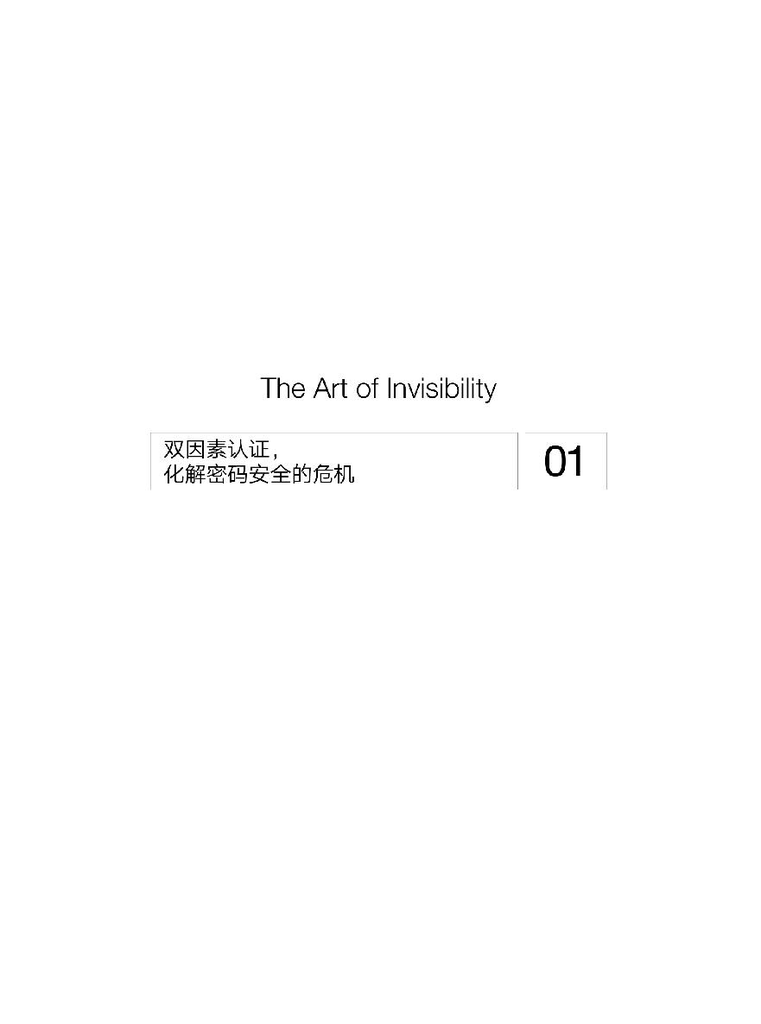

詹妮弗·劳伦斯（Jennifer Lawrence）度过了一个艰难的周末。2014年的一个早上，这位奥斯卡金像奖得主与其他一些名人醒来后发现，他们最私密的照片正在互联网上掀起轩然大波，其中很多是裸体照片。

现在，花点时间回想一下当前保存在你的计算机、手机和电子邮件里的照片。当然，其中很多都是完全无害的。就算全世界都看到你那些日落照片、可爱的家庭快照和头发乱糟糟的滑稽自拍，对你来说也无关紧要。但你愿意分享你所有的照片吗？如果这些照片突然全都出现在网上，你会怎么想？所有照片都记录了我们的私密瞬间。我们应该能够决定是否、何时以及怎样分享它们，而云服务并不一定总是我们的最佳选择。

2014年那个漫长的周末，媒体上充斥着詹妮弗·劳伦斯的故事。这是被称为“theFappening”的巨大泄露事件的一部分。在这一事件中，蕾哈娜（Robyn Rihanna Fenty）、凯特·阿普顿（Kate Upton）、凯莉·库柯（Kaley Cuoco）、阿德里安妮·库瑞（Adrianne Curry）及其他近300位名人的私密照片被泄露。这些名人中大多是女性，她们的手机照片通过某种方式被人获取并共享出来。可以预见，尽管有些人会对查阅这些照片感兴趣，但对更多人来说，这是一个让人不安的警示，因为这样的事情也可能会发生在他们身上。

那些人究竟是如何获得了詹妮弗·劳伦斯等人的私密照片呢？

这些名人都使用iPhone手机，人们最早的猜测集中于一次大规模数据泄露，这次泄露影响到了苹果公司的iCloud服务，而iCloud是iPhone用户的一个云存储选择。当你的物理设备存储空间不足时，你的照片、新文件、音乐和游戏都会被储存到苹果的服务器上，而且通常只需要少量月费。谷歌也为安卓系统提供了类似的服务。

几乎从来不在媒体上评论安全问题的苹果公司否认这是他们的错误。苹果公司发表了一份声明，称该事件是一次“对用户名、密码和安全问题非常有针对性的攻击”，该声明还补充说“在我们调查过的案例中，没有一项是由苹果系统（包括iCloud和‘查找我的iPhone’）的任何漏洞导致的”。

这些照片最早出现在一个以发布被泄露照片而出名的黑客论坛上。在那个论坛上，你可以看到用户在活跃地讨论用于暗中获取这些照片的数字取证工具。研究者、调查者和执法人员会使用这些工具从联网设备或云端获取数据，这通常发生在一场犯罪之后。当然，这些工具也有其他用途。

手机密码破解软件（Elcomsoft Phone Password Breaker，简称EPPB）是该论坛中被公开讨论的工具之一，该工具的目的是让执法机构和某些其他机构可以进入iPhone用户的iCloud账号。而现在，该软件正在公开销售。这只是论坛中的众多工具之一，似乎也是最受欢迎的一个。EPPB需要用户首先拥有目标iCloud账号的用户名和密码信息。但对使用这个论坛的人来说，获取iCloud用户名和密码并不是什么难事。在2014年的那个周末就发生了这种事，某人在一家流行的在线代码托管库（Github）上发布了一个名叫iBrute的工具——这是一种专为获取iCloud凭证而设计的密码破解系统，几乎可以用在任何人身上。

同时使用iBrute和EPPB，就可以冒充受害者本人将其所有云存储的iPhone数据全部备份下载到另一台设备上。这种功能是有用处的，比如当你升级你的手机时。但这个功能对攻击者也很有价值，他们可以借此查看你在你的移动设备上做过的一切。这会比仅仅登录受害者的iCloud账号提供更多的信息。

取证顾问和安全研究者乔纳森·扎德尔斯基（Jonathan Zdziarski）告诉《连线》杂志，他对凯特·阿普顿等人泄露的照片进行了检查，结果与使用了iBrute和EPPB的情况一致。取得用于恢复iPhone的备份能给攻击者提供大量个人信息，这些信息之后可能会被用于敲诈勒索。<sup>1</sup>

2016年10月，36岁的宾夕法尼亚州兰开斯特人瑞安·柯林斯（Ryan Collins）因“未经授权访问受保护的计算机获取信息”被判处18个月监禁。他被控非法访问超过100个苹果和谷歌电子邮件账号。

### 你必须设置一个强密码

为了保护你的iCloud和其他网络账号，你必须设置一个强密码（strong password）。然而，以我作为渗透测试员（靠入侵计算机网络和寻找漏洞赚钱的人）的经验，我发现很多人在设置密码方面都表现得很懒惰，甚至大公司的高管也是这样。比如索尼娱乐（Sony Entertainment）的CEO迈克尔·林顿（Michael Lynton）就使用“sonyml3”作为自己的域账号密码。难怪他的电子邮件遭到黑客攻击并被传播到了互联网上，因为攻击者已经获得了访问该公司内部几乎所有数据的管理员权限。

除了与你工作相关的密码之外，还要注意那些保护你最私人的账号的密码。即使选择一个难以猜测的密码，也无法阻挡oclHashcat（一种利用图形处理器即GPU进行高速破解的密码破解工具）这样的黑客工具破解你的密码，但这会让破解过程变得很慢，足以使攻击者转向更容易的目标。

我们可以大致猜到，2015年7月阿什利·麦迪逊（Ashley Madison）被黑事件曝光的密码中有一些（包括银行账号甚至办公电脑密码）肯定也被用在了其他地方。在网上贴出的1 100万个阿什利·麦迪逊密码的列表中，最常见的是“123456”“12345”“password”“DEFAULT”“123456789”“qwe rty”“12345678”“abc123”“1234567”。如果你在这里看到了自己的密码，那么你就很可能遭遇数据泄露，因为这些常见密码都被包含在了网上大多数可用的密码破解工具包中。你可以随时在www.haveibeenpwned.com网站上查看你的账号过去是否暴露过。

在21世纪，我们可以做得更好。我的意思是要好得多，这要用到更长和更复杂的字母与数字搭配。这可能听起来很难，但我会向你展示能做到这一点的一种自动方法和一种手动方法。

最简单的方法是放弃自己创造密码，直接自动化这个过程。市面上已经有一些数字密码管理器了。它们不仅可以将你的密码保存在一个加锁的保险箱中，还允许你在需要它们的时候一键访问，甚至可以在你需要时为每个网站生成一个新的、安全性非常强的独特密码。

但要注意，这种方法存在两个问题。一是密码管理器需要使用一个主密码进行访问。如果某人刚好用某种恶意软件侵入了你的计算机，而这个恶意软件可以通过键盘记录器（keylogging，一种能记录你的每一次按键的恶意软件）窃取你的密码数据库和你的主密码，那你就完蛋了。然后那个人就会获得你的所有密码。在参与渗透测试期间，我有时候会使用一个修改过的版本来替代密码管理器（当该密码管理器开源时），该版本会将主密码发送给我们。在我们获得客户网络的管理员权限之后，这个工作就完成了。然后我们就可以使用所有的专用密码了。换句话说，我们可以使用密码管理器作为后门，获取进入王国的钥匙。

另一个问题相当明显：如果丢失了主密码，你就丢失了你所有的密码。最终来看，这并无大碍，因为你可以随时在每个网站上进行密码重置，但如果你有很多账号，操作起来就会非常麻烦。

尽管有这些问题，但下面的小窍门应该也足以保证你的密码安全。

首先，你应该使用很长的强密码短语（strong passphrase）——至少有20个或至少有25个字符，而不是简单的密码。随机字符效果最好，比如ek5iogh#skf&skd。不幸的是，人类的大脑难以记忆随机序列。所以就使用密码管理器吧，使用密码管理器比自己选择密码要好得多。我倾向于使用开源的密码管理器，比如Password Safe和KeePass，它们只会将数据储存在你的本地计算机上。

另一个重要的规则是，永远不要为两个不同的账号使用相同的密码。如今，基本上做任何事都需要密码，所以就让密码管理器来帮你生成和保存独一无二的强密码吧。

即使你有强密码，仍然有技术可以打败你，比如John the Ripper这样的密码猜测程序。这款任何人都可以下载的免费开源程序可以根据用户配置的参数进行工作<sup>2</sup>。比如，用户可以指定尝试多少个字符、是否使用特殊符号、是否包括外语集合等。John the Ripper和其他密码破解器可以使用规则集来排列密码字符，从而非常有效地破解密码。简而言之，它会尝试参数设定之内的所有可能的数字、字母和符号组合，直到成功破解你的密码。幸运的是，大多数人都不用对抗拥有近乎无限时间和资源的国家机关。我们更有可能要对抗配偶、亲戚或某个我们真正惹恼了的人，而在面对一个有25个字符的密码时，他们不会有时间和资源来成功破解。

### 用隐晦的方式把密码写下来

假设你想按传统的方式创建密码，并且你选择了一些非常强的密码。你猜怎么着？你完全可以把它们写下来，只要别写成“美国银行：4the1sttimein4ever*”就行。这实在太明显了。你可以用某种隐晦的方式来表示你的银行名称等信息，比如使用“饼干罐”（因为有些人曾经把他们的钱藏在饼干罐里面），然后再加上“4the1st”。注意，我没有写完这个短语。你也不需要写完。你知道这个短语的其余部分，但其他人可能不知道。

将这个不完整密码的列表打印出来应该足以迷惑任何找到这个列表的人，至少一开始会迷惑他们。说个趣事：有一次我在一个朋友家，他是一位非常知名的微软公司的员工。吃晚餐时，我们与他的妻子和孩子讨论了密码的安全性。我朋友的妻子起身走向了电冰箱。她把自己所有的密码都写在了一张纸上，并且用磁铁将其贴到了电冰箱门上。我的朋友只是摇了摇头，我咧嘴一笑。把密码写下来可能不是一种完美的方案，但忘掉那些不常用的强密码也不好。

### 密码字符最好超过25位

银行等机构的网站会在几次（通常是3次）密码输入错误之后锁定用户。但仍然有很多网站不会这样做。不过，就算一个网站在3次尝试失败之后会锁定用户，也无法阻挡那些坏人，因为这并不是他们使用John the Ripper或oclHashcat的方式。（顺便说一下，oclHashcat会将入侵过程分布到多个GPU上进行，这比John the Ripper要强大得多。）而且在一个真实的网站上，黑客实际上并不会尝试每一个可能的密码。

假设已经出现了一起数据泄露事件，在其数据转储中包含用户名和密码。但从这次数据泄露中检索到的密码基本上都是毫无意义的。

这将如何帮助其他人入侵你的账号呢？

无论是解锁你的笔记本电脑还是登录一个在线服务，不管什么时候你输入了密码，这个密码都会通过一个被称为哈希函数（hash function）的单向算法传递。这不同于加密。加密是双向的：只要你有密钥，就可以加密和解密。而哈希是一种表示特定字符串的指纹。理论上而言，单向算法无法逆向进行，至少不容易进行。

存储在你的传统个人电脑（PC）、移动设备或云账号的密码数据库中的内容并非“MaryHadALittleLamb123$”这种形式，而是哈希值，这是一种由数字和字母构成的序列。这个序列是一个表示密码的令牌。

实际上，存储在我们的计算机里受保护的存储器中的正是这种密码哈希，而非密码本身；目标系统遭到破坏时攻击者获得的数据，或数据泄露发生时被泄露的数据也是密码哈希。一旦攻击者获得了这些密码哈希，就可以使用John the Ripper或oclHashcat等各种各样公开可用的工具来破解这些哈希并获得真正的密码，方法既有暴力破解（尝试每一个可能的字母数字组合），也有尝试一个词列表（比如一个词典）中的每个词。John the Ripper或oclHashcat让攻击者可以基于多个规则集修改要尝试的词，比如名叫leetspeak的规则集是一个用数字替代字母的系统，如“k3v1n m17n1ck”。这个规则会将所有密码变成各种leetspeak排列。使用这些方法破解密码比简单的暴力破解要高效得多。最简单和最常见的密码也是最容易被破解的，然后随着时间推移，更复杂的密码也会被破解。破解所需的时间长短取决于多种因素。如果同时使用密码破解工具以及你泄露的用户名和哈希密码，攻击者也许可以通过尝试与你的电子邮箱地址或其他身份标识相连接的其他网站的密码，来获取你的一个或多个账号的权限。

一般而言，你的密码字符越多，John the Ripper等密码猜测程序运行所有可能的变体所需的时间就越长。随着计算机处理器的速度越来越快，计算所有可能的6位甚至8位字符密码的时间也变得越来越短。这就是我建议使用25位或更多字符作为密码的原因。

### 密码、图案、指纹，哪个才能保护好你的移动设备

创造出强密码后，其中很多是你永远不会告诉别人的。这似乎是显而易见的事情，但在伦敦和其他主要城市进行的一些调查表明：人们会用密码来换取笔或巧克力这些微不足道的东西。

我有一个朋友曾经把自己的奈飞（Netflix）密码分享给了他的女朋友。那时候这么做是有理由的。让女朋友选择一部两人一起观看的电影会令她很高兴。但在奈飞电影推荐部分还留着“因为你看过……”而推荐的电影，其中就包括他和前女友们看过的那些。比如他自己就不会订阅电影《牛仔裤的夏天》（*The Sisterhood of the Traveling Pants*），而他的女朋友知道这一点。

当然，每个人都有前任。你可能会怀疑你是否在和一个没有前任的人谈恋爱。但每个女朋友都不愿意看到那些在她之前已经离开的人留下的证据。

如果你用密码保护着你的网络服务，那么你也应该用它来保护你的各种设备。大多数人都有笔记本电脑，而且许多人仍然拥有台式机。现在你可能一个人在家，但一会儿晚餐时会不会来客人呢？为什么要冒险让别人只需坐在你的桌子前动动鼠标，就可以访问你的文件、照片和游戏呢？再补充一个关于奈飞的警示故事：在奈飞主要租赁DVD的时代，我知道有一对夫妇被恶搞了。在家里的一次聚会上，他们登录了奈飞账号的浏览器一直开着。后来，这对夫妇通过邮件收到了各种各样粗制滥造的B级片和C级片，才发现这些电影已被添加到了他们的队列中。

在办公室里保护你的密码甚至更加重要。想象一下你被临时叫去开会的情况。可能会有人走到你的办公桌前，来看看下一季度预算的表格，或者你收件箱里的所有电子邮件。除非你有一个设置了密码保护的屏保，并且让它在几秒钟没有操作之后就自动开启，否则还可能出现更加糟糕的情况——不管什么时候，你离开桌子一大段时间（外出午餐或长时间开会），某人都有可能坐在你的桌子前，冒充你写了一封邮件发出去，甚至篡改了你下一季度的预算。

为了防止这种事发生，有一些具有创造性的新方法可用，比如使用蓝牙的锁屏软件可以验证你是否在电脑旁边。换句话说，如果你去洗手间时，你的手机离开了蓝牙的连接范围，你的电脑就会立即锁定。使用其他蓝牙设备也能做到这一点，比如手环或智能手表。

创建密码来保护网络账号和服务当然很好，但如果有人取得了你的物理设备，密码也就无济于事了，尤其是当你的网络账号处于开启状态时。所以如果你只能用密码保护一套设备，那就应该保护你的移动设备，因为这些设备是最容易丢失或被盗窃的。然而，美国《消费者报告》（*Consumer Reports*）发现，34%的美国人根本没使用任何安全措施来保护他们的移动设备，比如使用简单的4位数字PIN码<sup>(4)</sup>来锁定屏幕。

2014年，加利福尼亚州马丁内斯的一名警察承认自己从一个酒驾嫌疑人的手机里窃取了私密照片，这显然违反了美国宪法《第四修正案》。<sup>3</sup>具体来说，《第四修正案》禁止在没有法官签发的许可和可靠证据支持的情况下进行不合理的搜查和扣押。比如，执法人员如果想要访问你的手机，就必须先说明理由。

如果你还没用密码保护你的移动设备，现在就花点时间把它设置好。我是认真的。

不管是安卓、iOS还是其他什么系统，锁定手机的常用方法有三种。最常见的是锁屏密码，这是一串可以按特定顺序输入而解锁手机的数字。不要使用手机推荐的数字位数，应该在你的设置里面手动配置更强的密码——可以是你想要的7位数字（就像童年时的电话号码），必须使用4位以上的数字。

一些移动设备允许选择基于文本的锁屏密码，再次强调：选择至少7个字符。现代移动设备可以在同一屏幕上同时显示数字和字母键，让两者之间的切换简单了许多。

另一个锁屏选项是图案锁。2008年以来，安卓手机配备了一个被称为安卓锁定图案（ALP）的功能。屏幕上显示9个点，你可以以任何想要的顺序来连接它们；这个连接序列就是你的密码。你或许认为这个功能非常巧妙，而且可能的组合方式非常多，可以让你的序列无法被破解。但在2015年的PasswordsCon大会上，研究者报告称，在一项调查中，参与者在锁定图案的140 704种可能的图案组合中仅选择了少数几种可能的图案——这就是人类的本性啊。而这些可预测的图案又是怎样的呢？往往是用户名字的第一个字母。这项调查还发现，人们往往会使用中间的点，而不是边角的4个点。下次你设置锁定图案的时候，一定要好好考虑一下。

最后，还有生物识别锁。苹果、三星等手机制造商现在允许消费者选择使用指纹扫描器来解锁手机。请注意，这并非万无一失的。在Touch ID发布之后，研究者以为苹果改进了已经上市销售的大量指纹扫描器，结果他们非常惊讶地发现，一些攻破指纹扫描器的老方法对iPhone仍然有效，其中包括在干净的表面上使用婴儿爽身粉和透明胶带来获取指纹。

还有其他手机可以使用内置摄像头来对主人进行人脸识别。然而，在摄像头前面放一张主人的高分辨率照片，这种方法就会被破解。

一般而言，生物特征识别方法本身很容易受到攻击。理想情况下，生物特征应该仅被用作一种认证因素。先滑动你的指尖或对着摄像头微笑，然后输入PIN码或锁屏密码。这应该能保证你的移动设备的安全。

### 如何设置安全问题

如果你创建了一个强密码但没有把它写下来，又该如何是好？当你完全无法访问一个不常用的账号时，密码重置能帮上大忙。但对潜在的攻击者而言，这也可能是容易攻破的薄弱点。使用我们留在互联网上各种社交媒体个人资料中的线索，黑客可以简单地通过重置密码来获取我们的电子邮箱以及其他服务的权限。

新闻里曾报道过这样一次攻击。这次攻击涉及获取目标信用卡号的最后4位数字，然后将其用作身份证明，并要求服务提供商修改授权的电子邮箱地址。通过这种方式，攻击者可以在账号的合法所有者不知情的情况下重置密码。

2008年时，田纳西大学的学生大卫·科纳尔（David Kernell）决定试试看能否拿下副总统候选人萨拉·佩林（Sarah Palin）的个人雅虎电子邮箱账号。<sup>4</sup>科纳尔本来可以猜几个密码，但试错几次之后可能会让该账号锁定登录。于是他使用了密码重置功能，后来他形容这个过程“很轻松”。<sup>5</sup>

我敢肯定，我们都收到过来自朋友和亲戚的奇怪电子邮件，里面竟然包含外国色情网站的链接，之后我们才知道，原来朋友的电子邮箱账号被人盗用了。这些电子邮箱被盗用的原因往往是保护该账号的密码不够强。要么是某人已经知道了密码（通过数据泄露），要么是攻击者使用了密码重置功能。

当我们开始建立一个电子邮箱或银行账户等账号时，可能要回答一些安全问题。这样的问题通常有3个，还会有一个列出建议问题的下拉菜单，这样你就可以选择你想回答的问题。你的选择通常很明显。

你的出生地是哪里？你在哪里上的高中？在哪里上的大学？还有人们偏爱的“你母亲的娘家姓”，显然，至少从1882年以来<sup>(5)</sup>，它就一直被用作一个安全问题。<sup>6</sup>正如我将在下面讨论的那样，很多公司可以，而且确实在扫描互联网并收集个人信息，使得回答这些基本安全问题易如反掌。一个人在互联网上花几分钟时间，就很可能回答出一个给定个人的所有安全问题。

直到最近，这些安全问题才有了一定程度的改进。比如，“你的连襟出生于哪个州”就相当不同，但正确回答这些“好”问题本身就可能带有风险，下面我会谈到这一点。许多所谓的安全问题仍然太过简单，比如“你父亲的家乡是哪里”。

一般而言，设置这些安全问题时，应该尽量避免下拉菜单中提供的最明显的建议。即使该网站只包含基本的安全问题，也要有创意一点。没人要求你只提供简单干脆的答案。你可以耍点小聪明。比如，对你的流媒体视频服务而言，也许你最喜欢的颜色是什锦水果缤纷色。谁能猜到这个答案？这是个颜色，对吧？不管你用作答案的内容是什么，它都是这个安全问题的“正确”答案。

每次当你提供了创意答案时，一定要把问题和答案都写下来，放在安全的地方（或者就用一个密码管理器来保存你的问题和答案）。之后你可能会有需要技术支持的时候，这时，一位客服代表会问你一个安全问题。准备一张便利贴或在你的钱包里放一张卡片（或记住并始终使用一组相同的问答）来帮助你记忆“你的出生地是哪里”的正确答案是“在一家医院里”。之后，如果有人在网上搜索你的信息并尝试“俄亥俄州哥伦布市”这种更合理的答案，那么这种简单的概念混淆会让他束手无策。

诚实地回答非常特定的安全问题还存在额外的隐私风险：除了网上已有的那么多个人信息外，你还在贡献更多个人信息。比如说，“你的连襟出生于哪个州”的真实答案可能会被你提供答案的网站卖掉，然后这些信息可能会和其他信息结合起来，或用于填补缺失的信息。比如，根据这个关于连襟的答案，人们可以推断出你结了婚或结过婚，并且你的配偶或前任有男性兄弟，或者有姐妹与一个男性结婚，而这个男性就出生在你答案里的那个州。从一个简单的答案就能得到这么多额外信息。另一方面，如果你没有连襟，那就创造性地回答这个问题吧，答案也许是“波多黎各”。这应该会迷惑任何想要创建你的个人资料的人。提供的不相关信息越多，你在网上的隐身效果就越好。

回答这些相对不常见的问题时，你始终要考虑这些网站对于你的价值有多大。比如说，你也许信任你的银行，允许它们拥有这些额外的个人信息，却并不信任你的流媒体视频服务。另外，还要考虑这个网站的隐私政策是什么样的：其中可能有说明或暗示网站会向第三方销售其收集到的信息的内容，找到它们。

重置萨拉·佩林的雅虎电子邮箱账号密码需要她的出生日期、邮政编码和安全问题“你在哪里认识了你的丈夫”的答案。佩林的出生日期和邮政编码可以很容易地在网上找到（那时候佩林是阿拉斯加州的州长）。那个安全问题需要多花一点功夫，但科纳尔还是能够找到答案。佩林在很多采访中都提到丈夫是她的高中同学。事实证明，这正是她的安全问题的正确答案：高中校名。

科纳尔猜到了佩林的安全问题的答案，从而能够重置她的雅虎邮箱密码，进而控制这个邮箱。这让他能看到她所有私人的电子邮件。她的收件箱的一张截图被贴到了一个黑客网站上。除非佩林重置密码，否则她将无法登录自己的电子邮箱。

科纳尔的所作所为违法了，违反了美国《计算机欺诈和滥用法》（*Computer Fraud and Abuse Act*）。具体来说，他被认定犯了两项罪：通过销毁记录预先妨碍司法公正，这是一项重罪；未经授权访问计算机，这是一项轻罪。他于2010年被判处一年零一天的监禁，外加三年的监外看管。

如果你的电子邮箱账号像佩林的一样被人接管了，你应该这么做：

• 首先，你需要使用密码重置选项修改你的密码（是的，你也猜得到该这么做）。新密码要像我前面建议的那样使用强密码。

• 其次，检查发件箱，看看有什么东西以你的名义发出去了。你可能会看到有一条垃圾信息被发送给了很多人，甚至是你所有的联系人。现在你知道为什么这些年来你的朋友总在给你发送垃圾邮件了吧，因为有人劫持了他们的电子邮箱账号。

### 双因素认证，截至目前最安全的解决方案

密码和PIN码是安全解决方案的一部分，但我们刚刚也看到了，这些可以被猜出来。比复杂密码更好的方法是双因素认证（two-factor authentication）。事实上，詹妮弗·劳伦斯等名人的私密照片出现在互联网上之后，苹果的应对措施就是为iCloud服务启用了双因素认证，即2FA。

什么是2FA？

当尝试认证一位用户的身份时，网站或应用要查证3个东西中的至少2个。通常这些东西是指你拥有的东西、你知道的东西和你是谁。“你拥有的东西”可以是磁条式或芯片式的信用卡、借记卡；“你知道的东西”往往是PIN码或安全问题的答案；而“你是谁”包含了生物特征识别——指纹扫描、面部识别、声音识别等。这些东西越多，越能够确定你就是你自称的那个用户。

这听起来像是新技术，其实并不是。40多年来，大多数人都一直在使用2FA，只是我们没有意识到罢了。

每当你使用ATM时，你就在使用2FA。这怎么可能？你有一张银行签发的卡（你拥有的东西）和一个PIN码（你知道的东西）。当你将它们放到一起时，街上的无人ATM就知道你想进入这张卡所认证的账号。在一些国家，ATM认证还有其他方法，比如面部识别和掌纹识别。这被称为多因素认证（multifactor authentication，简称MFA）。

在网上也能实现类似的认证方法。很多金融、医疗机构、商业电子邮箱和社交媒体账号都允许用户选择2FA。在这种情况下，你知道的东西是你的密码，你拥有的东西是你的手机。使用你的手机获取这些网站的权限被认为是“带外”<sup>(6)</sup>的，因为这部手机没有连接到你正在使用的计算机。但如果你启动了2FA，而攻击者手里没有你的移动设备，他就无法访问你用2FA保护的账号。

假如说你在使用Gmail。要启用2FA，你会被要求在Gmail网站上输入你的手机号码。为了验证你的身份，谷歌会给你的手机发送一条包含6位数字代码的短信。然后，在Gmail网站上输入这个代码，你就确认了这台计算机和那个手机号码是关联的。

之后，如果有人试图用一台新的计算机或其他设备修改你的账号密码，就会有一条短信发送到你的手机上。只有在该网站上输入了正确的验证码之后，才能保存对你的账号的任何更改。

但这也并非万无一失。据赛门铁克（Symantec，著名网络安全技术公司）的研究者称，就算你使用了短信来验证身份，如果你不够小心，某个恰好知晓你电话号码的人也可以通过一些社会工程<sup>(7)</sup>盗取你的2FA保护的密码重置代码。

假设我想盗用你的电子邮箱账号，却不知道你的密码。但我知道你的手机号码，因为我可以通过谷歌轻松找到。在这种情况下，我可以进入你的电子邮箱密码重置页面，然后请求重置密码，因为你启动了2FA，你的手机就会收到一条短信验证码。到目前为止都还没什么问题，对吧？别急。

政治活动家德雷·麦克森（DeRay Mckesson）使用的一部手机就遭到过攻击，这一事件表明了坏人是如何欺骗你的移动运营商更换SIM卡的。换句话说，攻击者可以劫持你的蜂窝通信服务，然后接收你的短信——比如这条来自谷歌的、用来重置麦克森的Gmail账号的短信验证码，尽管他的账号使用了2FA进行保护。比起读出某人带有新密码的短信来愚弄他，这种情况发生的可能性要高得多。当然，让别人读短信也是可能的，这涉及社会工程。

因为我无法看到你的电子邮箱提供商发送到你手机上的验证码，所以我需要假装是其他人，然后把验证码骗过来。比如，在你收到了谷歌发送的真短信的几秒钟后，作为攻击者的我可以发送一条一次性短信，说：“谷歌检测到您的账号存在异常活动。请回复发送到您的移动设备上的代码，以阻止未经授权的活动。”

你会看到这个，是的，你确实收到了一条来自谷歌的、包含合法验证码的短信，但如果你不够谨慎，你可能就会把包含那个验证码的信息回复给我。我有不到60秒的时间来输入这个验证码。现在，我已经有了密码重置页面上需要填写的一切，然后就可以修改你的密码，取得你的电子邮箱账号或其他任何账号的权限。

因为短信代码未被加密，所以我可以通过刚才描述的方式来获得它。你也可以使用一种更加安全的2FA方法，即从Google Play或iTunes应用商店（为了在iPhone上使用）下载谷歌身份验证器（Google Authenticator）。这个应用可以在你每次访问需要2FA的网站时生成一个独特的授权码——所以不会发送短信。生成的6位数字码与网站用于授权访问的认知机制是同步的。但是，谷歌身份验证器会把你的一次性密码种子存储在Apple Keychain中，并且设置为“仅限该设备”。这意味着，当你为了升级或更换丢失的手机而将你的iPhone备份并还原到另一台设备上时，你的谷歌身份验证器代码将无法用于新设备，而重新设置它们是很麻烦的。为了应对可能更换物理设备的情况，你应该记得打印一些紧急代码。现在，有些应用允许你备份、还原你的一次性密码种子，可以为你免除这样的麻烦，你可以试试看。

一旦你注册了一台设备，就可以使用该设备继续登录该网站，多长时间都行，甚至将你的笔记本电脑或手机带到另一个地方也无妨；除非你特别勾选了信任该计算机30天的选项（如果有的话），那样你就会被提示输入新的访问代码。然而，如果你使用另一台设备——比如借用了你配偶的计算机，你就会被要求提供更多认证。无须多言，如果你使用了2FA，那就时刻把手机带在身边吧。

### 给每个人的建议

考虑到有这么多预防措施，你可能想知道，我会给那些在网上做各种金融交易的人提供些什么建议。

每年大约只需100美元，在你控制下的多达3台计算机就会得到反病毒和防火墙保护。在网上冲浪时，你会遇到的麻烦可能是你的浏览器加载了一个带有恶意软件的横幅广告，或者你打开了一封带有恶意软件的电子邮件。只要你的计算机常常联网，就有可能以这样或那样的方式受到感染，而你的反病毒产品可能无法应对网上存在的一切。

所以我推荐你花大概200美元，给自己买一台Chromebook。我喜欢iPad，但它太贵了。Chromebook的易用性接近iPad，而且价格低得多。

我要表达的观点是，你需要一台专门用于金融方面的次要设备，甚至医疗方面也是如此。除非你首先用一个Gmail账号注册过，否则它不会安装任何应用——这将限制你打开浏览器上网。

然后，如果你还没有这么做，那就在网站上激活2FA，让它识别你的Chromebook。一旦你做完了你在金融或医疗方面的事情，就将Chromebook放到一边，在下次你必须核对收支簿或预约一位医生时再重新拿起来使用。

这似乎很麻烦，实际上也确实如此。过去人们也可以方便地做银行业务，但现在几乎随时都能做银行业务。这样的话，其实你不太可能遇到你的银行信息和信用卡信息被人搞乱的情况了。如果你仅在Chromebook上使用你安装的两三个应用，也收藏了银行或医疗网站，并且不会访问其他网站，那么你的设备中基本不可能有木马或其他一些形式的恶意软件。

因此，我们已经明确了你需要创建强密码并且不能将它们分享出去。你需要尽可能地启用2FA。在后面几章中，我将带你了解常见的日常交互会如何到处留下数字印迹，以及你可以做些什么来保护自己的隐私。

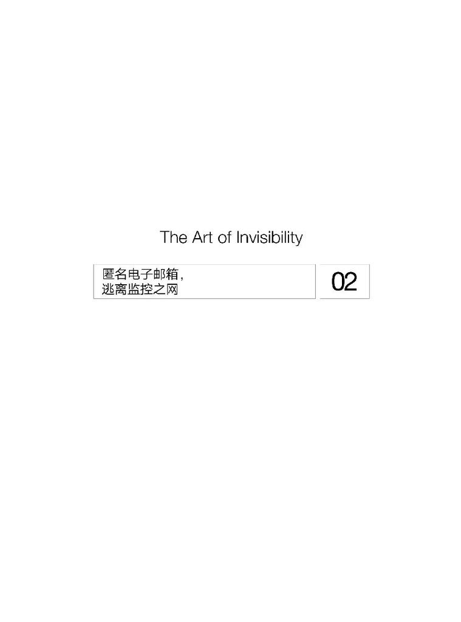

如果你和我一样，那么你早上一起来就要查看电子邮件。而且如果你真的和我一样，那么你也想知道还有谁在读你的电子邮件。这可不是什么妄想症。如果你使用的是Gmail或Outlook 365这样的基于网页的电子邮件服务，那么答案显然会很可怕。

即使你在计算机或手机上阅读完电子邮件后将其删除，那也不一定会真正删除其内容。某个地方还会有它的副本。网页电子邮箱是基于云的，所以为了能在任何时间从任何地方的任何设备访问它，它必须保存冗余的副本。比如，如果你使用Gmail，通过你的Gmail邮箱发送和接收的每一封电子邮件的副本都会被保存在谷歌位于世界各地的多个服务器上。如果你使用的是雅虎、苹果、AT&T、Comcast、微软，甚至你工作的地方提供的电子邮箱，情况也是一样。你发送的任何电子邮件都可以被托管公司随时检查。它们会说这是为了过滤恶意软件，但事实上，第三方也可以出于其他目的访问我们的电子邮件，而这些目的更加险恶，并且是为它们自己服务的。

原则上，大部分人都不愿意让其他任何人阅读自己的邮件，除了我们期望的收件人外。现在有法律保护通过美国邮政服务递送的纸质邮件，也有法律保护电子邮件这种存储的内容。但在实际操作中，我们通常知道，而且可能也接受了为电子邮箱提供的通信便捷性而牺牲一些东西。我们知道雅虎（还有其他公司）提供了免费的网页电子邮件服务，也知道雅虎的大部分收入来自广告。也许我们没有意识到这两件事可能存在关联，以及这会给我们的隐私带来怎样的影响。

有一天，加利福尼亚州北部的居民斯图尔特·戴蒙德（Stuart Diamond）意识到了这一点。他发现自己在雅虎邮箱客户端右上角看到的广告并不是随机的，而是基于他过去发送和接收的电子邮件的内容。比如说，我在一封电子邮件中提到了即将去迪拜做演讲，那么我可能会在我的电子邮箱中看到推荐航空公司、酒店和我在阿拉伯联合酋长国可以做的事情的广告。

这种做法可能在服务条款中有详细的说明，但大多数人可能读都没读就同意了。没人愿意看到和自己毫不相关的广告，对吧？而且只要电子邮件的收发方都是雅虎账号的持有者，那么似乎该公司就有合理的理由扫描这些电子邮件的内容，以便给我们提供定向广告并屏蔽恶意软件和垃圾邮件。

但是，戴蒙德和同样来自加利福尼亚州北部的戴维·萨顿（David Sutton）开始注意到，发送到和接收自非雅虎邮箱的电子邮件内容也会影响呈现给他们的广告。这说明该公司会截取和阅读用户所有的电子邮件，而不只是发送到或接收自雅虎自己服务器的那些。

基于他们观察到的模式，两人在2012年代表2.75亿账号持有人发起了针对雅虎的集体诉讼，并引证说明该公司的行为本质上就相当于非法窃听。

这终结了这种偷窥行为吗？并没有。

在一次集体诉讼中，诉辩双方都有一段取证和回应的时间。案件的初始阶段持续了3年时间。到2015年6月，加利福尼亚州圣何塞的一位法官裁定，这两个男人有充分的理由推进他们的集体诉讼，而且他们提出最初的要求后，自2011年10月2日起发送或接收过雅虎邮件的人都可以根据《存储通信法案》（*Stored Communications Act*）加入这一诉讼。另外，居住在加利福尼亚州的一些非雅虎邮箱账号持有人也可以根据该州的《侵犯隐私法案》（*Invasion of Privacy Act*）进行起诉。这个案件仍然悬而未决。

2014年年初，又有人对谷歌发起了一项关于电子邮件扫描的诉讼。在一次听证会上，谷歌不小心公开了关于其电子邮件扫描流程的信息，然后还试图快速撤回或移除这些信息，但是失败了。这个案件涉及的问题是，谷歌究竟扫描或阅读了哪些信息。该案件的原告是几家大型媒体公司，包括《今日美国》（*USA Today*）的所有者。据这些原告称，谷歌在某种程度上认识到，如果只扫描收件箱的内容，就会错失大量有潜在价值的内容。该诉讼声称谷歌不再只是扫描在谷歌服务器上存档的电子邮件，而变成了扫描所有仍在传输中的Gmail，不论它发送自某个iPhone还是坐在星巴克里的用户的某台笔记本电脑。

有时候，这些公司还会出于自己的目的而秘密地扫描电子邮件。众所周知，微软就发生过这种事。微软曾因为怀疑某位Hotmail用户盗版了该公司软件的副本而对该用户的邮箱进行了扫描，事情披露之后引起了人们的强烈抵制。微软表示，未来将让执法部门处理这样的调查。

这些行为不只局限于你的个人电子邮箱。如果你通过自己的工作网络发送电子邮件，你公司的IT部门可能也会扫描和存档你的通信记录。IT员工或他们的管理者会决定是否让任何被标记的电子邮件通过服务器和网络，以及是否向执法部门报案。这包括含有商业机密或可疑材料（比如色情内容）的电子邮件，也包括扫描电子邮件检测到的恶意软件。如果你的IT同事在扫描和存档你的电子邮件，他们应该在你每次登录的时候提醒你他们的政策是什么，但大多数公司并不会这样做。

尽管大多数人可能会容忍为了检测恶意软件而扫描我们的电子邮件，也许有一些人还能忍受以广告为目的的扫描，但让第三方读取我们对特定邮件中特定内容的反应和行为则是完全让人不安的。

所以每当你写完一封电子邮件，不管多么无关紧要，甚至就算你从邮箱里删除了该邮件，也要记住这些文字和图像的副本很有可能会被扫描并继续存在——也许不是永远存在，但会持续相当长的一段时间。（一些公司可能有短时间的保存政策，但我们可以有把握地假设，大多数公司都会将电子邮件保存很长时间。）

现在你知道某些机构和企业都在阅读你的电子邮件了，至少你可以让他们做这种事的难度更大。

### 给你的邮件上锁

大多数基于网页的电子邮件服务在传输邮件时都会使用加密。但是，一些服务在邮件传输代理（Mail Transfer Agent，简称MTA）之间传输邮件时可能不会使用加密，因此你的信息就是公开的。比如说，在办公场所，老板也许有公司电子邮件系统的权限。为了隐身，你需要加密你的信息，也就是说要给你的邮件上锁，仅让收件人可以解锁和阅读它们。加密是什么？它是一种代码。

恺撒密码（Caesay Cipher）就是一种非常简单的加密方法，它是指将密码中的每个字母替换成字母表中相距一定距离的字母。举个例子，当使用恺撒密码时，如果这个距离是2，那么a就变成了c，c变成了e，z变成了b，以此类推。使用这种偏移2位的加密方案，“Kevin Mitnick”就会变成“Mgxkp Okvpkem”。

当然，大多数今天所使用的加密系统都比任何恺撒加密强大得多，因此要破解它们也就更加困难。所有形式的加密都有一个共同点：需要密钥，这可以用来锁定和开启加密信息。如果使用同样的密钥来加锁和解锁加密信息，那就是一种对称加密（symmetrical encryption）。但是，当双方彼此不认识或相距很远时，对称密钥就难以在他们之间共享。

大多数电子邮件加密实际上使用的是所谓的非对称加密（asymmetrical encryption）。这意味着我要生成两个密钥：一个保存在我的设备上并且永远不会被共享出去的私钥（private key）和一个我可以在互联网上随意张贴的公钥（public key）。这两个密钥是不同的，但在数学上是相关的。

举个例子，鲍勃想给艾丽斯发送一封安全的电子邮件。他在互联网上发现了艾丽斯的公钥或直接从艾丽斯那里得到了它，然后在向她发送信息时使用她的密钥对信息进行了加密。当且仅当艾丽斯使用一段密码短语解锁了她的私钥，然后再解锁这条加密信息之前，信息一直处于加密状态。

那么究竟应该如何加密你的电子邮件内容呢？

最流行的电子邮件加密方法是PGP（Pretty Good Privacy），这个简写表示“相当好的隐私”。PGP不是免费的，而是赛门铁克公司的一款产品。其创造者菲尔·齐默尔曼（Phil Zimmermann）还编写了一个开源的版本——OpenPGP，这是免费的。第三个选择是GPG（GNU Privacy Guard），它是由维尔纳·科赫（Werner Koch）创造的，也是免费的。好在这三者是可以兼容的，这就意味着不管你使用的是哪个PGP版本，基本的功能都一样。

当爱德华·斯诺登决定开始披露他从NSA拷贝的敏感数据时，他需要分散在世界各地的志同道合的人的帮助。矛盾的地方在于，他既需要脱离搜索网，又需要一直活跃在互联网上。而他需要隐身。

即使你不用分享国家机密，你也可能有兴趣让你的电子邮件保密。斯诺登等人的经历说明：做到这一点虽然并不容易，但只要做出适当的努力，也是有可能实现的。

斯诺登使用了一家名叫Lavabit的公司提供的私人账号来与他人通信。但电子邮件不是点对点的（point-to-point），也就是说一封电子邮件在到达目标收件人的收件箱之前，可能会经过世界各地的好几台服务器。斯诺登知道，不管他写下什么，都可能会被这一路上在任何位置拦截这封电子邮件的任何人读到。

所以，他必须进行一套复杂的操作，以建立一个真正安全的、匿名的且完全加密的通信方式，以便与隐私倡导者和电影制作人劳拉·珀特阿斯（Laura Poitras）通信，她当时刚刚完成了一部关于揭秘者的生活的纪录片。斯诺登想要与珀特阿斯建立加密通信，但只有很少的人知道她的公钥。她没有完全公开她的公钥。

为了找到她的公钥，斯诺登必须接触一个第三方——支持网络隐私的组织“电子前线基金会”（Electronic Frontier Foundation，简称EFF）的迈卡·李（Micah Lee）。迈卡的公钥可以在网上找到，而且根据发表在网络杂志*Intercept*上的这个账号提供的信息，迈卡也有珀特阿斯的公钥，但他首先需要确认珀特阿斯是否允许自己分享它。她同意了。

那个时候，迈卡和珀特阿斯都还完全不清楚想要她的公钥的人是谁；他们只知道有人确实想要。斯诺登并没有使用他的个人电子邮箱账号，而是用了另一个账号来进行接触。但如果你不常使用PGP，可能会时不时忘记将自己的PGP密钥添加到重要邮件里，斯诺登就出了这种状况。他忘记将自己的公钥放进邮件里，这样迈卡就没法回复了。

迈卡没有任何安全的方式可以联系到这位神秘人，所以他别无选择，只能给斯诺登回了一封纯文本的未加密的电子邮件，询问他的公钥。斯诺登提供了自己的公钥。

迈卡，这个值得信赖的第三方不得不再一次面对这种情形。根据我的个人经历，我可以告诉你，一定要验证正与你进行秘密通信的人的身份，这是非常重要的，而且最好是通过一位共同的朋友——还要确保你确实在和那位朋友通信，而不是其他某个人伪装的。

我知道这件事的重要性，因为我之前就这样伪装过。当对方并不质疑我的真实身份或我发送的公钥时，就会出现被我利用的情况。有一次，我想和利兹大学的有机化学研究生尼尔·克利夫特（Neill Clift）通信，他是一个非常擅长在DEC公司（Digital Equipment Corporation）的VMS操作系统中寻找安全漏洞的人。我想让克利夫特向我发送他报告给DEC的所有安全漏洞。为此，我需要让他相信，我实际上是为DEC工作的。

首先，我伪装成一个名叫戴夫·哈金斯（Dave Hutchins）的人，并且用这个名字给克利夫特发送了一条具有欺骗性的信息。我之前假装成VMS工程开发部门的德里尔·派珀（Derrell Piper）给克利夫特打过电话，所以伪装成哈金斯的我在电子邮件里写道，派珀想与克利夫特就一个项目进行电子邮件通信。在检查DEC的电子邮件系统时，我知道克利夫特和真正的派珀曾经互相发送过电子邮件，所以这个新请求听起来不会那么奇怪。然后我又伪造了派珀的真实邮箱地址，并发送了一封电子邮件。

为了进一步说服克利夫特这全都是正当的行为，我甚至建议他使用PGP加密，这样像凯文·米特尼克（我的名字）这种人就无法读到这些电子邮件了。很快，克利夫特和“派珀”就交换了公钥并且加密了通信——但伪装成派珀的我可以阅读这些通信。克利夫特错在没有质疑派珀的身份。同样，当你的银行主动打电话来，要求你提供社会保障号码或账户信息时，你就应该挂断电话，然后自己打给银行，因为你永远不知道电话或电子邮件的另一边是什么人。

### 如果双方都是完全匿名的，他们如何知道谁是谁

考虑到斯诺登和珀特阿斯将要分享的机密的重要性，他们不能使用平常用的电子邮箱地址。为什么呢？因为个人电子邮箱账号包含能够鉴定出用户身份的特定关联线索，比如特定的兴趣、联系人列表。于是斯诺登和珀特阿斯决定创建新的电子邮箱地址。

唯一的问题是：他们如何知晓对方的新电子邮箱地址？换句话说，如果双方都是完全匿名的，他们如何知道谁是谁以及可以信任谁？比如说，斯诺登要怎样排除NSA或其他人伪装成珀特阿斯创建新电子邮箱地址的可能性？公钥很长，所以你无法拿起一部安全电话，然后把这些字符读给其他人听。你需要一次安全的电子邮箱通信。

再借迈卡·李之手，斯诺登和珀特阿斯可以在设置他们的新匿名电子邮箱地址时将信任托付给他人。珀特阿斯首先向迈卡分享了她的新公钥。但PGP加密密钥本身是相当长的（当然没有π那么长，但还是很长），而且同样需要注意，若是有人也在监视迈卡的电子邮箱账号呢？所以迈卡并没有使用真正的密钥，而是将珀特阿斯的公钥缩写到40个字符的长度（也被称为指纹，fingerprint）。然后，他将这段字符贴到了一家公开的网站——Twitter上。

有时候，为了隐身，你必须使用公开可见的东西。

现在，斯诺登可以匿名地浏览迈卡的推文，并且将缩短后的密钥与他收到的信息进行比较。如果两者不匹配，斯诺登就知道不能信任这封电子邮件。这条消息可能已经受损。或者他可能正在和NSA交谈。

在这个案例中，两者匹配上了。

现在，网上关于他们是谁以及身在世界何处的一些信息被移除了，斯诺登和珀特阿斯基本上就可以开始他们的安全匿名电子邮件通信了。斯诺登最后给珀特阿斯发送了一封仅称呼自己为“Citizenfour”（第四公民）的加密电子邮件。后来，珀特阿斯用这个签名命名了她导演的关于斯诺登的隐私权运动的纪录片，并且获得了奥斯卡金像奖。

看起来似乎一切都结束了，现在他们可以通过加密电子邮件安全地通信了。但事实并非如此，好戏才刚刚开始。

### 端到端加密

实际上，某些机构无须看到你加密的电子邮件内容，就能知道你在和谁通信以及频率如何。下面我们就会看到它们是如何办到的。

正如前面提到的那样，加密的目的是编码你的信息，这样的话只有拥有正确密钥的人才能解码它。加密的数学运算强度和密钥长度共同决定了没有密钥的人破解你的代码的难度。

今天所用的加密算法都是公开的。这也是你需要的。你应该担心那些专有的和不公开的加密算法。公开算法一直在经受弱点检查，也就是说，人们一直目的明确地想要攻破它们。每当一种公开的算法变弱或被攻破时，它就退休了，新的、更强的算法将取而代之。这些旧算法依然存在，但我强烈不推荐使用它们。

密钥（或多或少）在你的控制之下，所以你可能也猜到了，对它们的管理是非常重要的。如果你生成了一个加密密钥，那么除了你，没有其他任何人会将这个密钥存储在你的设备中。如果你让一家公司执行这种加密，比如在云端加密，那么该公司也可能在将密钥分享给你之后继续保留该密钥。真正让人担忧的是，可能会有法院命令强制该公司将该密钥分享给执法部门或某些机构——不管有没有搜查令。你需要阅读为加密使用的每种服务的隐私政策，并且了解这些密钥的所有者是谁。

加密一条消息（电子邮件、短信或电话）时，你要使用端到端（end-to-end）加密。这意味着你的消息在到达目标接收方之前一直都是无法读取的。使用端到端加密，只有你和你的接收方具有解码该消息的密钥。你的电信运营商、网站所有者或应用开发者都没有——执法部门或某些机构会要求它们转交关于你的信息。如何知道你使用的加密服务是不是端到端加密呢？用谷歌搜索一下“端到端加密语音电话”吧。如果这个应用或服务没使用端到端加密，那就选择另一个。

如果说所有这些听起来很复杂，那是因为它们确实很复杂。Chrome和火狐浏览器都有PGP插件，可以让加密变得更轻松简单。Mailvelope就是其中之一，它能够干净利落地处理PGP的公开和私有加密密钥。只需简单输入密码短语，就可以使用它来生成公钥和私钥。然后每当你在网页上写电子邮件时，选择了收件人后，如果该收件人有一个公钥可用，你就可以选择向那个人发送一条加密的消息。<sup>1</sup>

即使用PGP加密了你的电子邮件内容，但邮件中仍有一小部分内容可以被几乎任何人读到；而且这部分虽然小，但信息丰富。在斯诺登揭秘之后，美国政府在自我辩护时反复声明他们没有获取我们电子邮件的实际内容，而且在使用了PGP加密的情况下也无法读到这些内容。相反，美国政府说他们只收集电子邮件的元数据。

电子邮件元数据是什么？它是发件人和收件人字段中的信息，以及在发件人和收件人之间处理电子邮件的各个服务器的IP地址。另外，它也包含主题行，有时候这能非常清晰地揭示信息中加密的内容。元数据是互联网早期沿袭下来的遗产，仍然包含在人们发送和接收的每一封电子邮件中，但现代电子邮件阅读器却把这些信息隐藏起来，不予显示。<sup>2</sup>

不管你使用哪种“风味”的PGP，都不会加密元数据——收件人和发件人字段、主题行和时间戳信息。不管你能否看见，这些数据都被保存为纯文本格式。第三方仍然可以看到你的加密消息的元数据；它们会知道你在某个时间给某个人发送了一封电子邮件，而且两天之后你又向同一个人发送了一封电子邮件，等等。

听上去也许并无大碍，因为第三方并没有真正读到内容，而且你大概也不在意递送这些电子邮件的部件——各种服务器地址和时间戳。然而，光是从电子邮件的传递路径和频率得到的信息就能多到让你惊讶。

回到20世纪90年代，在逃避FBI的追捕之前，我在各种手机记录上执行过我所谓的元数据分析。首先，我黑入了洛杉矶一家名叫PacTel Cellular的蜂窝通信提供商，以获取某个所谓线人的呼叫详细记录（call detail record，简称CDR），FBI当时正用这个人来收集关于我的活动信息。

CDR和我在这里讨论的元数据非常像，它们给出了通话发生的时间、被呼叫的号码、通话时长及某个特定号码被呼叫的次数——全都是非常有用的信息。

通过搜索经过PacTel Cellular到达该线人的座机电话，我可以得到呼叫过他的人的手机号码清单。再分析一下这些人的账单记录，我可以识别出这些呼叫者就是FBI白领犯罪<sup>(8)</sup>小组的成员，他们听命于洛杉矶办事处。当然，有一些号码每个人都拨打过，它们是FBI洛杉矶办事处的内部号码、美国检察官办公室和其他政府办事处的号码。其中有些通话时间相当长，而且通话相当频繁。

每当他们将这个线人转移到一处新的安全屋时，我就可以获得这个安全屋的座机号码，因为特工们在尝试通过寻呼机接触该线人之后会呼叫这部座机。一旦我得到了该线人的座机号码，就可以通过社会工程取得他的真实地址，也就是说，通过假装成为这处安全屋提供服务的Pacific Bell公司的某个人的方式。

社会工程是通过操控、欺骗和影响某个人来使其遵从某个要求的黑客技术，通常用于骗取人们的敏感信息。在这个案例中，因为我已经从电话公司那里知道了其内部号码，所以我假装成一位现场服务技术人员，说着正确的术语和行话——这有助于取得敏感信息。

因此，尽管记录电子邮件的元数据不等同于获取实际内容，但从隐私的角度看也仍然是侵入性的。

### 人人都处在监控之下

检查一下近期任意一封电子邮件的元数据，你可以看到递送你的电子邮件的服务器的IP地址；这些服务器分布在世界各地，你的邮件要经过它们才会抵达目标。每台服务器就像每个接入互联网的人一样，都有一个独特的IP地址，这是根据你所在的国家和你的互联网提供商而计算出的一个数值。IP地址被分段分配给了各个国家，而且每家提供商都有自己的子段，这又会进一步划分出不同类型的服务——拨号上网、有线上网或移动上网。如果你购买了一个静态IP地址，它就会关联到你的订阅账号和家庭地址，否则你的外网IP地址会从分配给你的互联网服务提供商的地址池里生成。某个给你发电子邮件的人的IP地址可能是27.126.148.104，这个地址位于澳大利亚维多利亚州。

或者IP地址也可能是175.45.176.0，这是一个朝鲜的IP地址。如果真是如此，那么你的电子邮箱账号可能已经被标记并且要进行审查了。美国政府的工作人员可能想知道为什么你在和朝鲜的某个人通信，即使邮件主题行中写着“生日快乐”。

就服务器地址本身来说，你可能仍然认为它不太重要。但通信的频率能说明很多问题。此外，如果你能确定每个元素（发件人和收件人以及他们的位置），你就可以开始推测到底在发生什么。比如说，与电话呼叫相关的元数据（持续时间、通话时间等）能让你了解关于一个人心理健康的大量信息。一个晚上10点拨打家庭暴力热线的电话持续了10分钟，或者一个午夜从布鲁克林大桥打到自杀预防热线的电话持续了20分钟，这种情况就能揭示很多信息。达特茅斯学院开发了一个可以匹配用户数据中压力、抑郁和孤独模式的应用。这种用户活动也与学生成绩有关。

你仍然没看到暴露电子邮件元数据的危害吗？麻省理工学院开发的一个名叫Immersion的程序仅需使用元数据，就可以绘制出你邮箱中所有电子邮件的发件人和收件人之间的可视化关系图。这个工具可用于可视化地量化出谁对你最重要。程序甚至包含一个滑块式的时间标度，可以让你看到你认识的人对你的重要性随时间推移发生的起起伏伏。尽管你可能认为你了解自己的关系，但用图形化的方式表达出来也许会给你带来清醒的认识。你可能没意识到自己给不认识或了解不多的人发了如此多的电子邮件，却很少给你非常熟悉的人发邮件。使用Immersion工具，你可以选择是否上传数据，而且在图形绘制出来后，你也可以删除这些信息。<sup>3</sup>

据斯诺登说，NSA和其他机构正在收集人们的电子邮件、短信和电话的元数据。但它们没法收集每个人的元数据——或者也许可以？从技术角度来看，这办不到。但是自2001年以来，“合法”的收集行为一直在迅猛增长。

根据美国1978年的《外国情报监控法案》（*Foreign Intelligence Surveillance Act*，简称FISA），美国外国情报监控法庭（简称FISA法庭）负责监管针对美国境内外国人的所有监控授权的申请。表面上看，在执法机构和个人之间放一道法庭命令似乎很合理，但现实有些不一样。光是在2012年，该法庭就收到了1 856份申请，也批准了1 856份申请，这说明今天这个程序很大程度上已经成了帮美国政府盖橡皮章批准的过程。<sup>4</sup>在FISA法庭批准了一项申请后，执法机构可以强迫私营公司上交所有关于你的数据——更何况它们可能在被强迫之前就已经上交了。

### 你需要一个洋葱路由器

若想真正在数字世界里隐身，你不仅需要加密自己的信息，还需要：

• **移除自己真实的IP地址：**这是你与互联网的连接点，你的指纹。它能显示出你的位置（具体到你的实际地址）和你使用的提供商。

• **掩饰你的硬件和软件：**当你连接到一个在线网站时，该网站可能会收集你使用的硬件和软件的快照信息。它们可以使用一些技巧来确定你是否安装了特定的软件，比如AdobeFlash。你的浏览器软件会告诉网站你使用的是什么操作系统、你的操作系统是什么版本，而且有时候还能显示你的桌面上运行的其他软件。

• **保护你的匿名性：**在网络上确定归属是很困难的。要证明当一件事发生时你正在敲键盘也很困难。但是，如果你在上网之前经过了星巴克的一个摄像头，或者你刚刚在星巴克使用你的信用卡购买了一杯拿铁，这些行为就可以和你不久之后的上网行为联系在一起。

我们已经知道，每当你的设备连接到互联网时，都有一个与这次连接关联的IP地址。<sup>5</sup>如果你想在网上隐身，这就是个问题：你也许可以改变你的名字（或完全不给出名字），但你的IP地址仍然会揭示出你在世界的位置、你使用的提供商的名字以及为该互联网服务付费的人（可能是你，也可能不是你）的身份。所有这些信息都包含在电子邮件元数据中，可以用来确定你的独特身份。任何通信，不管是不是电子邮件，都可以基于其互联网协议（Internal Protocol，简称IP）地址来确定你的身份；当你在家里、办公室或朋友的地盘使用网络时，这个地址被分配给了你使用的路由器。

当然，电子邮件中的IP地址可以被伪造。有些人可能会使用代理地址——不是他的真实IP地址，而是其他人的地址。这样电子邮件看起来就像是来自另一个地方。代理就像一台外语翻译器，你对它说话，然后这台翻译器对另一个说外语的人说话，消息仍然保持不变。也就是说，某个在朝鲜发送电子邮件的人可能会使用中国甚至德国的代理来避开侦查。

除了托管你自己的代理，你也可以使用一种被称为匿名邮件转发器（anonymous remailer）的服务，它会掩盖你的电子邮件的IP地址。匿名邮件转发器提供保护的方式很简单，就是在将消息发送给目标收件人之前修改发件人的电子邮箱地址。收件人也可以通过这个转发服务回复。这是最简单的版本。

但也存在其他变体。一些一型和二型邮件转发器不允许你回复电子邮件；它们只是单向通信。三型（或称Mixminion）邮件转发器确实提供了一整套服务：回复、转发和加密。如果选择这种匿名通信方法，你需要了解你的邮件转发器会提供哪些服务。

掩盖你的IP地址的一种方法是使用洋葱路由器（Tor），这也是斯诺登和珀特阿斯的做法。

Tor开源程序是由美国海军研究实验室在2004年开发的，以便军事人员能在不暴露他们实际位置的前提下开展搜索。自那以后，Tor已经得到了扩展。Tor可以用于帮人们避开大众媒体和服务的审查，并防止任何人追踪他们使用的搜索词。Tor一直是免费的，任何地方的任何人都可以使用。

Tor是如何工作的？它将访问网站的一般模式颠倒了过来。

一般来说，你上网的时候，会打开一个互联网浏览器，然后输入你想访问的网站名称。该网站就会收到一个请求，几毫秒后会有一个带有其网站页面的响应传回你的浏览器。根据IP地址，这个网站可以知道你用的是哪家服务提供商，而且有时候还可以根据服务提供商的位置或从你的设备到该网站的跳<sup>(9)</sup>知晓你在世界的什么地方。比如，你的设备说它在美国，但你的请求到达目标之前所用的跳的时间和数量表明你在世界的其他地方，一些网站（尤其是赌博网站）会检测这种行为，以防备可能的欺诈。

使用Tor时，你和你的目标网站之间的直接线路会被其他额外的节点掩盖，而且每10秒钟，连接你和你访问的任何网站的节点链就会发生改变，但不会给你造成中断。连接你和网站的各种节点就像洋葱里面一层层的结构。换句话说，如果有人想从目标站点循迹追踪，试图找到你，路径的不断变化将让他们无能为力。通常你的连接可以被认为是匿名的，除非你的入口和出口节点不知为什么关联起来了。

当你使用Tor时，你打开mitnicksecurity.com页面的请求不会直接发送给目标服务器，而是会先发送给另一个Tor节点。而且为了让情况更加复杂，这个节点又会把该请求传递给另一个节点，最后再连接到mitnicksecurity.com。所以这个过程涉及一个入口节点、一个中间节点和一个出口节点。如果我要了解是谁访问了我公司的网站，我只能看到出口节点的IP地址和信息，这是这个链条的最后一个节点，而非第一个节点，即你的入口节点。你可以配置Tor，使其使用一个特定国家（比如西班牙）的出口节点，甚至可以指定一个在火奴鲁鲁的特定出口节点。

要使用Tor，你需要从Tor网站（torproject.org）下载修改过的火狐浏览器。请记得，始终要从Tor网站上寻找适合你操作系统的正规Tor浏览器，不要使用第三方的网站。对于安卓操作系统，Orbot是一款可以从Google Play获取的正规免费Tor应用，它既能加密你的流量，也能隐藏你的IP地址。在iOS设备（iPad、iPhone）上，你可以从iTunes应用商店安装正规的应用Onion Browser。

你可能会想，为什么不在Tor内部建立一个电子邮件服务呢？有人已经这样做过了。Tor Mail是托管在一个仅能通过Tor浏览器访问的网站上的服务。但是，FBI因为一个不相关的案子而没收了该服务器，因此获得了所有存储在Tor Mail中的加密电子邮件。这个警示性的故事表明，即使你认为你的信息是安全的、万无一失的，事实也可能并非如此。<sup>6</sup>

尽管Tor使用了一个特殊的网络，你仍然可以通过它访问互联网，但网页的加载速度会慢得多。然而，除了能让你浏览那些可以搜索到的网站，Tor还能让你访问很多通常搜索不到的网站。这些网站不能解析成Google.com这样常见的名称，而是在结尾冠以“.onion”的扩展名。有一些隐藏的网站在发布、销售或供应涉嫌违法的商品和服务。

应当说明一下，Tor也有一些弱点：

• 你无法控制出口节点，它们可能处于某些机构的控制之下。

• 你仍然可以被分析并被识别出来。

• Tor非常慢。

也就是说，如果你仍然决定使用Tor，就不应该在你用于浏览的同一物理设备上运行它。换句话说，用一台笔记本电脑来浏览网页，再用另一台设备（比如一台运行Tor软件的树莓派小型计算机）来配置Tor。这样做的话，就算有人攻陷了你的笔记本电脑，也无法攻破你的Tor传输层，因为它运行在另一台物理设备上。<sup>7</sup>

在斯诺登和珀特阿斯的案例中，正如我说的那样，只是通过加密电子邮件连接彼此还不够好。在珀特阿斯为她的匿名电子邮箱账号创建了一个新公钥之后，她本可以将其发送给斯诺登之前的电子邮箱地址，但如果有人正在监视那个账号，那么她的新身份就将暴露。这里有一个非常基本的原则：必须将你的匿名账号和任何与你真实身份相关的东西完全隔离。

### 如何创建匿名电子邮箱

若想隐身，你就需要为每个新的安全通道重新开始建立联系。已有的电子邮箱账号可能与你生活的其他部分（朋友、爱好、工作）有各种各样的联系。为了秘密地通信，你需要使用Tor来创建新的电子邮箱账号，这样，设置该账号的IP地址就不会以任何方式与你的真实身份关联到一起。

创建匿名电子邮箱地址难度很大，但也是可以办到的。

你可以使用私人电子邮件服务。因为你在为这些服务付费时会留下痕迹，所以实际上最好还是使用免费的网页服务。但也有一个小麻烦：Gmail、微软和雅虎等服务需要你提供一个电话号码来验证你的身份。显然你不能使用真实的手机号码，因为这可能会泄露你的真实姓名或真正地址。如果它支持语音认证而不是SMS认证，你就可以设置一个Skype手机号码，但你仍需要一个已有的电子邮箱账号和一张预付费的礼品卡来设置Skype号码。如果你认为使用预付费的手机本身就能保护你的匿名性，那可就错了。如果你曾经使用这个预付费电话进行过与你的真实身份有关的通话，那么发现你是谁简直是小菜一碟。

相反，你需要使用用后即抛的一次性手机。一些人认为只有坏人才会使用一次性手机，但一次性手机也有很多完全合法的正当用途。比如，曾经有一位商业记者丢的垃圾都会被惠普公司雇用的私家侦探检查翻找，因为这家公司急于知道是谁泄露了关键的董事会信息；于是这位记者转而使用一次性手机，让这些私家侦探更难识别她的电话。这段经历之后，她就只使用一次性手机与她的信息来源通话了。<sup>8</sup>

再比如，一个需要躲避有暴力倾向的前任的妇女选择使用无需合约的电话或谷歌、苹果账号，这样可能会让她更安心一点。一次性手机通常只有很少的、非常有限的互联网功能，基本上只提供语音、短信和电子邮箱服务，但一些人只需要这些就足够了。而你也应该用它获取数据，因为你可以将这部一次性手机连接到你的笔记本电脑上，然后使用它来上网。在后面的章节中，我会告诉你在笔记本电脑上修改媒体访问控制（media access control，简称MAC）地址的方式，这样每当你将一部一次性手机接入这台电脑时，它看起来都像是一台新设备。

但是匿名购买一次性手机会很困难。现实世界发生过的事情可以被用于识别虚拟世界中你的身份。当然，我可以走进沃尔玛，用现金购买一部一次性手机和100分钟的通话时间。谁会知道呢？事实上，很多人都知道。

首先，我是如何到达沃尔玛的？我搭了一辆优步（Uber）的车吗？还是坐的出租车？这些记录都可以被传讯取证。

虽然我也可以自己开车去，但执法部门在大型公共停车场使用了自动车牌识别技术（automated license plate recognition，简称ALPR）来寻找失踪和被盗的车辆以及仍有效的通缉令上的人。这些ALPR记录可以被传讯取证。

就算我步行去沃尔玛，一旦走进店里，我的脸也会被安全监控摄像头拍到。这些视频可以被传讯取证。

好吧，那假设我让另外一个人去店里买——一个我也不认识的人，可能是我当场雇的一个流浪者。那个人走进店里，然后用现金买下手机和一些数据充值卡。这是最安全的方法。也许你安排好了，你们会在远离这家店的地方碰头。这有助于拉开你和实际销售交易位置的物理距离。在这种情况下，你叫去买手机的人就成了其中最薄弱的环节——他值得信赖的程度如何是未知的。如果你给他的钱超过手机的价值，他可能才乐意按承诺的那样把手机交给你。

想激活预付费的手机，你要么需要拨打对应移动运营商客服部门的电话，要么需要在该运营商的网站上激活。为了避免因“资格认证”而被记录数据，通过网络激活更加保险。修改MAC地址后，在公开的无线网络上使用Tor应该能做到最低程度的保护。你应该编造你输入该网站的所有订阅者信息。对于地址，只需要用谷歌搜一家主流酒店的地址，然后使用它就行了。再编造一个生日和PIN码，但你要记住它们，以防以后出现需要联系客服的情况。

也有一些电子邮件服务不需要验证，而且如果你无须担心当权者，Skype号码就可以很好地用来注册谷歌账号等应用。但为了说清楚，让我们假设在使用Tor让你的IP地址变得随机之后，你创建了一个与你的真实电话号码毫无关联的Gmail账号，之后谷歌给你的电话发送了一条验证码或进行了一次语音呼叫。现在你就有了一个基本上无法被追踪的Gmail账号。

所以，我们已经使用我们熟悉和常见的服务建立了一个匿名电子邮箱地址。那么我们就可以发送足够安全的电子邮件了，它的IP地址在Tor的帮助下匿名了（尽管你无法控制出口节点），它的内容也在PGP的帮助下无法被收件人之外的人读取。

请注意，要保持这个账号的匿名性，只能使用Tor来访问这个账号，这样你的IP地址才永远不会与之发生关联。此外，在登录了这个匿名Gmail账号之后，一定不要执行任何互联网搜索，因为你可能会在无意中搜索与你的真实身份相关的事物。即使搜索天气信息，也可能暴露你的位置。<sup>9</sup>

如你所见，实现隐身和保持隐身需要严格的规行矩步和持续不断的持之以恒。但为了隐身，这都是值得的。

最重要的总结是：首先，始终要清楚，就算你执行了我前面描述的部分预防措施，只要不是全部，就有可能被人识别出你的身份。如果你确实执行了所有这些预防措施，还要记住，每次使用你的匿名账号时都要毫不遗漏地执行这些操作，不能有例外。

另外，值得重申一下，端到端加密是非常重要的，也就是说，要让你的消息在到达收件人之前一直都保持不可读取的安全状态，而不只是简单的加密。端到端加密也有其他用途，比如加密电话和即时消息，这是我们将在接下来两章里讨论的内容。

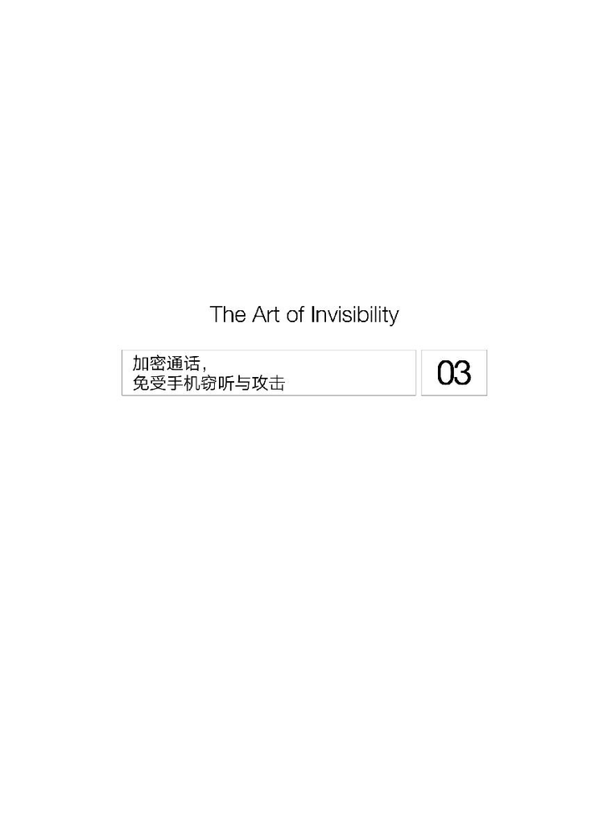

聊天、发短信、网上冲浪，你每天都会在手机上花费无数时间。但是，你真的知道你的手机是如何工作的吗？

### 手机本质上就是一个追踪设备

我们的移动设备使用的蜂窝服务是无线形式的，依赖于蜂窝塔，即基站。为了保持连接，手机会持续不断地向离自己最近的一座或多座蜂窝塔发送微小的信标信号。这些塔对于信标信号的应答会被翻译成你手机上“信号格”的数量：一格也没有就表示没信号。

为了以某种方式保护用户的身份，手机的信标使用了所谓的国际移动用户识别码（international mobile subscriber identity，简称IMSI），这是分配给SIM卡的一个独特数字。它最初诞生的时候，蜂窝网络还需要知道你什么时候连接到它们的塔上，什么时候在漫游（使用其他运营商的蜂窝塔）。IMSI码的第一部分指明了特定的移动网络运营商，其余部分则向该网络运营商标识了你的手机。

执法机构已经制造出可以伪装成蜂窝基站的设备。这些设备是为拦截语音和短信而设计的。

在美国，执法部门和情报机构也会使用其他设备来获取IMSI。IMSI可以被即时获取，一秒钟都用不了，而且也不会发出预警。通常人们会在大型集会上使用IMSI获取设备，这样可以让执法部门在后方识别出谁在现场，尤其是那些不断打电话叫其他人加入的人。

这样的设备也可应用于通勤服务和创建交通报告。在这种情况下，实际账号或IMSI并不重要，重要的是你的手机从一座塔到另一座塔或从一个地理区域到另一个地理区域的速度。手机接近和远离每一座塔所用的时间可用来确定交通状况：堵塞、缓行或畅通。<sup>1</sup>

只要你的移动设备开机，它就会连接到一些蜂窝塔。离你最近的塔会实际地处理你的电话、短信或互联网通话。当你移动时，你的手机会与最近的塔进行回环应答（ping），如果有必要，你的通话也会从一座塔转移到另一座塔，同时还能保持连贯性。附近的其他塔全都处于待命状态，这样当你从地点A移动到地点B并且进入了信号更好的另一座塔的区域时，信号就会平滑地切换，你应该也不会掉线。

可以这样说：你的移动设备发出一段特定的序列，这段序列会被多座单独的蜂窝塔记录下来。所以任何人只要查阅一座特定塔的日志，就可以看到在其全部区域内任意给定时间所有人的临时移动用户识别码（temporary mobile subscriber identity，简称TMSI），不管他们是否打过电话。执法部门可以，并且也确实会要求蜂窝运营商提供这些信息，包括特定持有人的后端账号身份。

一般来说，如果只查看一座信号塔的日志，其数据可能仅仅表明某个人正在经过，而且他的设备连接到了一座待命的特定信号塔。如果其间有通话或数据交换，那还会有关于那次通话和持续时间的记录。

然而，来自多座信号塔的日志可被用于精确定位一个用户的地理位置。大多数移动设备每次会与3座或更多的塔进行回环应答。使用来自这些信号塔的日志，某人可以基于这些回环应答的相对强度，通过三角定位来确定该手机用户的一个相对准确的位置。所以你每天带着到处走动的手机本质上就是一台追踪设备。

那么要如何避免被追踪呢？

一次性手机看上去是个不错的选择。如果你频繁更换（比如说每月甚至每周）预付费手机，也许就可以避免留下太多痕迹。你的TMSI会出现在一座信号塔的日志中，然后又会消失。如果你购买手机时也很谨慎，用户账号就不会被追踪到。预付费手机服务仍然有用户账号，所以也会有分配给它的IMSI。因此，一个人的匿名性取决于他获得一次性手机的方式。

为了便于论证，让我们假设你已经成功地与一部一次性手机的购买行为断绝了关系。你遵循了我在前面给出的步骤，让一个与你无关的人使用现金购买了这部手机。那么使用这种用后即抛的手机就不会被追踪了吗？简而言之，不行。这里就有一个警示故事：

2007年的一个下午，一个价值5亿美元的装满迷幻药的集装箱在澳大利亚墨尔本的一个港口丢失。臭名昭著的毒贩帕特·巴尔巴罗（Pat Barbaro）是这个集装箱的主人。他把手伸向自己的口袋，拿出自己12部手机中的一部，拨打了当地一位记者尼克·麦肯齐（Nick McKenzie）的号码。这位记者只知道打电话的人名叫斯坦（Stan）。巴尔巴罗随后会使用他的另一部一次性手机给麦肯齐发短信，试图匿名地从这位调查记者手里获得有关这个丢失的集装箱的信息。正如我们将会看到的那样，这种方法没用。

尽管很多人可能认为一次性手机是真正匿名的，但实际上并非如此。根据美国的《法律执行通信协助法案》（*Communications Assistance for Law Enforcement Act*，简称CALEA），与一次性手机连接的所有IMSI都要上报，就像那些主流运营商的合约用户一样。换句话说，执法人员可以根据日志文件找到特定的一次性手机，就像找到注册的合约手机一样简单。尽管无法通过IMSI确定谁拥有这部手机，但也许可以通过使用模式来确认。

澳大利亚没有CALEA，但执法人员仍然可以使用相当传统的方法密切监视巴尔巴罗的众多手机。比如，他们可能会注意到巴尔巴罗首先用自己的个人手机打了一个电话，几秒钟后又在同一个基站的同一日志文件中看到来自他的某部一次性手机的电话或短信。随着时间推移，这些IMSI在同一基站同时出现的频次会高于正常水平，这个事实可能就说明了它们属于同一个人。

巴尔巴罗有很多手机可以随便使用，但问题是，不管他使用哪部手机，不管是个人手机还是一次性手机，只要他待在同一个地方，信号就会到达同一座蜂窝塔。他的一次性手机总是出现在他注册的手机旁边。而这部注册手机已经在一家运营商那里关联了他的名字，完全可以被追踪，以帮助执法部门确定他的身份。这为针对他的案件提供了确凿的证据——尤其是这种模式也在其他地方重复出现，帮助澳大利亚当局成功认定巴尔巴罗组织策划了澳大利亚史上规模最大的迷幻药走私案并将其定罪。

麦肯齐总结说：“自从手机在我的口袋里振动、‘斯坦’短暂地进入我生活的那天，我就格外清楚人们的通信会如何留下痕迹，不管他们有多谨慎。”

当然，你可以只用一部一次性手机。这就意味着你时不时需要使用预付卡或比特币匿名购买额外的使用时间。你可以在修改了无线网卡的MAC地址后使用一个公开的Wi-Fi安全地做到这件事，并且要躲开任何摄像头的视野。或者你也可以像之前的章节建议的那样，雇一个陌生人去店里用现金购买预付费的手机和几张充值卡。<sup>2</sup>这会增加成本，也可能不方便，但你会得到一部匿名的手机。

### 如果你可以渗透进SS7，你就可以操纵通话

尽管蜂窝技术听起来可能很新潮，但它其实已经有超过40年的历史了，而且就像铜线电话系统一样，它传承着一些可能危害你的隐私的技术。

每一代手机技术都有新功能，主要目的是更高效地传输更多数据。20世纪80年代的第一代手机（1G）让人们用上了移动通信技术。这些早期的1G网络和手持设备都是基于模拟技术的，而且它们使用的是现在已经停用的各种移动标准。1991年，第二代（2G）数字网络推出。2G网络提供了两个标准：全球移动通信系统（GSM）和码分多址（CDMA）。它也推出了短消息服务（SMS）、非结构化补充数据业务（USSD）以及其他今天仍在使用的简单通信协议。目前我们正处于4G/LTE阶段，正在向5G迈进。

无论运营商采用了哪一代技术（2G、3G、4G或4G/LTE），其底层都有一个国际性的信号协议，被称为信令系统（signaling system）。这个信令系统协议（目前是第7版）及其他事物能帮助你在高速公路上驰骋，并且在从一座信号塔到切换到另一座信号塔时保持移动通话的顺畅连接。它也可被用于监视。7号信令系统（signaling system 7，简称SS7）基本上能够完成路由通话所必需的一切，比如：

• 为通话设置一个新连接；

• 当通话结束时中断连接；

• 正确地为通话计费；

• 管理呼叫转移、主叫方名称及号码显示、三方通话和其他智能网络（IN）服务等额外功能；

• 免费电话和长途电话；

• 无线服务，包括用户身份识别、运营商和移动漫游。

在德国柏林举办的年度计算机黑客大会——混沌通信大会（Chaos Communication Congress）上，Sternraute创始人托拜厄斯·恩格尔（Tobias Engel）和安全研究实验室（Security Research Labs）的首席科学家卡斯滕·诺尔（Karsten Nohl）在演讲中解释道，他们不仅可以定位世界上任何地方的呼叫者，还能窃听这些人的电话交谈。而且如果无法实时窃听，他们也可以将加密的电话和文本录下来，之后再解密。

在安全领域，你的安全程度取决于你最薄弱的环节。恩格尔和诺尔发现，尽管北美和欧洲的发达国家已经在开发相对安全和隐私的3G、4G网络上投入了数十亿美元，但它们仍然必须使用SS7作为底层协议。

SS7可以处理呼叫建立、计费、路由和信息交换功能的整个过程。这意味着如果你渗透进SS7，你就可以操纵通话。SS7允许攻击者利用尼日利亚这类国家的小型运营商获取欧洲或美国的电话呼叫。恩格尔说：“这就像是你锁好了房子的前门，后门却大敞四开。”

这两位研究者测试了一种方法，当攻击者使用电话的呼叫转移功能时，SS7会将目标对象拨出的电话转移给自己，之后再通过会议模式（三方通话）将接听者拉进来。一旦攻击者做好了安排，就可以窃听目标对象在世界任何地方拨出的所有电话。

攻击者可用的另一个策略是，设置无线电天线来收集一个给定区域内的所有蜂窝通话和短信。对于任何加密的3G通话，攻击者都可以要求SS7提供正确的解密密钥。

“这全都是自动化的，只需要按一个按钮，”诺尔说，“这种间谍能力很完美，让我震惊，它可以被用来记录和解密几乎任何网络……任何我们测试过的网络都有效。”然后他列举了北美和欧洲几乎每一家重要的运营商，总共20家左右。

诺尔和恩格尔还发现，他们可以使用一个名叫“任意时间询问查询”（anytime interrogation query）的SS7功能定位任何手机用户的位置。也就是说，在2015年年初该功能关闭之前，他们都可以做到这件事。但是，因为所有运营商为了提供服务都必须追踪它们的用户，所以SS7还提供了其他功能，仍然可以做到某种程度的远程监视。应该指出的是，诺尔和恩格尔的研究公开以后，由他们确定的特定漏洞基本上已经被运营商解决了。

### 加密也无法保证通话的私密性

你可能认为仅仅通过加密就能帮助保证手机通话的私密性。从2G开始，基于GSM的手机通话就已经加密了。然而，最初在2G中用来加密通话的方法很弱，最终也被破解了。不幸的是，将蜂窝网络升级到3G的成本让许多运营商望而却步，所以一种弱化的2G网络直到2010年前后都仍在被使用。

2010年夏天，诺尔领导的一个研究团队将2G GSM网络使用的所有可能的加密密钥本身进行了切分，然后对这些数字进行了处理，得到了一个所谓的彩虹表（rainbow table）——一种由预先算出的密钥或密码组成的表。他们发布了这个表，向全世界的运营商展示了使用GSM的2G加密究竟有多不安全。使用这个密钥表，仅需短短几分钟时间，每个经由2G GSM发送的语音、文本或数据的数据包（在来源和目标之间传输的数据的单元）都可被解密。这是一个极端案例，但该团队认为有必要展示出来。之前，诺尔等人将其发现交给运营商时，他们的警告被当成了耳边风。通过公开演示破解2G GSM加密的方式，他们或多或少地迫使这些运营商做出了改变。

要重点说明一下，现在仍然还存在2G，而且运营商正在考虑将它们古老的2G网络的使用权卖给物联网设备（计算机之外其他连接到互联网的设备，比如你的电视和电冰箱）使用，这些设备仅需要偶尔进行一下数据传输。如果这种情况发生，就需要确保这些设备本身有端到端加密，因为我们知道2G本身无法提供足够强的加密。

### 在移动设备普及之前，窃听就已经存在了

当然，在移动设备真正普及之前，窃听就已经存在了。安妮塔·布施（Anita Busch）的噩梦始于2002年6月20日的那个早上，邻居急促的敲门声惊醒了她。某个人在她的汽车风挡玻璃上留下了一个弹孔，当时她的车停在车道上。不仅如此，汽车的引擎盖上还留下了一朵玫瑰、一条死鱼和一张字条，上面写着一个词：“Stop”。<sup>3</sup>之后她知道自己的手机被窃听了，而且并不是执法部门干的。

事实上，这个有一个弹孔和一条死鱼的场景是为了让人想起一部糟糕的好莱坞黑帮电影，由此就能理解其背后要表达的意思了。布施是一位经验丰富的记者，她受《洛杉矶时报》的委托，刚刚开始几周的自由撰稿人工作，准备记录有组织犯罪在好莱坞日益增长的影响。当时她正在调查史蒂文·西格尔（Steven Seagal）和他的前商业合作伙伴朱利叶斯·R.纳索（Julius R. Nasso）——调查已经表明，纳索正与纽约黑手党密谋向西格尔敲诈钱财。

发现她车上的那张字条之后，布施又收到了一系列电话信息。打电话的人显然想告诉她一些关于西格尔的信息。再后来，布施了解到这个打电话的人受雇于安东尼·佩利卡诺（Anthony Pellicano），他曾经是洛杉矶的一个著名的私家侦探。在布施的车被人动了手脚之后，FBI就已经怀疑佩利卡诺有非法窃听、贿赂、身份盗用和妨碍司法公正的行为了。布施的有线电话已经被佩利卡诺窃听。通过窃听布施的电话，佩利卡诺知道她当时正在写一篇关于他的客户的新闻报道。放在她车子上的死鱼是想警告她，让她停手。

窃听通常不只与电话有关，美国与窃听相关的法律也覆盖了对电子邮件和即时消息的窃听。现在我的重点是有线电话的传统窃听。

有线电话是你家或公司里面用实际的线缆连接起来的电话，而窃听也真正涉及切入真实的线缆中<sup>(10)</sup>。那时候，每家电话公司都有某种实体的开关库，它们可以在此之上执行某种形式的窃听。也就是说，电话公司有一些特殊的装置，而其框架技术可以将这些装置连接到中央办公室中主机上的目标电话号码。另外，还存在一些呼叫这些装置的额外的窃听设备，可用于对目标进行监控。现在，这种监听方式已经退休了，电话公司全部被要求实施CALEA规定的技术要求。

尽管现在越来越多的人都转向了移动电话，但很多人仍然保留着有线电话，因为他们觉得这些铜线连接的电话很可靠。其他人也使用被称为基于网络协议传输的语音（Voice over Internet Protocol，简称VoIP）的技术，这是一种通过互联网打电话的技术，通常与你家里或办公室里的有线电视或互联网服务绑定在一起。无论是利用电话公司里的实体开关还是数字开关，执法部门都有能力窃听通话。

1994年的CALEA要求电信制造商和运营商修改它们的设备，以便执法部门能够窃听其线路。所以根据CALEA，理论上美国境内所有有线电话的通话都很容易被拦截，而且所有执法部门都需要Title III授权令<sup>(11)</sup>才能读取这些电话。也就是说，普通公民的窃听行为仍然是违法的，而安东尼·佩利卡诺为了窃视安妮塔·布施和其他人就做了这种事。被他窃听的受害者还包括西尔维斯特·史泰龙（Sylvester Stallone）、大卫·卡拉丁（David Carradine）和凯文·尼龙（Kevin Nealon）等好莱坞明星。

窃听受害者名单中也包括我的朋友埃琳·芬恩（Erin Finn），因为她的前男友对她还很痴迷，想要追踪她的一举一动。由于她的电话线路被窃听，我在打电话给她的时候也被窃听了。这个故事中最酷的部分是AT&T为了集体诉讼和解而给了我几千美元，因为佩利卡诺窃听了我打给芬恩的电话。这倒是有些讽刺意味，因为在另一个场合，我也在窃听别人。佩利卡诺窃听别人的目的可能比我更有恶意。他试图恐吓证人，使其以特定的方式不做证或做证。

在20世纪90年代中期，必须要由技术人员安装窃听装置。所以佩利卡诺或他的手下必须雇用某个在Pacific Bell工作的人来切入布施和芬恩的电话线。这些技术人员需要在佩利卡诺位于比弗利山庄的办公室搭建目标电话的扩展设施。在这种情况下，窃听并非通过电话接线盒（房屋或公寓楼一侧的终端）来完成，尽管这是可能的。<sup>4</sup>

如果你读过我之前的书《线上幽灵》（*Ghost in the Wires*），你可能会记得，我有一次从我父亲位于卡拉巴萨斯的公寓驱车前往长滩，要在我已故兄弟的一位朋友肯特的电话线上安装一个实体窃听器。我兄弟因为吸毒过量而死一事存在很多疑点，而且我当时相信肯特和这件事有关，尽管之后我了解到他和这件事无关。在肯特居住的公寓楼的杂物间里，我通过社会工程假装成一个电话线技术人员给GTE（通用电话电子公司）的一个特定部门打了一个电话，以便找到分配给肯特的电话的线缆位置，结果发现肯特的电话线穿过了一栋完全不同的公寓楼。然后，在另一个杂货间里，我终于将一个声控微型磁带式录音机夹在了接线盒（电话公司技术人员将电话线连接到各个公寓的地方）中他的电话线上。

之后，不管肯特什么时候打电话，我都可以在他毫无察觉的情况下记录双方的谈话——应该指出，虽然录音是实时的，但我听的时候却不是。在那之后的10天里，我每天都要开车1小时到肯特的公寓，听完取回的磁带，看有没有提到我的兄弟。不幸的是，里面没有什么相关的信息。多年以后我才知道，很可能是我的叔叔造成了我兄弟的死亡。

鉴于佩利卡诺和我都可以如此轻松地窃听私人的电话，你可能会疑惑，使用铜线连接的、显然要被窃听的有线电话时，怎样才能隐身？你不能隐身，除非购买专用设备。至于那些真正的偏执狂，可以选择一种能在铜线上加密你所有语音通话的有线电话。<sup>5</sup>这种电话确实能解决私人电话被窃听的问题，但必须要通话双方都使用加密才行；否则可能还是很容易被监控。对普通人来说，有一些关于电话的基础选择可以让我们避免被窃听。

### 数字电话让监视更简单

数字电话的发展没有让监控行为变得更难，反而使其更简单了。今天，如果要对一条数字电话线路进行监控，完全可以远程地实现。电话交换计算机只是简单地创建了另一个并行的数据流；不需要任何额外的监控设备。这也让人更加难以确定一条给定的线路是否遭到了窃听。而且在大多数案例中，这样的窃听都是偶然被发现的。

在希腊举办了2004年夏季奥运会之后不久，沃达丰（Vodafone）旗下的Vodafone-Panafon的工程师从公司的蜂窝网络中移除了一些流氓软件，这些软件被发现时已经在那里运行了一年多了。实际上，执法人员会截取经由任何蜂窝网络发送的全部语音和文本数据，为此他们会使用一种被称为RES（远程设备控制子系统）的远程控制系统，该系统是模拟信号窃听器的数字等效形式。当被监视的目标拨打电话时，RES会创建另一个数据流，并将其直接传送给执法人员。

在希腊发现的这些流氓软件进入了沃达丰的RES，也就意味着在正规执法部门之外，还有其他人一直在窃听经由其蜂窝网络进行的通话；在这个案例中，窃听者感兴趣的是政府官员。在这届奥运会期间，有的国家（比如美国和俄罗斯）为国家级的通话提供了它们自己的私密通信系统。来自全世界的其他国家首脑和企业高管，使用的则都是已经受损的沃达丰系统。

调查表明，希腊总理及其妻子的通信在奥运会期间受到了监控，雅典市长、希腊欧盟专员、国防部、外交部、商船部和司法部的通信也未能幸免。另外，反全球化组织、执政的新民主党、希腊海军总参谋部的成员、和平活动人士和美国驻雅典大使馆的一位希腊裔美国员工的电话也遭到了截听。<sup>6</sup>

若不是沃达丰在调查另一起不相关的投诉（短信传送失败的比例高于正常水平）时找来自己的RES系统供应商爱立信（Ericsson），这种间谍活动可能还会持续更长时间。在执行了问题诊断之后，爱立信告知沃达丰：发现了流氓软件。

不幸的是，十多年过去了，我们仍然不知道谁是幕后黑手或原因为何。我们甚至不知道这种活动有多普遍。而更糟的是，沃达丰显然没有妥善做好调查工作。一个表现就是，覆盖该事件的关键日志文件丢失了。而且沃达丰没有在发现这个流氓程序后让其继续运行（这是计算机犯罪调查中的普遍做法），反而唐突地将其移出了它们的系统，这会给作案者提供预警，让他们可以进一步掩盖自己的踪迹。

沃达丰事件是一个让人不安的警示，提醒着我们要拦截我们的手机是多么容易。但即使你用的是数字电话，也有可以实现隐身的方法。

### 端到端加密移动VoIP

除了手机和老式的有线电话，我在前面还提到了第三种电话选择——基于网络协议传输的语言即VoIP。VoIP适用于任何本身不带电话功能的无线设备（比如苹果的iPod Touch），比起传统的打电话，这更像是网上冲浪。有线电话需要铜线；移动电话使用信号塔；而VoIP通过互联网传输你的语音——不管使用有线还是无线的互联网服务。VoIP也适用于移动设备，如笔记本电脑和平板电脑，无论它们是否具有蜂窝服务。

为了省钱，很多家庭和办公室都已经切换到了VoIP系统，这些系统是由新服务提供商和已有的有线电视公司提供的。为各个家庭传输视频流和高速互联网的同轴电缆也可供VoIP使用。

好消息是VoIP确实会使用加密，尤其是一种被称为“会话描述协议安全描述”（session description protocol security descriptions，简称SDES）的加密方法。但也有坏消息，SDES并不是很安全。

SDES的部分问题在于其加密密钥不是通过安全的SSL/TLS（一种网络加密协议）分享的。但是，如果供应商不使用SSL/TLS，那密钥就是明文发送的。它使用了对称加密，而不是非对称加密，这就意味着由发送方生成的密钥必须以某种方式传递给接收方，才能为电话解码。

让我们假设鲍勃想给在外国的艾丽斯打电话。鲍勃用SDES加密的VoIP电话为这场通话生成了一个新的密钥。鲍勃必须以某种方式让艾丽斯也得到这个新密钥，这样她的VoIP设备才能解码他的电话呼叫，他们才能进行交谈。SDES提供的解决方案是，将该密钥发送给鲍勃的运营商，然后传递给艾丽斯的运营商，再分享给艾丽斯。

你看到哪里有问题了吧？还记得我在上一章谈到的端到端加密吗？接收方在另一端解密之前，通话一直保持加密状态。但SDES将来自鲍勃的密钥分享给了鲍勃的运营商，如果艾丽斯的运营商和他的不同，那么这场通话从艾丽斯的运营商到艾丽斯的阶段是加密的。中间的缺口大不大还存在争议。使用Skype和Google Voice的情况也与之类似。每当一个电话发起时，就会有新密钥生成，但这些密钥之后就传递给了微软和谷歌。多么想有一次私密的通话啊！

幸运的是，现在有一些可以端到端加密移动VoIP的方法。

来自Open Whisper Systems的Signal是一个免费的开源的手机VoIP系统，可为iPhone和安卓提供真正的端到端加密。

Signal的主要优势是其密钥管理仅在通话双方之间处理，不会通过任何第三方。也就是说，就像在SDES中一样，每次通话都会生成新的密钥，但这些密钥的唯一副本存储在用户的设备上。因为CALEA允许读取任何特定电话的记录，那么在这种情况下，执法部门只能看到这家移动运营商的线路上有加密的流量，而无法了解其内容。而且开发了Signal的非营利性组织Open Whisper Systems也没有这些密钥，所以授权令也无法使用。这些密钥仅存在于通话两端的设备上。而且一旦通话终止，这些会话的密钥就会被销毁。

CALEA目前还没有延展到终端用户或他们的设备上。

你可能认为在手机上使用加密会榨干你的电池。加密确实会耗电，但也不会消耗太多。Signal会推送通知，就像WhatsApp和Telegram这些应用一样。因此，只有来电呼入时，你才会看到这些通知，而当你接听新来电时，这些通知的耗电量就减少了。安卓和iOS应用也会使用移动网络必备的音频编解码器和缓冲算法，所以同样在你打电话时，加密本身并不会耗费太多电量。

除了使用端到端加密，Signal还使用了完全正向保密（perfect forward secrecy，简称PFS）。PFS是什么？这种系统为每一次通话都使用了稍有不同的加密密钥，所以就算真的有人拿到你加密的电话通话及用于解码该通话的密钥，你的其他通话仍然是安全的。所有PFS密钥都基于单个的原始密钥，重要的是，即使有人拿到了一个密钥，也并不意味着你的潜在敌人能够进一步读取你的通信。

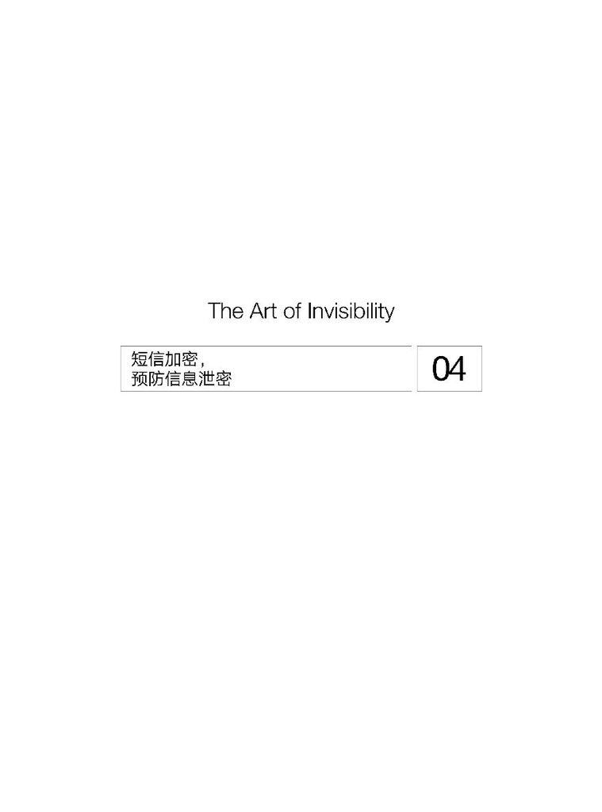

如果现在有人拿到了你未加密的手机，这个人就能获取你的电子邮箱、社交网络账号，甚至也许是亚马逊账号的权限。在移动设备上和在我们的笔记本电脑或台式机上一样，我们不再单独登录各种服务；我们有移动应用，而且一旦我们登录过，它们就一直是开放的。除了照片和音乐，你的手机上还有其他一些特有的内容，比如短信。如果某人拿到了你未加密的实体移动设备，这些也会被暴露。

想一想这件事：2009年，华盛顿州朗维尤市的丹尼尔·李（Daniel Lee）因涉嫌贩卖毒品而被逮捕。<sup>1</sup>当他被关押时，警方搜查了他的没有密码保护的手机，马上就发现了几条与毒品有关的短信。其中一组短信来自一个被称为Z-Jon的人。

短信写道：“我已经搞到了130，可以还我昨晚欠你的160。”根据法庭的证词，朗维尤市警方不仅读了Z-Jon给丹尼尔的信息，还主动回复，安排他们的毒品交易。警方假装成丹尼尔给Z-Jon回复了一条短信，问他是否“需要更多”。Z-Jon回复说：“是的，那真的很赞。”当Z-Jon——真名是乔纳森·罗登（Jonathan Roden）出来和“丹尼尔”碰面时，警方以试图持有海洛因的罪名逮捕了他。

警方还在丹尼尔的手机上注意到另一组短信，并在类似的情况下逮捕了肖恩·丹尼尔·欣顿（Shawn Daniel Hinton）。

在美国公民自由联盟（American Civil Liberties Union，简称ACLU）的帮助下，罗登和欣顿都在2014年向华盛顿州最高法院提起了上诉，要求推翻下级法院的判决。他们声称警方侵犯了被告的隐私预期（expectation of privacy）。

华盛顿州法官说，如果丹尼尔先看到了罗登和欣顿的短信或指示警方人员回复“这不是丹尼尔”，就会改变这两个案件的基础。史蒂文·冈萨雷斯（Steven Gonzalez）法官在欣顿的案例中写道：“短信可以包含与电话、密封的信件及其他传统通信形式相同的私密主题，这些传统通信形式历来受到华盛顿法律的大力保护。”

法官最后裁定，隐私预期应该从传统的纸质信件时代扩展到数字时代。在美国，执法部门在没有得到收信人许可的情况下不能打开密封的实体信函。隐私预期是一种司法测试<sup>(12)</sup>，用于确定美国宪法《第四修正案》声明的隐私保护是否适用。目前还不清楚法院将如何审判未来的案件，以及它们是否会考虑这个司法测试。

### 短信并不是直接传输的

短信技术（也称短消息服务，即SMS）自1992年以来就一直存在。所有手机都能发送简短的短信，甚至功能手机（非智能手机）也不例外。短信不一定是点对点的：换句话说，短信并非真正地从一部手机直接到达另一部手机。和电子邮件一样，你在手机上输入的消息会以未加密的明文形式发送到一个短消息服务中心（short message service center，简称SMSC），这是移动网络中用于存储、转发和递送短信的部分——有时候这个过程会长达几个小时。

原生的移动短信（那些从你的手机而非某个应用发出的短信）会通过运营商的一个SMSC，在这里，它们可能会被储存，也可能不会。运营商称它们只会把这些短信保留几天。那段时间过后，运营商坚称你的短信只保存在发送和接收它们的手机上，而储存短信的数量取决于手机型号。尽管它们对公众这样说，但我认为美国所有的移动运营商都会保存人们的短信。

这些运营商的说法存在一些疑点。爱德华·斯诺登披露的文件表明，NSA和至少一家运营商比如AT&T关系密切。据《连线》杂志报道，从2002年开始（“9·11”事件后不久），NSA就一直在与AT&T接触，要求它们开始在一些运营商的设施中设立秘密房间。<sup>2</sup>其中之一位于密苏里州布里奇顿市，还有一个在旧金山市中心的福尔松街。最后，其他城市也加入进来，包括西雅图、圣何塞、洛杉矶和圣迭戈。设立这些秘密房间的目的是引导所有互联网、电子邮件和手机流量通过一个特殊的过滤器，这个过滤器会搜查其中的关键词。目前还不清楚这种搜查是否包含短信，但看起来我们可以合理地认为它确实包含。另外，我们也不清楚斯诺登事件之后，AT&T或任何其他运营商是否仍然在做这种事。

有一项线索表明这种做法没有继续。

在2015年的美国橄榄球联合会（AFC）冠军赛中，为了争夺第49届超级碗参赛资格，新英格兰爱国者队以45︰7的成绩战胜了印第安纳波利斯小马队，同时也引发了争议。这次争议的核心是新英格兰爱国者队是否已经知道他们的橄榄球充气不足。美国职业橄榄球大联盟（NFL）对橄榄球的充气程度有严格的规定，而在那场季后赛之后，经认定，新英格兰爱国者队提供的球并不满足要求。这场调查的核心是爱国者队的明星四分卫汤姆·布雷迪（Tom Brady）发送的短信。

布雷迪公开否认参与此事。也许向调查人员展示他在比赛前或比赛过程中发送和接收的短信就能证实这一点。不过，在与关键调查人员会面那天，布雷迪突然更换了一部全新的手机，丢弃了原来那部从2014年11月用到2015年3月6日的手机。布雷迪后来告诉委员会，他已经销毁了原来的手机和上面所有的数据，包括之前保存的短信。为此，NFL给了布雷迪停赛4场的处罚，这个处罚后来又被法庭命令解除。<sup>3</sup>

“在使用这部手机的4个月时间里，布雷迪收发了近万条短信，现在从那台设备中一条也拿不到，”联盟表示，“在上诉听证会之后，布雷迪先生的代表提供了一封来自他的手机运营商的信件，证实这部已销毁的手机曾经发送或接收的短信无法再恢复。”

所以，如果布雷迪已经从运营商那里拿到说明，证明他的短信全被销毁了，运营商也表示不会保留它们，那么延长短信寿命的唯一方法就是在云上备份你的移动设备。如果你使用了你的运营商的某项服务，甚至是谷歌或苹果的服务，这些公司就有可能获取你的短信。显然，布雷迪在紧急升级手机之前没有时间备份旧手机中的内容。

国会还没有解决一般的数据保留问题，尤其是手机的数据保留问题。事实上，最近几年美国国会一直在争论是否要求所有移动运营商将短信存档2年时间。

### 关于第三方应用，你不知道的事

所以，该如何保证你的短信私密呢？不要使用经由你的无线运营商传输的原生的短信服务，而是使用一个第三方应用。但选哪个呢？

若想隐藏网络身份，匿名地享受互联网，我们需要信任一些软件和服务。这种信任很难验证。一般来说，开源和非营利性组织提供的可能就是最安全的软件和服务，因为有数千双眼睛检查过这些代码，标记了任何看起来可疑或容易遭受攻击的地方。使用专有软件时，你或多或少得听供应商的话。

软件评测究其根本也只能告诉你那么一点信息，如一个特定的接口功能是如何工作的。那些评测者只是花几天时间研究研究这个软件，然后写写他们的印象。他们并没有真正使用这个软件，也不会长期报告发生的情况，只是记录一下自己的初始印象。

此外，评测者也不会告诉你是否可以信任这个软件。他们不会对产品的安全和隐私方面进行审查。而且，产品有一个驰名品牌也并不意味着它就是安全的。实际上，我们应该对流行品牌保持警惕，因为那可能会诱使我们产生虚假的安全感。不能供应商说什么你就信什么。

20世纪90年代，当我需要加密我的Windows 95笔记本电脑时，我选择了诺顿公司一款现在已经停产的实用软件<sup>(13)</sup>产品——Norton Diskreet。彼得·诺顿（Peter Norton）是一个天才。他的第一个计算机实用软件可以自动恢复删掉的文件。20世纪80年代，诺顿继续创造了大量伟大的系统实用软件，那时候能够理解命令提示符的人还很少。但是之后，他将这家公司卖给了赛门铁克，其他人也开始以他的名义编写软件。

在我拿到Diskreet（一款已经不再供应的产品）的时候，DES56位加密（DES表示“数据加密标准”）还是很了不起的，那是你能想象到的最强大的加密方法。为了让你更加了解背景情况，现在我们使用的是AES 256位加密（AES表示“高级加密标准”）。加密每增加1位，加密密钥的数量就会发生一次指数级增长，因此也会更加安全。当时，DES 56位加密被看作是最安全的，直到1998年8月才遭到破解。<sup>4</sup>

无论如何，我都想看看Diskreet程序在隐藏我的数据方面是否足够稳健，也想让FBI在控制我的计算机时难以读取数据。在购买了这个程序之后，我黑入了赛门铁克并找到了该程序的源代码。<sup>5</sup>我分析了它的功能和原理后，发现Diskreet仅使用了56位密钥中的30位——其他位只是用“0”来填充。这甚至还没有允许出口到美国之外的40位技术安全。

这意味着比起Diskreet产品的广告宣传，某个人或组织（NSA、执法部门或拥有高速计算机的敌人）攻破这款产品的难度实际上要小得多，因为它根本就没有真正使用56位加密。但这家公司还是宣称这款产品有56位加密。我决定使用其他工具。

公众如何知道这种事？他们不会知道的。

### 运动中的数据

据Niche.com提供的数据，尽管社交网络是最受青少年欢迎的通信方式，但文本消息仍然占据着主导地位。一项研究发现，87%的青少年每天都发文本消息，相比之下，有61%的青少年说自己使用Facebook，这是第二流行的选择。根据这项研究，平均而言，女孩每个月大概发送3 952条文本消息，而男孩每个月大概发送2 815条。

好消息是今天所有流行的消息应用都在发送和接收文本时提供了某种形式的加密，也就是说，它们会保护所谓的“运动中的数据”（data in motion）。坏消息是它们并非全都使用了强加密。2014年，安全公司Praetorian的研究者保罗·豪雷吉（Paul Jauregui）发现，避开WhatsApp所使用的加密是可能的，这涉及一种中间人（MitM）攻击，攻击者可以截取受害者和他的收信人之间的消息，并且可以看到每一条消息。豪雷吉说：“NSA会喜欢这种东西的。”在写作本书时，WhatsApp所用的加密已经得到了更新，在iOS和安卓设备上都使用了端到端加密。而且WhatsApp的母公司Facebook也已经将加密带给了9亿Messenger用户——尽管这是需要选择才能使用的功能，也就是说你必须配置“私密对话”功能才能开启加密。

更糟糕的消息是存档数据即“静态数据”（data at rest）的遭遇。大多数移动消息应用并不加密存档的数据，不管这些数据是在你的设备上还是在第三方系统上。AIM<sup>(14)</sup>、Skype等应用在储存你的消息时都没有加密。这意味着这些服务提供商可以阅读其中的内容（如果存储在云中）并将其用于广告。这也意味着如果执法人员（或犯罪黑客）拿到了这些物理设备的权限，他们就可以读到这些消息。

另一个问题是我们之前提到过的数据存留问题——静态数据会被保存多长时间？如果AIM和Skype毫不加密地存档你的消息，它们会存档多久？Skype的所有者微软公司曾经表明，Skype可以通过自动扫描即时消息和短信来识别：

• 可疑的垃圾邮件；

• 已被标记为垃圾、欺诈或钓鱼链接的URL。

到目前为止，这听起来就像是那些公司在我们的电子邮件上执行的反恶意软件扫描活动。但是，其隐私政策继续写道：“Skype将在必要的时间内保留您的信息，以便达到本隐私政策第2条规定的所有目的，或遵守适用法律、法规要求以及有管辖权的法院发出的相关法令。”

这听起来就不太好了。“必要的时间”究竟是多长时间？

AOL可能是每个美国人使用过的第一个即时消息服务。它已经存在很长时间了。AIM最早是为台式机或传统个人电脑设计的，采用了出现在桌面右下角的小弹窗形式。现在你也可以通过移动应用的形式使用它。但在隐私方面，AIM发出了一些危险的信号。首先，AIM会存档经由其服务发送的所有消息。另外，就像Skype一样，它也会扫描这些消息的内容。第三个让人担忧的事情是，AOL会将这些消息的记录保存在云中，以便在你使用一台不同于上次会话使用的终端或设备时也能读取聊天历史记录。

因为你的AOL聊天数据没有加密，而且保存在云上，可从任何终端获取，所以执法部门或犯罪黑客就可以很容易地取得一个副本。比如说，我的AOL账号就曾被一个脚本小子<sup>(15)</sup>黑掉了，他的网名是Virus，真名是迈克尔·尼夫斯（Michael Nieves）。<sup>6</sup>他通过对AOL搞社会工程（换句话说，打通电话然后甜言蜜语），获取了其内部名叫Merlin的客户数据库系统的权限，这让他可以将我的电子邮箱地址改成另一个地址，而这个新地址关联了他控制的另一个账号。一旦完成这些工作，他就可以重置我的密码并获取我过去所有的消息。2007年，尼夫斯被指控犯有4项重罪和1项轻罪，其起诉书中写道，因为他入侵了“内部AOL计算机网络和数据库，包括客户账单记录、地址和信用卡信息”。

正如电子前线基金会说的那样：“无记录才是好记录。”AOL有日志。

### 如何找到强加密的方法

非原生文本消息应用也许可以说它们有加密，但可能也并不是好加密或强加密。你应该寻找什么样的应用？一个提供了端到端加密的消息应用。也就是说，没有第三方能获取它的密钥。这些密钥应该仅存在于各自的设备上。也要注意，如果其中一台设备被恶意软件攻破，那么使用任何类型的加密都无济于事。

消息应用的基本“口味”有三种类型：

• 完全不提供加密——意味着任何人都可以读取你的文本消息。

• 提供加密，但不是端到端加密——意味着通信可以被服务提供商等具有加密密钥的第三方截取。

• 提供端到端加密——意味着通信无法被第三方读取，因为密钥存储在各自的设备上。

然而，AIM等最流行的文本消息应用都不太私密。Whisper和Secret可能也并非完全私密的。Whisper的数百万用户以及市场都将其看作是匿名的，但研究者已经在某些声明中找到了漏洞。Whisper会追踪自己的用户，而Secret用户的身份有时候也会暴露。

Telegram是另一个提供了加密的消息应用，而且它也被看作是替代WhatsApp的一个流行选择。它可以在安卓、iOS和Windows设备上运行。然而，研究者已经发现，敌人可以攻破Telegram的服务器并获取关键数据。研究者还发现，检索加密的Telegram消息很简单，即使这些消息已经从设备上删除了。

所以，现在我们已经排除了一些流行的选项，还剩下什么？

还剩很多。当你使用App Store或Google Play时，可以寻找使用了所谓的无记录消息传输（off-the-record messaging，简称OTR）的应用。这是一种更高标准的文本消息端到端加密协议，而且有很多产品都使用了它。<sup>7</sup>

你的完美文本消息应用还应该包含PFS。这使用了随机生成的会话密钥，而且针对未来进行了弹性设计。也就是说，如果一个密钥泄露了，那么它就不能再被用于读取你未来的文本消息。

有好几种应用同时使用了OTR和PFS。

Chat Secure是一款可在安卓和iOS上使用的安全的文本消息应用，它还提供了一种被称为“证书锁定”（certificate pinning）的功能。也就是说，它包含了一个身份认证证书，这个证书保存在设备上。每当你的设备与ChatSecure的服务器连接时，设备上的应用中的证书就会与母舰上的证书进行比较。如果存储的证书不匹配，那么会话就不会继续。ChatSecure做得很好的另一件事是加密存储在设备上的对话记录，即静态数据。

也许最好的开源选择是来自Open Whisper Systems的Signal，它可以在iOS和安卓上使用。

另一个值得考虑的文本消息应用是Cryptocat。它可以通过iPhone或传统个人电脑上的大多数浏览器使用，但不能在安卓上使用。

另外，在写作本书时，维护Tor浏览器的Tor project刚刚发布了Tor Messenger。和Tor浏览器一样，这款应用可以让你的IP地址匿名，也就是使其中的消息很难被追踪（但是请注意，和Tor浏览器类似，出口节点在默认情况下并不受你控制）。即时消息使用了端到端加密。和Tor一样，对于初次使用的用户，这个应用有一点难，但最终它应该可以让文本消息真正变得私密。

另外，还有一些提供了端到端加密的商业应用。唯一需要注意的是，它们的软件是专有的，而且没有独立的评测，其安全性和完整性不能得到证实。Silent Phone就提供了端到端加密的文本消息，但它确实会记录一些数据，尽管只是用于改进服务。加密密钥还是存储在设备上。把密钥存储在设备上意味着，某些机构或执法部门无法强迫该软件的开发商Silent Circle交出任何用户的密钥。

我已经讨论了如何加密运动中的数据和静态数据，以及如何使用端到端加密、PFS和OTR来实现这一目标。那些不是基于应用的服务又怎样呢，比如网页邮箱？密码又该如何处理？

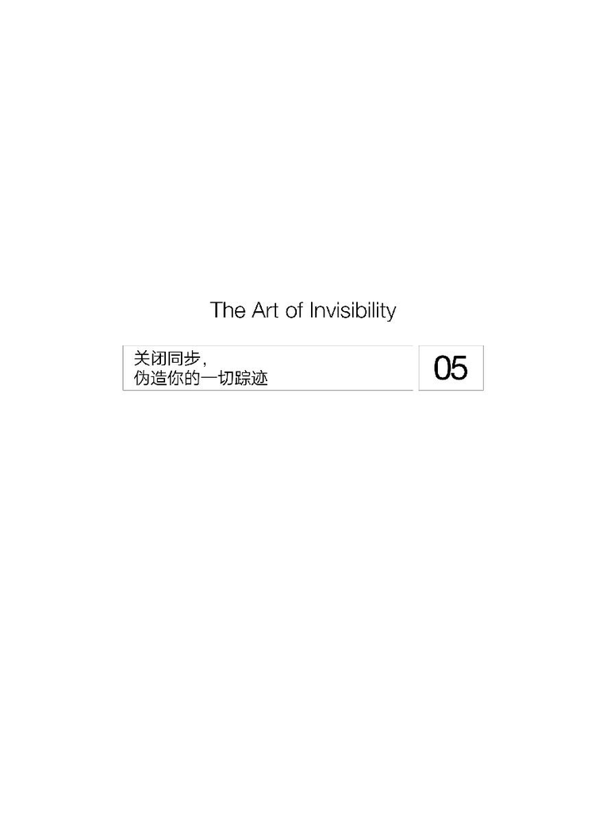

2013年4月，来自马萨诸塞州昆西市、曾是一名出租车司机的22岁的海鲁尔罗桑·马塔诺夫（Khairullozhon Matanov）与两个朋友（实际上是一对兄弟）一起去吃晚餐。他们3人谈论的话题包括那天早些时候在波士顿马拉松终点线附近发生的事件，有人在那里安装了一个装满钉子和火药的高压锅及一个计时器。其导致的爆炸造成3人丧生，超过200人受伤。与马塔诺夫同桌的这对兄弟塔梅尔兰·察尔纳耶夫（Tamerlan Tsarnaev）和焦哈尔·察尔纳耶夫（Dzhokhar Tsarnaev）之后被认定为主要嫌疑人。

尽管马塔诺夫说自己事先对这起爆炸事件并不知情，但据说爆炸发生后不久，他在与执法人员进行会谈时离开了现场，并从自己的笔记本电脑上迅速删除了浏览器历史记录。清除笔记本电脑的浏览器历史记录这个简单的动作，让他遭到了起诉。<sup>1</sup>

删除浏览器历史记录也是对大卫·科纳尔的指控之一，也就是那个入侵了萨拉·佩林的电子邮箱账号的大学生。不过好在当科纳尔清理自己的浏览器、运行磁盘碎片整理程序并删除了他下载的佩林的照片时，他还没有遭到调查。这里要传递的信息是：在美国，你不被允许清除你在自己计算机上做的任何事。检察官想查看你所有的浏览记录。

针对马塔诺夫和科纳尔的诉讼基于一项已存在近15年之久的法律——《上市公司会计改革和投资者保护法案》（参议院的说法）或《公司和审计问责制和责任法案》（众议院的说法），更常用的说法则是2002年的《萨班斯－奥克斯利法案》。这项法律的出现是由安然（Enron）公司的企业管理失当直接导致的。这家天然气公司之后被发现一直在欺骗投资者和美国政府。安然公司一案的调查者发现，调查一开始就有大量数据被删除了，这妨碍了检察机关了解该公司内部发生的确切情况。因此，参议员保罗·萨班斯（Paul Sarbanes）和众议员迈克尔·G.奥克斯利（Michael G. Oxley）发起了一项立法提案，为数据保存增加一系列强制要求，其中之一就是浏览器历史记录必须保留。

据大陪审团的一份起诉书称，马塔诺夫有选择地删除了他的谷歌Chrome浏览器历史记录，而留下了2013年4月15日那一周某几天的活动。他受到了两项正式起诉：“销毁、修改和伪造联邦调查中的记录、文件和实体对象，以及在涉及国际和国内恐怖主义的联邦调查中做出重大虚假、伪造和欺诈性的陈述。”他被判处了30个月的监禁。

在那之前，不管是针对企业还是个人，援引《萨班斯－奥克斯利法案》中浏览器历史记录条款的情况都很罕见。然而，马塔诺夫案确实是一个特殊案件，一个备受瞩目的国家安全案件。所以在那之后，检察官知道了这一条款的潜力，开始愈加频繁地援引它。

### 无痕浏览，你的一切踪迹都将消失

如果你无法防止别人监视你的电子邮件、电话和即时消息，无法合法地删除你的浏览器历史记录，你还能怎么办？也许你可以从一开始就避开对这些历史记录的收集。

Mozilla的火狐、谷歌的Chrome、苹果的Safari、微软的Internet Explorer和Edge等浏览器全都提供了内置的匿名搜索选择，不管你想使用什么设备，传统个人电脑还是移动设备。无论哪种搭配，浏览器都会开启一个新窗口，并且不会记录你在此会话开启期间搜索的内容或浏览的互联网位置。关闭隐私浏览窗口，你访问过的地址的所有痕迹都将从你的个人电脑或其他移动设备上消失。为了隐私，你也要付出一些代价：除非你在隐私浏览时为网站保存了书签，否则你将无法返回；因为没有历史记录——至少你的机器上没有。

使用火狐浏览器上的隐私浏览窗口或Chrome浏览器上的无痕模式，你可能就感觉自己牢不可破了，但你的隐私网站访问请求（比如你的电子邮件）仍然必须经过你的ISP（Internet service provider），即互联网服务提供商，也就是你花钱购买互联网服务或蜂窝服务的公司——而你的提供商可以截取其中传递的任何未加密的信息。如果你访问的网站使用了加密，那么ISP仍能获取访问的元数据，即某天某时你在某地访问了某网站。

不管是在传统的个人电脑上还是在移动设备上，当互联网浏览器连接到一个网站时，它首先会确定是否存在加密，如果存在加密，又是哪一种加密。用于万维网通信的协议被称为http。这个协议是在地址之前指定的，也就是说，一个典型的URL<sup>(16)</sup>可能看起来是这样的：http://www.mitnicksecurity.com，即使其中的“www”在某些情况下是多余的。

当你连接的网站使用了加密时，协议会稍有变化，不再是“http”了，你会看到“https”。所以这个URL就变成了https://www.mitnicksecurity.com。这种https连接更加安全。其中一个原因是它是点对点的，但只有你直接连接到网站本身才会这样。网上还有大量内容分发网络（Content Delivery Network，简称CDN）为它们的客户缓存页面，不管你在世界任何地方，CDN都能实现更快速的分发，因此这就可能出现在你和目标网站之间。

还要记住，如果你登录了你的谷歌、雅虎或微软账号，这些账号可能也会记录你的个人电脑或移动设备上的网络流量——也许会用来构建你的网络行为个人档案，以便这些公司能更好地定位你看到的广告。有一种方法可以避免这种情况，那就是在你用完谷歌、雅虎或微软账号后，记得退出账号，在下次你需要使用它们的时候再重新登录回来。

此外，你的移动设备上还有内置的默认浏览器。这些浏览器都不好，因为它们只是台式电脑或笔记本电脑浏览器的迷你版本，缺乏更稳健版本所具有的一些安全和隐私保护。比如说，iPhone预装了Safari，但你可能需要考虑在应用商店下载移动版的Chrome或火狐，这些浏览器是专为移动环境设计的。更新版本的安卓系统默认预装了Chrome。至少所有的移动浏览器都支持隐私浏览。

如果你使用的是Kindle Fire，那么你无法通过亚马逊下载火狐或Chrome。你就不得不使用一些手动操作，通过亚马逊的Silk浏览器来安装Mozilla的火狐或Chrome。要在Kindle Fire上安装火狐，打开Silk浏览器并访问Mozilla FTP网站，选择“Go”，然后选择以扩展名“.apk”结尾的文件。

### 只相信互联网的安全证书

隐私浏览不会创建临时文件，因此不会在你的笔记本电脑或移动设备上保存你的浏览历史。那某个第三方是否仍能看到你与某个特定网站的交互呢？可以，除非这个交互事先就加密了。为了实现这一目标，电子前线基金会已经打造出一款名叫HTTPS Everywhere的浏览器插件。<sup>2</sup>这款插件可用于传统个人电脑上的火狐和Chrome浏览器以及安卓设备上的火狐浏览器。在本书写作时，它还没有用于iOS的版本。但HTTPS Everywhere能带来一个明显的优势：在连接的前几秒里首先考虑安全，浏览器和网站会协商要使用哪种安全策略。你希望拥有我在上一章讨论过的PFS，但并非所有网站都使用了PFS。而且就算提供了PFS，也并非所有协商都会以此告终。HTTPS Everywhere可以在任何可能的时候都强制使用https，即使没有使用PFS也一样。

安全连接还有另一个标准：每个网站都应该有一个证书，这是你在连接网站时得到的一种第三方的保证，比如，它可以确保你在连接美国银行网站时连接到的是真正的美国银行网站，而不是什么欺诈网站。现代浏览器与这些被称为“证书认证机构”（certificate authority）的第三方合作，保持列表更新。当你访问一个没有得到合适认证的网站时，你的浏览器会发出一个警告，询问你是否足够信任这个网站并且继续访问。你完全可以自己决定是否破例一次。一般而言，除非你了解这个网站，否则绝对不要破例。

另外，互联网上的证书也不止一种，证书还分很多级别。最常见的证书，也是你一直会看到的证书，仅仅用来确认域名属于请求该证书的人，这个使用电子邮件认证即可。操作的人可以是任何人，但这并不重要——这个网站有了一个可以被你的浏览器识别的证书。第二类证书也是一样，即组织证书（organizational certificate）。这意味着该网站与连接到同一域名的其他网站共享自己的证书。换句话说，mitnicksecurity.com上的所有子域名都共享同样的证书。

最严格的证书认证是所谓的扩展认证证书（extended verification certificate）。在所有浏览器上，当一个URL有一个扩展认证证书时，该URL的某些部分会变成绿色（一般是灰色的，就像该URL的其余部分一样）。在地址https://www.mitnicksecurity.com上进行点击，你应该就能看到关于证书及其所有者的额外详情，通常是提供该网站的服务器所在的城市和州。这种物理世界的确认表明，持有该URL的公司是合规的，并且已经得到了一个可信的第三方证书认证机构的确认。

### 关闭或伪造你的位置

你可能会想到移动设备上的浏览器能追踪你的位置，但你会惊讶于传统个人电脑上的浏览器也能做同样的事。确实如此，但这是怎么做到的？

还记得前面我解释了电子邮件元数据包含一路上为你递送电子邮件的所有服务器的IP地址吗？没错，情况一样，来自你的浏览器的IP地址可以确认你使用的ISP，然后就能缩小你可能所在的地理区域的范围。

当你第一次访问特定要求你的位置数据的网站（比如一家天气网站）时，你的浏览器应该会询问你是否要向该网站分享你的位置。这种分享的好处是，该网站可以为你定制自己的列表。比如说，你可能会在washingtonpost.com上看到你所居住的城市中相关事物的广告，而不是华盛顿哥伦比亚特区的广告。

不能确定你过去是否回答过这个浏览器问题？那就试试这个测试页面吧：http://benwerd.com/lab/geo.php。很多测试网站都能显示你的浏览器是否正在报告你的位置，这只是其中一个。如果它确实正在报告而你又想隐身，那就禁用这个功能吧。幸运的是，你可以关闭浏览器位置跟踪。在火狐浏览器中，在地址栏输入“about: config”，滚动到“geo”并将其设定改为“disable”，保存你的修改。在Chrome中，进入“选项>高级>内容设置>位置”，这里有一个“不允许任何网站跟踪我的物理位置”选项，可以禁用Chrome的地理定位。其他浏览器也有类似的配置选项。

你可能也想伪造你的位置——就算只是为了玩。要想在火狐中发送错误的坐标（比如白宫），你可以安装一个名叫Geolocator的浏览器插件。在谷歌Chrome中，可以勾选该插件内置的“模拟地理位置坐标”设置。另外，在Chrome界面中，在Windows系统上点击Ctrl+Shift+I或在Mac上点击Cmd+Option+I可以打开Chrome开发者工具。其中的Console窗口会打开，你可以点击Console右上角的3个竖点，然后选择“More tools>Sensors”。一个传感器窗口将会打开，这让你可以设定你想分享的确切的纬度和经度。你可以使用某个著名地标的位置或选择某海洋之中的一个位置。不管用哪种方式，网站都无法知道你到底在哪里。

当你在上网时，你不仅可以掩盖你的物理位置，还能隐藏你的IP地址。之前我提到过Tor，它可以让你访问的网站看到的IP地址是随机的。但并非所有网站都接受Tor流量。对于那些不接受Tor连接的网站，你可以使用代理。

开放代理（open proxy）是一种位于你和互联网之间的服务器。在第2章中我解释说，代理就像是外语翻译器——你对翻译器说话，然后这个翻译器对说外语的人说话，其中的信息仍然是完全一样的。我使用“代理”这个词描述了某个来自敌对国家、试图假装成友好伙伴国家的人给你发送电子邮件的方式。

你也可以使用代理来访问地理上受限的网站——如果你生活在一个谷歌搜索访问受限的国家。或者也许你需要隐藏自己的身份，以便通过某些网站下载盗版的内容。

但是，代理并非刀枪不入。使用代理时要记住，每个浏览器都必须手动配置，以指向代理服务器。而且就算是最好的代理网站也承认，聪明的Flash或JavaScript技巧仍然可以检测到你的底层IP地址，即你一开始用于连接代理的IP地址。通过阻止或限制浏览器使用Flash或JavaScript，你能限制这些技巧的效果。但防止JavaScript监控你的最好方式是使用HTTPS Everywhere插件。

商业代理服务有很多。一定要阅读你注册的任何服务的隐私政策。你要关注该服务处理运动中的数据的方式，以及它是否遵守执法部门和政府对提供信息的要求。

也有一些免费代理，但为了使用这些服务，你必须应付毫无用处的广告流。我的建议是要小心提防免费代理。在DEF CON<sup>(17)</sup> 20的一场演讲中，我的朋友、安全专家切马·阿隆索（Chema Alonso）做了一个实验，他设置了一个代理，并且想吸引坏人去使用这个代理，所以他在xroxy.com上公告了这个代理的IP地址。几天之后，就有超过5 000人在使用他的免费“匿名”代理了。然而，其中大多数人都在使用它来进行诈骗。

但是另一方面，阿隆索可以使用这个免费代理轻松地向这些坏蛋的浏览器推送恶意软件，然后监视对方的活动。他也确实这么做了。为此他使用了一种名叫BeEF钩子的浏览器利用框架，还使用了终端用户证书许可（EULA），这样人们就不得不接受他做的事——读取经由该代理发送的电子邮件并确定它是否正在处理与犯罪活动有关的流量。这个故事的教训是：免费的东西都是有代价的。

如果你使用的代理使用了https协议，那么执法部门或某些机构就只能看到代理的IP地址，而看不到你在访问的网站上的活动——这个信息是加密的。正如我前面提到的，普通的http互联网流量没有加密，因此你必须使用HTTPS Everywhere（没错，这就是我对大多数浏览器隐身难题给出的答案）。

### 你要确保敏感信息没有自动同步

为了方便，人们常常会在不同的设备上同步他们的浏览器设置。比如说，当你登录了Chrome浏览器或一台Chromebook时，你的书签、标签、历史记录和其他浏览器偏好设置都会通过你的谷歌账号同步。不管是在传统的个人电脑还是移动设备上，这些设置在你每次使用Chrome时都会自动加载。要选择应该将哪些信息同步到你的账号，请访问你的Chrome浏览器的设置页面。谷歌的控制盘给了你完全的控制权限，你可以选择移除哪些信息的同步，要确保敏感信息没有自动同步。Mozilla的火狐也有同步选项。

同步的缺点是，攻击者只需要引诱你登录Chrome或火狐浏览器上的账号就行了，然后你的所有搜索历史都会被加载到他们的设备上。想象一下，如果你的朋友使用了你的电脑并选择登录到浏览器，你朋友的历史记录、书签等都会同步过来。这就意味着现在可以在你的计算机上查看你朋友的浏览历史等各种信息。另外，如果你使用一台公共终端登录了一个同步的浏览器账号而忘记登出，那么下一位用户将能看到你的浏览器书签和历史。如果你登录了谷歌Chrome，那么甚至你的谷歌日历、YouTube和谷歌账号的其他细节都将暴露。如果你必须使用公共终端，一定要注意在离开前退出账号。

同步的另一个缺点是，所有互连的设备都将显示同样的内容。如果你独自生活，那倒还好。但如果你共享了一个iCloud账号，就可能会引发不好的事情。例如，允许孩子使用家庭iPad的家长可能会无意中让他们看到成人内容。<sup>3</sup>

在科罗拉多州丹佛市的一家苹果零售店里，当地一位客户经理艾略特·罗德里格斯（Elliot Rodriguez）使用他已有的iCloud账号注册他的新iPad。他的照片、短信、音乐和视频下载立刻就可以通过这台新iPad获取了。这样的便利节省了他很多时间：他无须为多台设备复制和保存所有的材料了。而且这让他无论选择使用什么设备都能访问这些项目。

之后的某个时候，罗德里格斯把自己的旧iPad交给了8岁的女儿，他认为这样很不错。事实上，让女儿连接到他的设备在短时间内确实是很不错的。罗德里格斯在他的iPad上会注意到女儿偶尔下载到旧iPad上的新应用。有时候他们甚至会分享家庭照片。然后，罗德里格斯去了一趟纽约——他常常去那里出差。

罗德里格斯没有多想就拿出他的iPhone，记录了一些他与纽约情妇的美好瞬间，其中一些相当私密。他的iPhone上的这些图片自动同步到了科罗拉多州家中他女儿的iPad上。而且他女儿当然要问她母亲这个和爸爸在一起的女人是谁。无须多言，罗德里格斯回家时得好好解释一番了。

还有生日礼物的问题。如果你分享了设备或同步的账号，那么你对网站的访问可能会让收礼物的人察觉到自己在生日那天会收到的礼物。或者更糟糕的是，他们可能已经有这东西了。这是共享家庭个人电脑或平板电脑会带来隐私问题的又一个原因。

避免发生这种事的一个方法是设置不同的用户，这在Windows上是一个相对简单的步骤。你自己要保留管理员权限，这样你就可以给系统添加软件以及设置额外的家庭成员，让他们有各自的账号。所有的用户都只能用他们自己的密码登录，并且只能访问自己的内容、自己的浏览器书签及历史记录。

苹果公司允许在其OSX操作系统中进行类似的划分。但是并没有多少人会记得划分他们的iCloud空间。而且有时候，我们自己似乎并没有过错，只是科技背叛了我们。

在和好几个女人谈了几年恋爱之后，洛杉矶的一位电视制片人迪伦·门罗（Dylan Monroe）终于找到了“真爱”，并决定安定下来。他的未婚妻住进了他家，作为他们新生活的一部分，他毫无警觉地让未来的妻子连接到了他的iCloud账号。

当你想组建一个家庭时，将每个人都连接到同一个账号是合情合理的。这样就能让你和你所爱的人分享你们全部的视频、文本和音乐——除非这些东西都是现在的。对于你用数字存储的过去又该怎么办呢？

有时候，使用一个像iCloud这样的自动云备份服务意味着我们会积累很多年的照片、文本和音乐，我们往往会忘记其中一些，就像我们会忘记阁楼上旧盒子里的东西一样。

照片是离我们的记忆最近的东西。是的，你的配偶现在已经看过装满旧信件的鞋盒和几代人的照片了。但数字媒体让你无须太过费力就能获取数以千计的高清照片，这会带来新的问题。忽然之间，门罗的回忆（其中一些确实非常私密）就以照片的形式回来作祟了——这些照片现在出现在了他未婚妻的iPhone和iPad上。

有一些家具必须要搬出房子，因为有其他女人在沙发、桌子或床上和他做过亲密的事。他的未婚妻也拒绝去某些餐厅，因为她看见过其他女人和他一起坐在靠窗那桌或角落雅座的照片。

门罗充满爱意地满足了未婚妻的请求，即使未婚妻还要求他做出最后的牺牲：一旦两人结婚，就卖掉他的房子。所有这些，都是因为他将自己的iPhone和她的iPhone连接到了一起。

### 你今天搜索过的东西在明天可能会变成你的麻烦

云还带来了另一个有趣的问题。即使你删除了你的台式机、笔记本电脑或移动设备上的浏览历史，云中仍然保留了你的搜索历史记录副本。你的历史记录存储在搜索引擎公司的服务器上，很难删除，要做到一开始就不被存储就更难了。这里给出了一个例子，说明了如果隐秘的数据收集没有合适的语境，那么在之后的某个日期和时间，这些数据就可以被轻易地误解。我们很容易就能看到，一些无害的搜索集合在一起可能会带来麻烦。

2013年夏末的一个早晨，在波士顿马拉松爆炸案发生仅仅几周之后，米歇尔·卡塔拉诺（Michele Catalano）的丈夫看见两辆黑色SUV停在了他位于长岛的房子前面。当他出门向这些官员打招呼时，他们要求确认他的身份并请他允许搜查这个房子。尽管米歇尔的丈夫不确定他们为什么要来这里搜查，但因为没什么需要隐瞒的，他就同意让他们进门了。在对房间进行粗略检查过后，这些联邦特工才进入正题。

“这个房子里面有人搜索过关于高压锅的信息吗？”

“这个房子里面有人搜索过关于背包的信息吗？”

显然，这家人通过谷歌进行的网络搜索触发了国土安全局先发制人式的调查。我们不清楚对卡塔拉诺一家调查的确切性质，但可以想见，在波士顿马拉松爆炸案发生后的几周时间里，一些特定的搜索组合在一起可能就预示着潜在的违法活动，因此会被标记出来。在2个小时之内，卡塔拉诺一家的清白就得到了证明，他们没有做任何潜在的不法之事。之后米歇尔将这段经历写在了*Medium*上，但愿它能作为一个警示：你今天搜索过的东西可能会在明天变成你的麻烦。

米歇尔的这篇文章指出，调查者可能无视了她的“我到底能用藜麦做什么”和“A-Rod被停赛了吗”搜索。她说她搜索高压锅不过是想知道如何煮藜麦。而那个关于背包的查询呢？也只是因为她丈夫想要一个背包而已。

至少谷歌这家搜索引擎公司已经打造出一些能让你指定分享的信息内容的隐私工具。比如说，你可以关闭个性化广告跟踪，这样你在搜索巴塔哥尼亚（南美洲一个地区）时就不会看见关于南美洲旅行的广告。你也可以完全关闭你的搜索历史记录，或者在进行网络搜索时不登录Gmail、YouTube等任何谷歌账号。

即使你没有登录你的微软、雅虎或谷歌账号，你的IP地址仍然和你每次的搜索引擎查询绑定在一起。要避免这种一对一匹配，可以使用谷歌代理startpage.com或搜索引擎DuckDuckGo。

DuckDuckGo已经是火狐和Safari的一个默认选项了。和谷歌、雅虎、微软不一样，DuckDuckGo没有任何用户账号的规定，而且该公司表示默认情况下不会记录用户的IP地址。该公司还维护着自己的Tor出口中继<sup>(18)</sup>，也就是说，你无须遭受太多性能滞后就能使用Tor在DuckDuckGo上进行搜索。<sup>4</sup>

因为DuckDuckGo并不追踪用户的使用情况，所以你的搜索结果不会根据你的搜索历史被过滤。大多数人没有意识到，过去在谷歌、雅虎和必应上搜索过的一切会过滤眼前看到的结果。比如说，如果搜索引擎看见你正在搜索与健康问题相关的网站，那么它将开始过滤搜索结果，并将与健康问题相关的结果推到非常靠前的位置。为什么要这么做？因为很少有人会麻烦地查阅搜索结果的第2页。有个互联网笑话说，如果你想知道埋葬尸体的最佳位置，试试第2页的搜索结果。

一些人可能喜欢略过那些看似无关的结果的便利性，但与此同时，这相当于把自己可能对什么感兴趣、对什么不感兴趣的决定权交给了搜索引擎。从很多指标上看，这都是审查。DuckDuckGo确实会倾向有关联的搜索结果，但它的过滤方式是根据主题，而不是你的历史记录。

下一章将讨论网站让你难以对它们隐身的特定方法，以及为了匿名上网你可以怎么做。

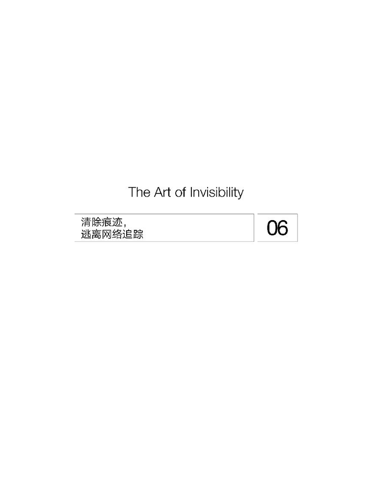

要当心你在互联网上搜索的东西。不只有搜索引擎会跟踪你的上网习惯；你访问的每一个网站都会这么做。而且你可能觉得，相比于暴露给他人的隐私，其中一些网站知道得更多。比如，2015年的一份报告发现，“70%的健康网站的URL都包含了表明特定健康状况、治疗情况和疾病的信息”。<sup>1</sup>

换句话说，如果我在WebMD<sup>(19)</sup>上搜索“athlete’s foot”（足癣），未加密的“足癣”一词就会出现在我的浏览器地址栏里可见的URL中。这就意味着我的浏览器、ISP和网络运营商等各方都能看到我在搜索关于足癣的信息。如果你访问的网站支持https，那么在你的浏览器上启动HTTPS Every where可以加密你真正访问的内容，但无法加密URL。甚至电子前线基金会也指出，https并不是为隐藏你访问网站的身份而设计的。

此外，这项研究还发现，91%的与健康相关的网站都会发出第三方请求。这些调用嵌入在网页本身之中，它们会请求获取微小的图像（你可能会在浏览器页面看到，也可能看不到），这能让其他第三方知道你正在访问某个特定页面。搜索一次“足癣”，当搜索结果加载到你的浏览器中时，就已经有多达20个不同的实体获悉了该消息——从医药公司到Facebook、Pinterest、Twitter和谷歌。现在，它们都知道你搜索过关于足癣的信息了。<sup>2</sup>

第三方会使用这些信息为你提供定向在线广告。另外，如果你登录了这家健康医疗网站，它们可能还会取得你的电子邮箱地址。还好我能帮助你防止这些实体了解更多关于你的信息。

在2015年的一项研究分析过的健康医疗网站中，排名前10位的第三方是谷歌、comScore、Facebook、AppNexus、AddThis、Twitter、Quantcast、亚马逊、Adobe和雅虎。其中一些（comScore、AppNexus和Quantcast）会像谷歌一样检测网络流量。在上面列出的这些第三方中，谷歌、Facebook、Twitter、亚马逊、Adobe和雅虎会为商业目的而监控你的活动。比如，这样它们就可以在你未来的搜索中加载治疗足癣的广告了。

这项研究还提到了第三方Experian和Axiom。它们只是简单的数据仓库，会尽可能地收集关于一个人的更多数据，然后出售这些数据。还记得我之前建议你使用的安全问题和创意答案吗？Experian和Axiom这样的公司往往会收集、提供和使用这些安全问题来构建网络档案。对想为特定类型的人口定向投放产品的营销人员来说，这些档案很有价值。

这是如何办到的？

不管你是手动输入URL还是使用搜索引擎，互联网上的每个网站都有一个主机名（hostname）和一个用数字表示的IP地址（有的网站只有数字地址）。但现在，你基本看不见数字地址了。你的浏览器将其隐藏起来，并且使用了一个域名系统（DNS）将网站的主机名翻译成特定的地址，比如谷歌的地址是https://74.125.224.72/。

DNS就像一个全球性的电话簿，可以实现主机名和你刚才请求的网站服务器的数字地址的交叉参照。在你的浏览器中输入“Google.com”，DNS就会联系地址为https://74.125.224.72的服务器。然后，你就能看到带有一个空白搜索框的熟悉的白色页面，那个搜索框上面可能还有当天的Google Doodle<sup>(20)</sup>。理论上讲，这就是所有网络浏览器的工作方式，实际涉及的过程当然更复杂一点。

在通过数字地址确认了网站之后，你的网络浏览器会收到回传的信息，然后开始“搭建”你所看到的网页。当该页面回到你的浏览器上时，你就能看到那些期待中的元素——你想检索的信息、任何相关的图片以及导航到该网站其他部分的路径。但通常而言，这些元素会向其他网站调用额外的图像或脚本。其中一些、甚至全部脚本都是为跟踪目的而设计的，大多数情况下你并不需要它们。

### 几乎每一种数字技术都会产生元数据

几乎每一种数字技术都会产生元数据，而且毫无疑问，你已经猜到了，浏览器也没有什么不同。如果你访问的网站对你的浏览器发出了查询，那么浏览器就会暴露你的计算机配置等相关信息，比如你使用的浏览器和操作系统的版本，你在浏览器上安装了什么附加组件，以及在你搜索的时候计算机上还运行着其他什么程序（比如Adobe的产品）。这甚至能暴露你的计算机硬件的细节，比如屏幕的分辨率和板载内存的容量。

你可能认为读了这么多内容后，你在网络隐身方面应该已经前进了一大步。你确实进步了，但还有更多工作要做。

花点时间访问一下Panopticlick.com。这个网站是由电子前线基金会设立的，可以基于运行在你的个人电脑或移动设备操作系统上的程序和你可能已经安装的插件，来确定你的浏览器配置和其他人的比起来有多常见或多独特。换句话说，你是否有任何可以用来限制或者防止Panopticlick从你的浏览器直接搜集信息的插件？

Panopticlick.com的结果显示在左边，如果结果中的数字很大（比如说是一个6位数），那就表明你或多或少是独特的，其他计算机与你的浏览器设置相同的概率低于十万分之一。恭喜你。但是，如果你的数字很小（比如说低于3位数），那么你的计算机设置就相当常见，其他计算机与你的浏览器设置相同的概率是几百分之一。也就是说，如果我的目标是你（要向你投放广告或恶意软件），那我就不需要太费劲，因为你的浏览器配置很常见。

你可能会认为常见的配置能帮助你隐身——你是芸芸众生的一部分，你混迹其中。但从技术角度来看，这也为你开启了恶意软件之门。黑客罪犯无须太过劳心劳力。如果一栋房子的门开着，旁边一栋房子的门关着，你觉得窃贼会盗窃哪一家？如果黑客知道你有常见的设置，那么你可能就缺乏可以提升自身安全度的特定保护。

我刚刚从讨论市场营销人员试图跟踪你的网络浏览转向了黑客是否可能使用你的个人信息盗取你身份的情况。这些情况非常不同。营销人员收集信息的目的是创建能让网站赢利的广告。如果没有广告，有的网站就没法继续运营。然而，营销人员、黑客和某些机构都想得到你可能并不想给出的信息，因此，为了便于论述，在涉及侵犯隐私的问题上，它们往往都被放在一起讨论。

要做到不起眼又不会被网络窃听，可以使用虚拟机（virtual machine，简称VM），它可以使Mac OSX等操作系统在你的Windows操作系统上作为访客运行。你可以在你的台式机上安装VMware，并用它安装另一个操作系统。当你做完了你的事情之后，只需要关闭它就行了。这个操作系统以及你在其中所做的一切都将消失。但是你保存的文件仍然会留在你保存的位置。

另外，需要注意的是，营销人员和黑客罪犯之类的人可以通过所谓的单像素图像文件或网络信标（web bug）来了解关于网站访问者的信息。例如一个空白的浏览器弹窗，它是一个放在网页上某处的1×1像素的图像，尽管我们看不见，它也会被将其放置于此的第三方网站调用。其后端服务器会记录试图显示该图像的IP地址。放置在医疗网站上的一个单像素图像可以让制药公司知道你对足癣治疗感兴趣。

我在本章开始时提及的那项2015年的研究发现，近半数的第三方请求都只是打开了不包含任何内容的弹窗。这些“空白”窗口会生成让人无法察觉的第三方主机请求，其目的只有跟踪。你可以通过指示你的浏览器不允许弹窗出现来避免这些问题（而且还能消除那些烦人的广告）。

### 安装插件，让网络无法识别你的第一步

根据这项研究，其余的第三方请求中的1/3都是由小段代码行组成的，即JavaScript文件，这些文件通常只是在网页上执行动画。网站基本上可以通过读取请求这些JavaScript的IP地址来识别接入该网站的计算机。

即使没有单像素图像或空白弹窗，你访问的网站仍然可以跟踪你的网络浏览情况。比如，亚马逊可能知道你访问的前一个网站是医疗网站，所以它会在自己的网站上向你推荐医疗产品。实际上，亚马逊可能在你的浏览器请求中看到了你上次访问的网站。

亚马逊为此要使用第三方的参照网址（referrer）——网页请求中能告诉新网页该请求的来源的文本。比如说，如果我在《连线》杂志的网站上阅读一篇文章，这篇文章中包含一个链接，当我点击这个链接时，新网站将会知道我之前是在浏览Wired.com的一个页面。你可以看到这种第三方跟踪会如何影响你的隐私。

要避免这种情况，你可以总是先进入Google.com，这样你想访问的网站就不知道你之前在浏览什么了。我不觉得第三方的参照网址有什么大不了的，除非你想掩饰你的身份。这又是一个需要在便捷性（直接前往下一个网站）和隐身性（总是从Google.com开始）之间做出权衡的例子。

Mozilla的火狐浏览器可以通过NoScript插件<sup>3</sup>提供应对第三方跟踪的最佳防御。这个附加组件能够有效屏蔽被认为对你的计算机和浏览器有害的一切，即Flash和JavaScript。添加安全插件会改变你的浏览器会话的外观和体验，但你也可以优选和启用其中一些特定的功能或永久性地信任某些网站。

启动NoScript的一个结果是，你访问的网页将不再有广告，当然也没有第三方的参照网址。屏蔽这些东西之后，网页看起来会比不启动NoScript的版本稍微沉闷呆滞一点。但是，如果你想看页面左上角Flash编码的视频，你也可以指定呈现某个元素，同时继续屏蔽其他所有元素。或者如果你感觉可以信任这个网站，就可以临时或永久地允许其页面加载所有元素——在银行网站上你可能就需要这么做。

在这方面，Chrome浏览器有ScriptBlock插件，可以让你防御性地屏蔽一个网页上的脚本使用。对那些可能浏览允许弹出成人娱乐广告的网站的儿童而言，这个插件会很有用。

屏蔽网页上可能有害（而且肯定会侵犯隐私）的元素将保护你的计算机不被广告生成的恶意软件攻陷。比如说，你可能已经注意到了出现在谷歌首页上的广告。事实上，你不应该在你的谷歌首页上看到闪烁的广告。如果你看到了这种广告，那么你的计算机和浏览器可能已经被攻陷了（也许在一段时间之前），因此你可能即将看到包含了木马病毒（比如可以记录你按的每个键的键盘记录器）和其他恶意软件（如果你点击了它们）的第三方广告。即使这些广告不包含恶意软件，广告主也能根据它们得到的点击次数获得收入。被他们欺骗进行点击的人越多，他们赚的钱就越多。

NoScript和ScriptBlock虽好，但并不能屏蔽一切。要得到让浏览器免受威胁的完全保护，你可能需要安装Adblock Plus。唯一的问题是Adblock会记录所有东西：这又是一个会跟踪你的浏览历史的公司，就算你使用了隐私浏览也一样。但是，在这个案例中，得（屏蔽潜在的危险广告）大于失（让他们知道你浏览过哪些网站）。

Ghostery也是一个有用的插件，而且在Chrome和火狐上都可以使用。Ghostery可以识别网站用来跟踪你的活动的所有网络流量跟踪器（DoubleClick和Google AdSense）。和NoScript一样，Ghostery也能让你精准控制你想在每个页面上允许的跟踪器。其网站表示：“屏蔽跟踪器将能阻止它们在你的浏览器中运行，这有助于控制你的行为数据被跟踪的方式。要记住，有的跟踪器可能很有用，比如社交网络feed小部件或基于浏览器的游戏。屏蔽它们可能会给你访问的网站造成意料之外的影响。”也就是说，安装Ghostery之后，有的网站将无法工作。幸运的是，你可以根据网站来选择禁用它。

### 为了获胜，你必须彻底删除最难处理的cookie

除了使用插件让网站无法识别你，你可能也想进一步迷惑潜在的攻击者——通过使用各种为个人目的量身定制的电子邮箱地址。比如说，在第2章中我谈到为了在不被检测的情况下进行通信而创建匿名电子邮箱账号的方式。与之类似，为普通的日常浏览创建多个电子邮箱账号也是一个不错的选择——不是为了隐藏，而是为了让互联网上的第三方对你的兴趣更低。与只拥有一个可识别的地址相比，拥有多个网络个人档案对隐私的影响会小得多。这会让任何人都更难以构建出你的网络档案。

假如说你想在网上购买什么东西。你可能就需要创造一个专门用于购物的电子邮箱地址，还需要将使用这个电子邮箱地址购买的商品都寄送到你指定的邮筒箱，而不是你的家庭地址。<sup>4</sup>此外，你可能还需要使用礼品卡进行购物，也许是一张时不时要进行更新的礼品卡。

通过这种方式，销售你购买的产品的公司将只能获得你的非主要电子邮箱地址、非主要真实地址和基本上用后即抛的礼品卡。如果该公司发生了数据泄露，至少攻击者无法得到你真正的电子邮箱地址、真实地址或信用卡号码。断开与网络购物事件的联系是一种很好的隐私保护措施。

你或许需要为社交网络创建另一个非主要电子邮箱地址。这个地址可能会变成你“公开”的电子邮箱地址，陌生人和不够熟的人可以使用这个地址联系你。同样，这么做的好处是，人们不会知道太多关于你的信息，至少无法直接了解。通过让每一个非主要地址都有一个独特的名字（不管是你真实名字的变体还是另一个完全不同的名字），你还可以进一步保护自己。

如果你选择了前者，一定要小心谨慎。你也许不应该列出一个中间名——或者如果你一直使用的是中间名，那就不应该列出你的名字。即使是JohnQDoe@xyz.com这样看似无害的地址，都能暗示我们你有一个中间名，而且是以字母Q开头的。这就是一个在不必要的时候给出了个人信息的例子。记住，你应该尽力融入背景之中，不要让别人注意到你。

如果你要使用与你的姓名无关的词或短语，就要尽可能使其无法揭示任何信息。如果你的电子邮箱地址是snowboarder@xyz.com，我们可能不知道你的名字，却知道了你的一个爱好。最好选择一些一般属性的东西，比如silverfox@xyz.com。

你当然也需要一个个人电子邮箱地址。你应该只与你亲近的朋友和家人分享这个地址。而且最安全的措施往往也有很大的好处：你会发现，如果不使用你的个人电子邮箱地址进行网络购物，你就不会收到大量的垃圾邮件。

### 避开社交网站中的陷阱

手机也躲不开企业的跟踪。2015年夏季，一位目光敏锐的研究者发现AT&T和Verizon会在每个经过移动浏览器请求的网页中附带额外的代码。这不是我在第3章中谈过的IMSI，而是一种与每个被请求的网页一起发送的独特识别码。这种识别码被称为唯一标识符标头（unique identifier header，简称UIDH），是一种可被广告主用来确定你在网络上的身份的临时序列号。这位研究者在配置了自己的手机，使其记录所有网络流量（不会有太多人做这种事）之后，才发现了这个情况。他注意到Verizon用户有额外的数据消耗，之后他又发现AT&T用户也是一样。<sup>5</sup>

这种附加代码的问题在于用户未被告知相关情况。比如说，如果那些下载了火狐移动应用并使用了插件来增强自己隐私的人使用的是AT&T或Verizon，那他们仍然会被UIDH码跟踪。

在这些UIDH码的帮助下，Verizon和AT&T可以将流量与你的网络请求关联起来，用于构建你的移动网络身份档案以便未来打广告，也可以直接将原始数据卖给其他公司。

AT&T已经停止了这种做法——目前是停止了。Verizon将其做成了一个可选项，让终端用户可以自己设置。<sup>6</sup>注意：如果不选择退出，你就是允许Verizon继续这么干。

即使关闭了JavaScript，网站仍然可能会向你的浏览器传回一个带有数据的文本文件，这个文件被称为http cookie。这个cookie可以存储很长时间。cookie一词是magic cookie的简称，指一些由网站发送并且存储在用户的浏览器中的文本，这些文本可用于对事物（比如购物车里面的商品）进行跟踪或进行用户授权。最早在网络上使用cookie的是网景（Netscape）公司，最初的目的是帮助创建虚拟购物车和电子商务功能。cookie通常存储在传统个人电脑的浏览器上，并且有过期日期，尽管这些日期可能是在几十年之后。

cookie危险吗？不危险——至少它本身并不危险。但是cookie能向第三方提供关于你的账号和特定偏好的信息，例如你在天气网站上最偏爱的城市或在旅行网站上的航空公司偏好。如果已经有了cookie，当你的浏览器下一次连接到该网站时，该网站就会记起你是谁，然后可能会说“你好，朋友”。而如果这是一家电商网站，它可能还记得你最近购买的一些东西。

cookie并不会真正在你的传统个人电脑或移动设备上保存这些信息。就和使用IMSI作为代理的手机一样，cookie包含位于网站后端的数据的代理。当你的浏览器加载了一个附带cookie的网页时，你还会收到专属于你的额外数据。

cookie不仅能保存你个人的网站偏好，还能为它所在的网站提供有价值的跟踪数据。比如，你是一家公司的潜在客户，并且之前为了获取一份白皮书输入过你的电子邮箱地址或其他信息，那么你的浏览器中很可能就会有一个cookie，它可以在后端将关于你的信息与某个客户记录管理（CRM）系统（比如Salesforce或HubSpot）进行匹配。现在，每当你访问该公司的网站时，网站都可以通过cookie识别出你的身份，并且这次访问会被记录在CRM中。

cookie是分开使用的，也就是说，网站A没有必要查阅网站B的cookie的内容。也存在例外，但通常这些信息是分开的，并且相当安全。但从隐私的角度看，cookie的隐身效果并不好。

你只能存取同一个域中的cookie，域是指分配给特定人群的一组资源。广告代理商往往会将多个网站组成更大规模的网络，通过加载一个可以跟踪你在这些网站上的活动的cookie而做到这一点。但一般而言，cookie不能访问其他网站的cookie。现代浏览器为用户提供了控制cookie的方式。如果使用匿名或隐身浏览功能上网，你的浏览器就不会保存你访问特定网站的历史记录，你也不会为该会话获得新的cookie。但如果你有之前访问的cookie，那这个cookie仍然会在隐身模式中使用。另一方面，如果你一直使用常规浏览模式，你可能时不时需要手动移除过去几年累积的一些或全部cookie。

应当指出，移除全部cookie可能并不可取。有选择性地移除那些你不在乎的、只访问了一次的网站的cookie将有助于清除你在互联网上的痕迹。你再次访问该网站时，这些网站将无法认出你。但对一些网站，比如天气网站而言，每次访问都输入邮政编码是很让人厌烦的，而一个简单的cookie可能就足够了。

你可以通过使用附加组件移除cookie，也可以进入浏览器的设置或偏好选项部分，这里通常有删除一个或多个（甚至全部）cookie的选项。你可能也想根据具体案例决定你的cookie的命运。

有些广告商会使用cookie跟踪你在它们投放了广告的网站上停留的时间。有的cookie甚至还能记录你之前的访问情况，即所谓的参照网址。你应当立即删除这些cookie。你可能只会识别出其中一些，因为这些cookie的名称并不包含你所访问的网站的名称。比如，一个参照网站的cookie可能显示为“Ad321”，而非“CNN”。你可能也需要考虑使用cookie清理软件工具来帮你轻松管理cookie，比如piriform.com/ccleaner的工具。

但是，有一些cookie不会受到你在浏览上做的任何决定的影响。这些cookie被称为超级cookie，它们存储在你的计算机上，但在浏览器之外。超级cookie可以在你使用任何浏览器（今天用Chrome，明天用火狐）时存取网站偏好并跟踪数据。你应该删除浏览器中的超级cookie，否则你的传统个人电脑会在你的浏览器再次访问该网站时试图从存储器中重建http cookie。

你可以删除浏览器之外两种特定的超级cookie——来自Adobe的Flash和来自微软的Silverlight。这两个超级cookie都不会过期。而且通常删除它们是安全的。<sup>7</sup>

然后我们就迎来了最难处理的cookie。因创造了在Myspace上快速传播的蠕虫病毒Samy而闻名的萨米·卡姆卡尔（Samy Kamkar）曾经创造出一种非常非常顽固的cookie，他称之为Evercookie。卡姆卡尔将cookie数据保存在Windows操作系统上尽可能多的浏览器存储系统中，从而实现了这种顽固性。只要其中一个存储位置仍然保持原样，Evercookie就会试图将该cookie重新保存在其他每个地方。<sup>8</sup>只是简单地从浏览器的cookie存储缓存中删除Evercookie还不够。就像小孩子玩的打地鼠游戏一样，Evercookie会不断冒出来。为了获胜，你需要将它们从你的机器上完全删除。

考虑一下你的浏览器上可能有多少cookie，再用这个数字乘以你的机器上可能的存储位置的数量，你恐怕会发现这将耗上一个漫长的下午和夜晚。

### 卸载工具栏

想跟踪你的网络活动情况的不只有网站和移动运营商。一个不再只是社交媒体的平台——Facebook已经变得无处不在。你可以在登录Facebook之后使用同一个账号登录或注册各种其他应用。

这种做法有多普遍？有不止一份营销报告发现，88%的美国消费者都曾使用过来自Facebook、Twitter和Google Plus等社交网络的已有数字身份登录其他网站或移动应用。

这种方便有利有弊。这种做法被称为OAuth，即使在不输入密码的情况下，它也能让网络信任你的身份认证协议。一方面，这很快捷：你可以使用已有的社交媒体密码访问新网站；另一方面，这让社交媒体能够收集关于你的信息以便构建营销档案。而且不只是单一一个网站，它知道你使用其登录信息访问过的所有网站和所有品牌。使用OAuth时得到的便利让我们放弃了大量隐私。

Facebook可能是所有社交媒体平台中“黏性”最高的。登出Facebook可能会取消你的浏览器访问Facebook及其网页应用的权限。此外，Facebook还添加了用于监控用户活动的跟踪器，这种跟踪器甚至在你登出之后还会继续工作，能够请求你的地理位置、你访问的网站、你在每个网站的点击情况和你的Facebook用户名等信息。隐私团体已经表达了担忧，称Facebook意图跟踪其用户正在访问的一些网站和应用的信息，以便展示更加个性化的广告。

这里要表达的是，Facebook和谷歌一样，想要关于你的数据。它们可能不会正大光明地索取，而是想方设法得到。如果你将你的Facebook账号和其他服务连接到一起，该平台就会获得你在其他服务或应用上的信息。或许你会使用Facebook来访问你的银行账号——如果你这样做了，它就会知道你使用的是哪家金融机构。若仅使用一种授权认证，则意味着如果有人控制了你的Facebook账号，这个人就能访问与该账号连接的所有其他网站，甚至是你的银行账号。在安全业务中，最好永远不要出现我们所说的单点故障<sup>(21)</sup>。尽管要多花点时间，但仅在你需要时登录Facebook并且单独注册你使用的每个应用是值得的。

此外，Facebook还以“没有行业共识”为由，故意不遵守Internet Explorer发出的“请勿追踪”信号。Facebook的跟踪器都是经典类型：cookie、JavaScript、单像素图像和iframe。这能让目标广告商扫描并读取特定的浏览器cookie和跟踪器，从而在Facebook网站内和网站外提供产品、服务和广告。

幸运的是，有一些浏览器扩展可以屏蔽第三方网站上的Facebook服务，比如用于Chrome的Facebook Disconnect和Adblock Plus的Facebook Privacy List（火狐和Chrome都可用）<sup>9</sup>。最终，这些插件工具的目标是让你能控制你在Facebook和其他任何社交网络上分享的内容，而不是迫使你坐在一个次要位置上，让你使用的服务主宰你的各种事物。

考虑到Facebook对其16.5亿用户的了解程度，这家公司的表现已经相当仁慈了——到目前为止确实如此。<sup>10</sup>它拥有海量数据，但就像谷歌一样，它选择不使用所有数据。但这并不意味着在未来也不会用。

同样寄生在浏览器中，但比cookie更加明显的功能是工具栏。在传统个人电脑浏览器的顶部，你可能会看到标记有“YAHOO”、“MCAFEE”或“ASK”的工具栏，或者可能还有任意数量的其他公司的名字。你很可能不记得工具栏是如何出现在这里的。你从来没用过，也不知道如何移除它。

这样的寄生工具栏会将你的注意力从浏览器自带的原生工具栏上移开。原生的工具栏可以让你选择要使用的默认搜索引擎。寄生的工具栏则会将你引导至它自己的搜索网站，那里可能充满了赞助商的内容。西好莱坞居民加里·莫尔（Gary More）就遇到过这种事，他发现自己的浏览器中出现了Ask.com工具栏，而且根本不清楚如何移除它。莫尔说：“这就像是一个糟糕的房客，不肯走了。”

如果你有两三个工具栏，可能是因为你下载了新软件或不得不更新已有的软件。比如说，你的电脑上安装了Java，Java的提供商甲骨文公司就会自动增添一个工具栏，除非你明确指示它不要这么做。当你点击完成下载或更新流程时，你可能没注意到，有一个微小的勾选框默认你同意安装工具栏。这么做并不是非法的；你确实同意了，即使这只是意味着你没有选择不自动安装它。但这个工具栏也会让另一家公司跟踪你的上网习惯，甚至还会将你的默认搜索引擎改成它自己的服务。

移除工具栏的最佳方法是卸载它，就像在你的传统个人电脑上卸载任何程序一样。但有些最顽固的工具栏可能会要求你下载一个移除工具，而且这个卸载流程往往会留下很多信息，足以让相关的广告代理商重新安装它。

在安装新软件或更新已有的软件时，要注意所有的勾选框。如果你一开始就不同意安装这些工具栏，就能避免很多麻烦。

### 令人毛骨悚然的指纹跟踪

要是你确实使用了隐私浏览且安装了NoScript、HTTPS Everywhere，并且定期删除你的浏览器cookie和无关的工具栏，又会怎样呢？你应该安全了吧？并不是。你在网上仍然可以被跟踪。

网站的编码方式使用了超文本标记语言，即HTML。当前的版本HTML5有很多新功能。其中一些功能昭示着超级cookie Silverlight和Flash的消亡——这是件好事。但HTML5启动了新的跟踪技术，或许是意外吧。

其中一项是canvas指纹跟踪，这是一种让人毛骨悚然的网络跟踪工具。canvas指纹跟踪会使用HTML5 canvas元素来绘制简单图像。就这么简单的一件事，整个过程只需要几分之一秒。图像的这种绘制过程发生在浏览器内部，你没法看到，但发出请求的网站可以看到绘制的结果。

这里的一个思考是：当你的硬件和软件结合，组成浏览器所使用的资源时，它将以特有的方式对图像进行渲染。这些图像可能是一系列各种各样的彩色图像，渲染之后会被转换成一个独特的数字，大致就像密码一样。然后，这个数字会被用于与互联网中其他网站上看到的该数字的先前案例进行匹配。根据匹配结果（该独特数字出现的位置的数量）就可以建立一个你访问过的网站的档案。这个数字就是canvas指纹，它可以在返回任意请求它的特定网站时被用于识别你的浏览器；即使你已经移除了所有cookie或屏蔽了未来的cookie安装也无济于事，因为这使用了HTML5本身内置的元素。

canvas指纹跟踪是一种伴随式的过程；它不需要你点击或做任何事，只需看一个网页，它就会自动完成。幸运的是，有可以屏蔽它的浏览器插件：火狐浏览器有CanvasBlocker，谷歌Chrome有CanvasFingerprintBlock，甚至Tor项目也已经在其浏览器中加入了自己的反canvas技术。

如果你使用了这些插件并完全遵循了我的其他推荐，你可能会认为自己已经免受网络跟踪之苦了。那可就错了。

Drawbridge、Tapad及甲骨文旗下的Crosswise这类公司将网络跟踪向前推进了一步。它们宣称拥有可以跨多台设备跟踪你的兴趣爱好的技术，能够跟踪你仅在手机和平板电脑上访问过的网站。

这类跟踪中有一部分得益于机器学习和模糊逻辑。如果有一台移动设备和一台传统个人电脑使用同一个IP地址连接到了同一个网站，那么它们就很可能属于同一个人。比如说，你在你的手机上搜索特定的服装商品，然后当你回家用你的传统个人电脑上网时，你会发现同一件服装出现在了这家零售商网站的“最近浏览”部分。最好是使用你的传统个人电脑购买这件商品。不同设备之间的匹配越好，意味着越有可能是同一个人在同时使用这两台设备。Drawbridge宣称，公司在2015年就连接了12亿用户的36亿台设备。<sup>11</sup>

谷歌当然在做同样的事，苹果和微软也是一样。安卓用户需要使用谷歌账号。苹果设备要用Apple ID。不管用户拥有的是智能手机还是笔记本电脑，每台设备所生成的网络流量都会与特定用户关联在一起。另外，最新的微软操作系统也需要微软账号才能下载应用或使用该公司的云服务存储照片和文档。

这些收集行为有很大的区别。谷歌、苹果和微软允许你禁用部分或所有数据收集行为，以及删除之前收集的数据。Drawbridge、Crosswise和Tapad则没有把禁用和删除过程做得那么明显，或者可能干脆就没有。

### 信用卡，随时会暴露你的身份

尽管使用代理服务或Tor能让你在接入互联网时方便地隐藏你的真实位置，但这种隐藏可能会带来一些有趣的问题，甚至让你反受其害，因为有时候，网络跟踪是合情合理的——尤其是当信用卡公司试图打击欺诈时。比如，就在爱德华·斯诺登进入公众视野的前几天，他想创建一个支持网络权益的网站。但在使用他的信用卡向托管公司支付注册费时，他遇到了麻烦。

那时候他使用的仍然是他的真实姓名、真实电子邮箱地址和个人信用卡——就在他成为揭秘者之前不久。他也使用了Tor，而这有时候会触发信用卡公司的欺诈报警，因为它们验证你的身份时，会发现无法将你提供的信息和它们文件中已有的信息进行匹配。比如，你的信用卡账号说你住在纽约，那为什么你的Tor出口节点却说你住在德国？这样的地理位置差异往往会将试图购买的行为标记成可能的滥用行为，并使你遭到额外的审查。

信用卡公司肯定会在网上跟踪我们。它们知道我们全部的购买情况，知道我们订阅了什么，知道我们什么时候离开了国家。它们也知道我们什么时候使用一台新机器来进行网购。

据电子前线基金会的迈卡·李称，当斯诺登在他位于中国香港地区的酒店房间里与劳拉·珀特阿斯和《卫报》记者格伦·格林沃尔德（Glenn Greenwald）讨论美国政府的秘密时，他也正与洛杉矶一家互联网提供商DreamHost的客户支持部门联络。显然，斯诺登向DreamHost解释说，他在国外而且不信任当地的互联网服务，所以使用了Tor。最终，DreamHost接受了他通过Tor的信用卡付款。

有一种方法可以避免使用Tor时的这种麻烦，即安装torrec配置文件，以使用位于你本国的出口节点。这应该能让信用卡公司满意。一方面，一直使用同一个出口节点可能最终会暴露你的身份。另一方面，有一些严肃的猜测表明，某些机构可能控制着一些出口节点，所以使用不同的出口节点是合理的。

另一种不留痕迹地进行支付的方式是使用比特币，这是一种虚拟货币。和大多数货币一样，它的价值会随着人们对它的信心而产生波动。

比特币是一种算法，让人们可以创造他们自己的货币——用比特币的术语来说是挖矿。但如果那么简单，每个人都会去做这种事了。其实并不简单，这个过程需要密集的计算，所以需要很长时间才能创造一个比特币。因此，在任何一天里，比特币的数量都是有限的，而这是消费者信心之外又一个影响其价值的因素。

每个比特币都有一个加密的签名，可用于确认它是原始的且独特的。使用这个加密签名进行的交易可以追溯到这个币，但得到这个币的方法可能很曲折：比如，你需要设置一个坚如磐石的匿名电子邮箱地址，然后通过Tor网络使用这个电子邮箱地址设置一个匿名的比特币钱包。

你可以与人面对面地购买比特币，也可以使用预付费礼品卡在网上匿名购买，或者找一个没有监控摄像头的比特币ATM购买。选择使用哪种购买方式时，你需要考虑所有的风险，这取决于哪些监控因素有可能暴露你的真实身份。购买之后，你可以将这些比特币放入所谓的混桶（tumbler）中。混桶会从你、我和随机选择的其他人那里各取一些比特币，将它们混合在一起。你能留下这些币减去混合手续费之后的部分。不过在与其他人的币混合后，每个币的加密签名可能不一样了。这样就在一定程度上实现了该系统的匿名化。

一旦有了比特币，你又该如何保存它们？因为并不存在什么比特币银行，而且比特币并不是实体货币，所以你需要匿名设置一个比特币钱包，后面的章节会详细描述设置的方法。

现在，你已经购买并保存了比特币，你又该如何使用它？交易能让你投资比特币并将其换成其他货币（比如美元），或在亚马逊等网站上购买商品。假设你已经有一个比特币了，价值618美元。如果你需要花大约80美元进行一次购买，那么在交易之后，你将会保留原来价值的特定比例，具体比例取决于汇率。

交易将在被称为区块链的公共账本中进行验证，并通过IP地址进行确认。但正如我们所见，IP地址可以更改或伪造。而且尽管商家已经开始接受比特币，但通常由商家支付的服务费被转移给了买家。此外，和信用卡不一样的是，比特币不允许退款或赔付。

虽然过去出现过很多种虚拟货币的尝试，但比特币现在已经变成了互联网上标准的匿名货币。这是一个正在进行中的项目，确实如此，但这也是寻求隐私的人应该考虑的选择。

你现在可能感觉已经隐身了——使用Tor隐藏了你的IP地址；使用PGP和Signal加密了你的电子邮件和文本消息。但我还没谈到太多硬件方面的内容——这既可以用于在互联网上找到你，也可以用于在互联网上隐藏你。

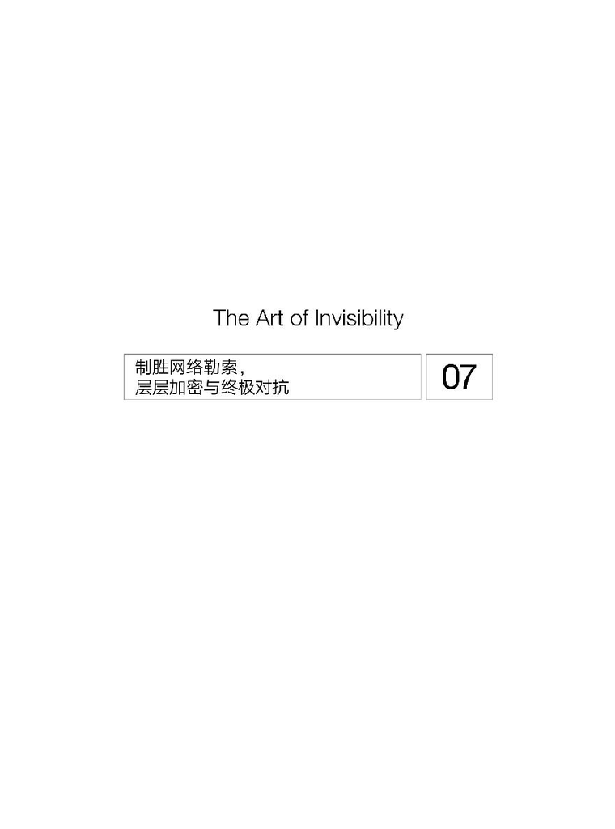

在明尼苏达州布莱恩市城郊的一栋房子里，噩梦从网上开始蔓延，当联邦特工冲进这栋房子时，噩梦才结束。这些特工有一个与儿童色情内容下载相关的IP地址，甚至还有一个针对时任副总统乔·拜登的死亡威胁。通过联系与该IP地址相关的互联网服务提供商，特工们得到了该用户的实际地址。当人们都还在使用有线方式来连接调制解调器或路由器时，这种追踪是非常有效的。那时候，每个IP地址都可以追溯到特定的实体机器。

但今天，大多数人都使用家里的Wi-Fi。无线网络让房子里的每个人都能拿着移动设备到处走动，同时还能保持互联网连接。如果你不够小心，你的邻居也可以接入同一个信号。在这个案件中，联邦特工在明尼苏达州冲进了错误的房子。他们真正该进的其实是隔壁那家。

2010年，巴里·文森特·阿尔多夫（Barry Vincent Ardolf）对黑客入侵、身份盗用、持有儿童色情内容和威胁时任副总统拜登的指控供认不讳。法庭记录表明，阿尔多夫与他邻居的纠纷始于这位不愿透露姓名的律师邻居向警方提交了一份报告，说阿尔多夫“不当地触摸和亲吻了”律师家的小孩的嘴。

然后，阿尔多夫使用邻居家的无线路由器的IP地址，以受害者的名义注册了雅虎和Myspace账号。阿尔多夫通过这些虚假账号进行了一些活动，想要让这位律师难堪，并给他带来法律上的麻烦。

现在，很多ISP都为它们的家庭路由器提供了内置的无线网络功能。Comcast等一些ISP还创建了一种次级的开放Wi-Fi服务，而且用户对此的控制很有限。你也许可以修改一些设置，比如关闭它。你应该对此有所警惕，因为停在你房子前面的一辆车上的人可能正在使用你的免费无线。虽然你不需要支付额外的费用，但如果第二个信号正在重度使用，你可能会注意到Wi-Fi速度略有下降。如果你觉得永远不需要为访客提供你的家庭免费互联网接入，你可以禁用Comcast的Xfinity Home Hotspot。

尽管内置的无线网络便于用户设置和运行新服务，但这些宽带路由器往往配置不正确，而当它们不安全时，就可能产生问题。比如，不安全的无线接入可能会提供一个进入你家庭的数字入口点，就像阿尔多夫做的那样。尽管入侵者的目标可能不是你的数字文件，但他们也会给你制造麻烦。

阿尔多夫并不是计算机天才。他在法庭上承认自己并不知道他邻居的路由器所用的WEP（有线等效保密）加密与WPA（Wi-Fi保护接入）加密之间的区别——后者要安全得多。他只是很愤怒。这是你应该花点时间想想自家无线网络安全性的另一个原因。你永远不知道一个愤怒的邻居会在什么时候使用你家的网络对付你。

如果确实有人在你家的网络上做了坏事，路由器的所有者也能得到一些保护。据电子前线基金会称，因为被告成功表明是其他人使用了他们的无线网络下载电影，所以联邦法官驳回了版权所有者发起的BitTorrent诉讼。<sup>1</sup>电子前线基金会指出，一个IP地址并不是一个真实的人，也就是说，无线网络用户可能无须为其他人使用他们的无线网络所做的事情负责。

尽管计算机取证能证明自家Wi-Fi被用于犯罪的无辜者的清白（正如上面这个明尼苏达州律师的案子一样），但为什么要忍受这种事呢？

### 你该怎样修改路由器的名称以及更新固件呢

不管你使用的是基于电话的拨号调制解调器，还是基于电缆的ASM（任意源组播）路由器（思科和贝尔金等公司提供这种设备），这些设备都有共同的软件和配置问题。

首先，最重要的是要下载最新的固件（安装在硬件设备中的软件）。你可以访问路由器的配置页面或制造商的网站，搜索你的特定产品及型号的更新来获取最新的固件。要尽可能频繁地更新。更新路由器固件的一种简单方法是，每年都买一个新路由器。这样做成本会很高，但能确保你有最新、最好的固件。其次，要更新你的路由器配置设置，不要使用默认设置。

所以路由器名称中有什么信息？多得超乎你的想象。ISP提供的路由器和你从百思买（Best Buy）购买的路由器之间的共同之处是命名。所有无线路由器都会默认广播所谓的服务集标识符（SSID）。<sup>2</sup> SSID通常是路由器的名称和型号，比如“Linksys WRT54GL”。如果你查看一下你所在区域的可用无线连接，就知道我在说什么了。

向世界广播默认的SSID也许可以掩盖该Wi-Fi信号实际上来自某个特定家庭的事实，但也会让街上的人知道你拥有的路由器的确切品牌和型号。为什么这很糟糕？因为某个人可能会知道这款产品的漏洞，从而可以利用这些漏洞。

所以，该如何修改路由器的名称并更新固件呢？

访问路由器很容易，用你的互联网浏览器就可以。如果你没有你的浏览器的指示说明，可以访问一个网络URL列表，它会告诉你应该在浏览器窗口中输入什么内容，来直接连接你家庭网络上的路由器。<sup>3</sup>在输入了本地URL之后（你只是在与路由器通信，而不是整个互联网），你会看到一个登录页面。所以用于登录的用户名和密码是什么？

实际上，互联网上也发布了一个默认登录信息的列表。<sup>4</sup>在上述Linksys的案例中，用户名为空，密码是“admin”。无须多言，一旦进入了路由器的配置页面，你应该立即更改其默认密码，遵循我之前讲到的有关创建独特强密码的方法或使用密码管理器。

记得将这个密码保存在你的密码管理器中或写下来，因为你可能不需要经常访问你的路由器。说真的，你到底多久才会访问一次你的路由器配置页面？你会忘记这个密码吗？不要担心。路由器上有一个实体重置按钮，可以重置默认设置。但是，在执行实体重置或强制重置时，你不得不再次执行我下面将解释的各种配置设置。所以，每当你使用了不同于默认设置的路由器配置时，就应该把这些路由器设置写下来或截屏并打印出来。当你需要重新配置你的路由器时，这些截屏会很有价值。

我建议你将“Linksys WRT54GL”更改为无害的名称，比如“HP Inkjet”，这样陌生人就没法明显地看出这个Wi-Fi信号可能来自哪栋房子了。我常常使用普通的名称，比如我住的公寓大楼的名字，甚至我邻居的名字。

另外，你也可以选择完全隐藏你的SSID。这样其他人就没法在无线网络连接列表中轻易看到它了。

### 三大无线加密的安全方法

当你进入基本的浏览器配置设置时，需要考虑几种类型的无线安全。在默认情况下，它们通常没有被启用。而且并非所有无线加密都是平等创建的，也不是所有设备都支持这种形式。

最基本的无线加密形式是有线等效保密（WEP），这毫无用处。即使你在选项中看到了，也完全不用考虑它。WEP多年前就已被破解，因此我不再推荐。只有老式的路由器和设备仍有这样的遗留选项。相反，你应该选择一个更新、更强的加密标准，比如Wi-Fi保护接入，即WPA。WPA2还要更加安全<sup>(22)</sup>。

在路由器上启用加密意味着连接其上的设备也需要有相匹配的加密设置。大多数新设备都能自动感知所用的加密类型，但较旧的型号仍需要你手动设置要使用的加密级别。尽可能总是使用最高级别。你的安全程度取决于你最薄弱的环节，所以在为最旧的设备使用加密方面，要确保使用它的最大极限。

启用WPA2意味着当你连接到你的笔记本电脑或移动设备时，你也需要将它们设置成WPA2。不过一些新的操作系统可以自动识别加密的类型。你的手机或笔记本电脑上的现代操作系统都能识别你所在区域的可用Wi-Fi。你的SSID广播（现在是“HP Inkjet”）应该会出现在列表的前几位。可用Wi-Fi连接列表中的挂锁图标（通常与每个连接的强度指示重叠）表示这些Wi-Fi连接需要密码（你的Wi-Fi现在应该有一个挂锁）。

在可用连接列表中点击你自己的SSID。你应该会看到输入密码的提示——确保你的密码至少有15个字符，或者使用密码管理器来创建一个复杂密码。为了连接你的有密码保护的Wi-Fi，你至少需要在每台设备上输入一次该密码。所以密码管理器可能无法适用于所有情况，有时候，你不得不记住这个复杂密码并自己手动输入。包括你的智能电冰箱和数字电视在内的每台设备，都将使用你在设置路由器加密时所选择的那个路由器密码。你需要为每一台接入你的家或办公室Wi-Fi的设备输入一次密码，但只要你没有修改你的家庭网络密码或获取一台新设备，就不必再次输入密码。

还可以更进一步，仅允许你指定的设备连接到Wi-Fi。这被称为白名单。通过这种方式，你可以让一些设备有访问权限，并禁止其他设备接入（设置黑名单）。这需要你输入你设备的媒体访问控制地址，即MAC地址。这也意味着下一次升级你的手机时，你必须将其加入你路由器的MAC地址中，才能顺利连接。<sup>5</sup>每台设备的MAC地址都不同；事实上，前三组字符（8位组）是制造商代码，后三组是产品特有的。这样路由器就会拒绝任何硬件MAC未曾保存过的设备。话虽如此，一款名叫aircrack-ng的黑客工具可以显示当前连接用户的授权MAC地址，攻击者可以伪造这个MAC地址来连接这个无线路由器。和隐藏的无线SSID一样，绕过MAC地址过滤是一件轻而易举的事情。

查找你设备的MAC地址是相当简单的。在Windows中，点击开始按钮，输入“CMD”，点击“命令提示符”，并在右单书名号后面输入“IPCONFIG”。机器会返回一长串数据列表，MAC地址应该就位列其中，它由12个十六进制的字符组成，每两个字符间都有冒号分隔。苹果产品的查看方法甚至更加简单。点击苹果图标，选择“系统偏好设置”，进入“网络”，然后点击左面板上的网络设备并进入“高级>硬件”，就能看到MAC地址了。对一些老式的苹果产品而言，查看流程是：苹果图标>系统偏好设置>网络>内置以太网。在iPhone上，你可以选择设置>通用>关于本机，然后查看“无线局域网地址”，找到MAC地址。对于安卓手机，则应进入设置>关于手机>状态信息，查看“Wi-Fi MAC地址”。根据你使用的设备和型号，这些指示可能会有所不同。

有了这些12位数字的MAC地址，现在你只需要告诉路由器只允许这些设备连接并屏蔽其他设备即可。这种做法也有缺陷。如果有客人想要连接你的家庭网络，你就必须决定是把自己的一台设备和相应的密码给他，还是直接重新进入路由器配置页面关闭MAC地址过滤。另外，有时候你可能也需要修改设备的MAC地址；如果不把它改回来，就无法连接到你家里和工作场所中限定了MAC的Wi-Fi网络。幸运的是，在大多数情况下，重启这些设备就能恢复原来的MAC地址。

### 马上关闭路由器上的WPS功能

为了能轻松地将任意新设备连接到家庭路由器，旨在传播Wi-Fi技术应用的组织Wi-Fi联盟（Wi-Fi Alliance）创造了Wi-Fi保护设置（Wi-Fi protected setup，简称WPS）。他们宣称WPS可以让任何人都能在家里或办公室安全地设置移动设备。但实际上，这并不是很安全。

WPS的形式通常是路由器上一个可以按压的按钮。其他方法包括使用PIN码和近场通信（NFC）。简单来说，只要你激活了WPS功能，它就能与你家里或办公室的任何新设备通信，还会自动同步这些设备以使用你的Wi-Fi网络。

听起来很赞。但是，如果路由器放在“公开”的地方，比如你的客厅，那么任何人都可以触控它的WPS按钮并加入你的家庭网络。

即使没有实际接触，网络攻击者也可以通过暴力破解猜测你的WPS PIN码。这可能需要几个小时的时间，但仍然是一种可行的攻击方法。为了保护自己免受这种攻击的侵害，你应该马上关闭路由器上的WPS功能。

另外，还有一种被称为Pixie Dust的WPS攻击方法。这是一种离线攻击，而且只对几家芯片制造商的产品有效，其中包括雷凌（Ralink）、瑞昱（Realtek）和博通（Broadcom）。Pixie Dust可以帮助黑客获取无线路由器的密码。这种攻击大体上非常简单，而且能在几秒钟或几小时内获取设备的访问权限，具体时长取决于所选择的或生成的WPS PIN码的复杂度。<sup>6</sup>比如说，Reaver就是这样一个程序，可以在几小时内破解一台启用了WPS的路由器。

一般而言，应该关闭WPS。你仍然可以通过输入你设置的用于接入的密码，来将每台新的移动设备连接到你的网络。

### 在你的网络摄像头上贴上胶带

所以，你已经通过使用加密和强密码让其他人没法使用你的家庭无线路由器网络了。这是否就意味着没人能进入你的家庭网络，甚至窥探你家庭内部的数字生活了？并非完全如此。

高中二年级的布莱克·罗宾斯（Blake Robbins）在费城城郊的一所学校上学，当他被叫到校长办公室时，他完全不知道自己会因在家里的“不当行为”而受到训斥。费城外的这个劳尔·梅里恩学区曾经向包括罗宾斯在内的每名高中生发放了新的MacBook，以便他们做课程作业。但这个学区没有告诉学生的是：电脑中那个为了在设备丢失时恢复设备的软件也可以用来监控全部2 300名学生的行为，同时学生们也处在这个笔记本电脑的网络摄像头的视野之中。

罗宾斯被指控的罪行是什么？过量服药。罗宾斯家的律师则一直坚称这个男孩只是在做家庭作业时吃了一种名叫Mike and Ike的糖。

这难道有问题吗？

学区坚持说，盗窃跟踪软件只有在笔记本电脑被盗之后才会被激活。盗窃跟踪软件的工作方式是：当某人使用该软件报告他的笔记本电脑被盗之后，校方可以登录一个网站，查看来自被盗笔记本电脑网络摄像头的图像并播放其音频文件。然后，学校的管理员就可以监控这台笔记本电脑并按需拍照。这样就可以进行定位并找回该设备，还能识别出作案者。但是在这个案例中，据称学校官员私自打开了这项功能，来窥视学生在家里的状况。

罗宾斯的学校发的MacBook的网络摄像头记录了数百张照片，包括这个男孩在自己床上睡觉的照片。其他学生的遭遇更加糟糕。根据法庭证词，该校甚至有学生的更多照片，其中有几人还是“部分裸露的”。如果罗宾斯没有因为自己在家里做的事而被训斥，那些学生可能仍然不会注意到这件事。

之前一个名叫贾利勒·哈桑（Jalil Hasan）的学生也被拍摄了近500张照片，他的电脑还被截屏了400张图片——记录了他的网络活动情况和他访问过的网站。罗宾斯和哈桑一起起诉了该学区。罗宾斯得到了17.5万美元的赔偿，哈桑得到了1万美元的赔偿<sup>7</sup>。该学区拿出了近50万美元为学校的行为买单，并且不得不通过其保险公司支付了大约140万美元的赔偿。

恶意软件可以很轻松地在用户不知情的情况下激活传统个人电脑上的网络摄像头和麦克风，在移动设备上也是如此。这个案例是一个蓄意的行为，但是通常情况并非如此。在你笔记本电脑的网络摄像头上贴一张胶带是一个快速的补救措施，你打算再次使用它时再取下胶带。

### 揭示普通软件的骗局

2014年秋季，伦敦《电讯报》（*Telegraph*）的记者索菲·柯蒂斯（Sophie Curtis）在一封电子邮件中收到了一个领英（LinkedIn）的连接请求，这封邮件似乎来自同一家报社的某个同事。这是柯蒂斯常常收到的那一类邮件，而且因为职业礼节，她没有多想就接受了来自同事的请求。几周以后，她收到了一封似乎是来自某个匿名举报机构的电子邮件，说要发布一些敏感文件。作为一位报告过匿名者和维基解密等组织的记者，柯蒂斯之前也收到过类似的邮件，而且她对这个请求很好奇。邮件的附件看起来像是一个标准文件，所以柯蒂斯点击并打开了它。

她马上就意识到出问题了。每个Windows系统副本都自带的安全软件Windows Defender开始在她的桌面上发出警告，这些警告不断地堆积在屏幕上。

和现在的很多人一样，柯蒂斯被欺骗点击了一个她认为是普通文件的附件。这个附件假装有她想看到的信息，却自动下载和解压了一系列其他文件，从而让远程攻击者可以完全控制她的电脑。这个恶意软件甚至用柯蒂斯自己的网络摄像头给她拍了一张照片。在这张照片中，柯蒂斯一脸沮丧，因为她正试图理解自己的电脑究竟是如何被人控制的。

实际上，柯蒂斯完全知道是谁接管了她的计算机。为了一次实验，几个月前她曾聘请了一位渗透测试员，也就是我这样的人。个人和公司会聘请专业的黑客来尝试攻破其计算机网络，从而确定自己需要在哪些地方加强防御。在柯蒂斯的案例中，这个过程持续了几个月。

在这种工作的一开始，我总是会尽可能多地获取有关客户的信息。我会花时间了解他的生活和上网习惯，会在Twitter、Facebook，甚至领英上追踪该客户的公开帖子。索菲·柯蒂斯的渗透测试员也是这样做的。在她所有的电子邮件中，有一条精心构思的消息——她的渗透测试员发送的第一封邮件。这位渗透测试员知道她是一位记者，而且她对之前陌生人发送的电子邮件申请持开放态度。在第一个案例中，柯蒂斯后来写道，背景信息不够，不足以让她有兴趣采访一个特定的人并写出报道。但这位黑客和他安全公司的同事所做的大量调查研究让她印象深刻。

柯蒂斯说：“他们可以使用Twitter找到我的工作电子邮箱地址、我近期去过的一些地方，以及我与其他记者参加的定期社交晚会的名字。根据我发到Twitter上的一张照片中的背景，他们可以发现我曾经用过什么手机，还能发现我的未婚夫常常抽手工卷烟（这是张老照片）以及他喜欢骑自行车。”这些细节中的任何一条都可以用来写另一封电子邮件。

DEF CON 2016大会上出现了一个基于人工智能的新型工具，该工具可以分析目标的推文，然后基于他们的个人兴趣构建鱼叉式网络钓鱼<sup>(23)</sup>电子邮件。所以，要谨慎点击推文中的链接。

实际上，会泄露你永远不打算公开分享的关键个人信息的往往是一些小事物：在这里或那里发布的奇怪评论、一张照片中你身后架子上的小摆设、你曾经参加过的一个营地活动的T恤衫。也许你认为这些一次性的瞬间是无害的，但攻击者了解到关于你的细节越多，就越容易诱使你打开电子邮件附件并接管你的网络世界。

柯蒂斯指出，这个渗透测试团队到此就结束了他们的攻击。但如果他们是真正的犯罪型黑客，这样的胡作非为可能还会持续一段时间，也许坏人会控制她的社交媒体账号、她在《电讯报》的办公室网络甚至她的财务账号。而且他们在做这种事的时候很可能不会让柯蒂斯知晓她的计算机受到了侵害；大多数攻击者并不会立即触发Windows Defender或反病毒软件。有的攻击者会在得手后一直持续数月或数年时间，其间用户丝毫不会察觉到自己被攻击了。不只是你的笔记本电脑会受害，电子邮件触发的攻击也可以作用于越狱的iPhone或安卓设备。

### 与隐私一样，欺诈难以被量化

尽管谷歌和其他电子邮件服务提供商会扫描你的信息，以防止恶意软件和网络色情内容的传播，也是为了收集广告营销数据，但它们并不一定会扫描欺诈行为。正如我前面说过的，和隐私一样，欺诈是难以量化的，标准因人而异。而且我们并不总是能识别出欺诈，即使它就发生在我们眼前。

在柯蒂斯收到的假领英电子邮件正文中有一张1×1像素的图片，这是一个微小的图像点，肉眼看不见，就像我之前说的那些放在网站上用于跟踪你的网络行为的单像素图像。当这个微小的点被调用时，它会告诉一个远程位置的跟踪服务器它在世界的什么位置、你什么时候打开了这封电子邮件、它在屏幕上停留了多长时间，以及你在什么设备上打开了它。它也能说明你是否保存、转发或删除了该消息。此外，如果这个渗透测试团队所使用的场景是真实的，攻击者还可能在其中插入一个链接，通过这个链接，柯蒂斯就会访问一个虚假的领英页面。这个页面的各个地方都与真实的领英页面很像，只是它被托管在不同的服务器上，也许还在另一个国家。

广告商可以使用这种网络信标收集关于收件人的信息，并因此得到档案。攻击者则可将其用于获取他们设计下次攻击所需的技术细节，其中会包含一种进入你的计算机的方法。比如，你运行的是一个旧版本的浏览器，它可能就有一些可被利用的漏洞。

所以，柯蒂斯从渗透测试员那里收到的第二封电子邮件包含了一个附件，这个文档可以利用用于打开该文件的软件（比如Adobe Acrobat）中的漏洞。在我们谈论恶意软件时，大多数人都会想到21世纪初的计算机病毒，那时候，一封受感染的电子邮件就可以将更多受感染的电子邮件传播给联系人列表中的每个人。现在，这种大规模感染攻击已经不太常见了，部分原因是电子邮件软件本身的改变。相反，现今最危险的恶意软件已经精妙得多，而且它们针对的目标往往是个人。索菲·柯蒂斯遇到的就是这种情况。这些渗透测试员使用了一种特殊形式的网络钓鱼，即鱼叉式网络钓鱼，这是专门针对特定个人设计的。

网络钓鱼是一种试图获取用户名、密码和信用卡或银行信息等高度机密信息的犯罪欺诈过程。它一直以来都被用于对付CFO（首席财务官），因为所谓的“CEO”已经授权转账，所以CFO们被骗了很多钱。通常网络钓鱼电子邮件或文本消息中都包含一个执行项，比如点击链接或打开附件。在柯蒂斯的案例中，钓鱼的目的是在她的电脑上植入恶意软件，以便证明这种事可以多么轻松地做到。

极光行动（Operation Aurora）可能是最著名的网络钓鱼案例之一了。在这一事件中，谷歌公司的一位中国雇员收到了一封网络钓鱼电子邮件。其目的是感染谷歌在中国的机器，从而进入其位于加利福尼亚州芒廷维尤的全球总部的内网。这件事让攻击者与谷歌搜索引擎源代码的接近到了非常危险的程度。谷歌并不是唯一的受害者。Adobe等公司也报告了类似的入侵。<sup>8</sup>

每当我们收到一个领英或Facebook请求时，我们的戒备就会下降。这可能是因为我们信任这些网站，也信任它们的电子邮件消息。但是，正如我们所见，任何人都可以制造出看起来很真实的消息。在面对真人时，我们通常可以察觉某人戴了假胡须、假发，或伪装声音说话，进化了很多个世纪的本能帮助我们无须思考就能看穿欺骗行为。这些直觉却不适用于网络，至少不适用于我们大多数人。索菲·柯蒂斯是一名记者，她的工作就是保持好奇与怀疑、跟踪线索和检查事实。她本可以检查《电讯报》的员工名单，了解领英上的这个人究竟是谁，从而知晓这封电子邮件可能是伪造的。但她没有这么做。而且事实上，大多数人都一样没有警觉。

正在进行网络钓鱼的攻击者会有一些你的信息，但不会有你全部的个人信息——他将已有的那点信息用作自己的诱饵。比如说，网络钓鱼者可能会向你发送一封包含你的信用卡号后4位数字的电子邮件以取得信任，然后继续询问更多信息。有时候，这4位数字是不正确的，钓鱼者会要求你在回复中进行必要的更正。不要做这种事。简而言之，不要和网络钓鱼者纠缠。一般来说，不要回应任何想要你个人信息的请求，即使它们看起来值得信任；而应该用另一个电子邮箱（如果你有其地址）或短信（如果你有其手机号码）联系该请求者。

更让人担忧的网络钓鱼攻击是欺骗目标执行某个动作，这个动作会直接利用他的计算机，从而让攻击者获得完全的控制权。这就是我在社会工程方面的工作。另一种流行的攻击方式是凭证采集（credential harvesting），其目标是获取一个人的用户名和密码，但鱼叉式网络钓鱼的真正危险是取得目标计算机系统或网络的权限。

### 如何对付勒索软件的狡诈敌人

假设你确实与某个钓鱼者进行了交互，并失去了你被感染的个人电脑或移动设备上的所有数据——你全部的个人照片和私人文件，又该怎么办呢？阿林娜·西蒙娜（Alina Simone）的母亲就遇到了这种事。西蒙娜在《纽约时报》的文章中描述道，她的母亲（不擅长科技）好像在对付一个正在使用所谓的勒索软件的狡诈敌人。

2014年，一阵针对个人和企业的敲诈勒索恶意软件浪潮席卷了互联网。Cryptowall就是其中一例，它会加密你的整个硬盘，将你锁在你的每个文件之外。只有在向攻击者付钱之后，你才会得到解锁自己文件的密钥。除非你有完整的备份，否则在支付赎金之前，你的传统个人电脑或安卓设备上的内容都将无法访问读取。

不想付钱？显示在屏幕上的勒索信声称，解锁这些文件的密钥将在一定时间内被销毁。信中往往还会包含一个倒计时时钟。如果你不付钱，截止时间有时候还会延长，但价格也会随着每次拖延而上涨。

一般而言，你不应该点击电子邮件附件（除非你在谷歌Quick View或谷歌文档中打开它们）。不过Cryptowall还有其他传播方式，比如网站上的横幅广告。只要查看一个带有受感染的横幅广告的页面，就可以让你的传统个人电脑被感染，这被称为偷渡式（drive-by）攻击，因为你实际上并没有点击这个广告。这就是你浏览器中安装的Adblock Plus等去广告插件的真正用武之地。

2015年上半年，FBI的互联网犯罪投诉中心（Internet Crime Complaint Center，简称IC3）记录了近1 000例Cryptowall 3.0案件，损失共计约1 800万美元。这个数字包含了支付的赎金、IT部门和维修点的成本以及损失的生产力。在某些案例中，被加密的文件包含个人身份识别信息，比如社会保障号码，这些信息可能会让攻击者引发数据泄露，从而造成进一步的损失。

尽管解锁这些文件的密钥总是可以用500～1 000美元的固定费用购买，但那些遭遇感染事件的人往往会尝试其他方法来移除勒索软件，比如自己攻破加密。西蒙娜的母亲就这样尝试过。当她最后给女儿打电话时，时间已经所剩无几了。

几乎所有想要攻破这种勒索软件加密的人都失败了。这种加密非常强，破解它需要非常强大的计算机和很多时间，这超出了大多数人的能力范围。所以受害者往往只能付钱。据西蒙娜称，为了解锁72 000份尸检报告、证人证词和犯罪现场照片等文件，田纳西州迪克森县警长办公室在2014年11月支付了一次Cryptowall赎金。

这些黑客通常会要求用比特币支付，这就意味着很多普通人将难以支付。我在前面提到过，比特币是一种去中心化的、点对点的虚拟货币，而大多数人并没有可以取款的比特币钱包。

在《纽约时报》那篇文章中，西蒙娜提醒读者永远不要支付赎金，但她最后还是付了。事实上，FBI现在也建议那些计算机被勒索软件感染的人直接付钱。负责FBI在波士顿的网络和反间谍项目的助理高级特工约瑟夫·博纳沃隆塔（Joseph Bonavolonta）说：“说实话，我们通常建议人们支付赎金了事。即使是FBI也没能力破解这些勒索软件制造者使用的超安全的加密。”他还补充道，因为很多人都已经付钱给攻击者了，所以过去几年来，这项开支一直保持得相当稳定。之后，FBI公开表示，选择付钱还是联系其他安全专家完全由公司自己决定。

西蒙娜的母亲这辈子从来没购买过一个应用，在快到截止时间时联系女儿只是因为她需要知道如何用这种虚拟货币付款。西蒙娜说她在曼哈顿找到了一个比特币ATM，在经历了一次软件故障并且给该ATM的所有者打过服务电话之后，她终于完成了支付。按照那天的汇率，每个比特币的价格比500美元稍多一点。

不管这些勒索者接受的是比特币支付还是现金支付，他们都是匿名的，尽管从技术上讲，这两种支付方式都有办法跟踪。使用比特币进行的网络交易可以关联到买家，但并不容易。问题是，谁会花时间和精力来追踪这些罪犯呢？

在下一章中，我将描述当你通过公共Wi-Fi连接互联网时，会发生什么。从隐私的角度来看，你想得到公共Wi-Fi的匿名性，但与此同时，你也需要小心防备。

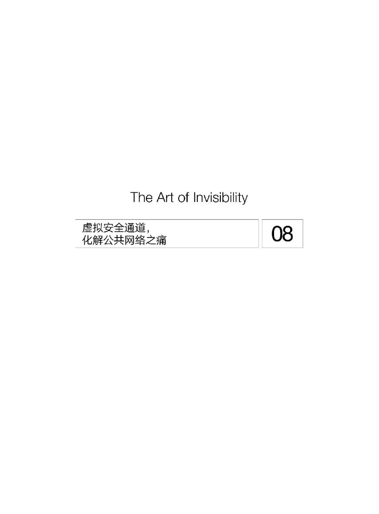

在电话还是新奇事物的时候，它们是通过实体的线缆连接到家里的，可能被放在墙上的某个柜格里。拉两条电话线被认为是社会地位的象征。与之类似，公共电话亭是为隐私打造的。甚至酒店大堂里一排排付费电话之间也配置了隔音设施，提供着一种保护隐私的错觉。

有了移动电话之后，隐私似乎已经荡然无存了。我们走在街上，常常会听到人们大声地分享着自己的个人故事，甚至更糟糕——在所有路人的听力范围内背诵自己的信号卡号码。在这种开放和共享的文化氛围中，我们需要仔细考量我们愿意奉献给世界的信息。

有时候世界会倾听。我只是随口一说，请别见怪。

假设你喜欢在你家附近街角的咖啡馆工作，我有时候也会这样。那里有免费的Wi-Fi。应该没什么问题，对吧？我不想这样说，但真的有问题。公共Wi-Fi在创建的时候可没考虑网上银行或电子商务。它只是为了方便，却极其不安全。这种不安全性并不总是技术方面的。其中一些问题源于你，我希望也会终止于你。<sup>1</sup>

你要如何知道自己用的是公共Wi-Fi？其中一个表现是，在连接到这个无线接入点时，它不会要求你输入密码。为了演示你在公共Wi-Fi上的隐身程度，反病毒软件公司F-Secure的研究者创建了他们自己的接入点，即热点（hotspot）。他们在伦敦市中心的两个不同位置（一家咖啡馆和一个公共空间）进行了实验。结果让人瞠目结舌。

研究者在伦敦繁华区域的一家咖啡馆里进行了第一个实验。当顾客们考虑选择可用的网络时，他们会看到F-Secure那信号强又免费的热点。这些研究者还在用户浏览器上出现的横幅广告中陈述了相关条款和条件。也许你之前在咖啡馆里连接Wi-Fi时，也看到过类似的横幅广告，其中规定了你在使用其服务时可以和不可以做的事。但在这个实验中，免费Wi-Fi的使用条款要求用户交出自己的第一个孩子或心爱的宠物。有6个人同意了这些条款。说实在的，大多数人并不会花时间阅读这些精细的印刷体文本——他们只想使用另一边的不管什么东西。当然，你至少也应该大致瞥一眼这些条款。在这个案例中，F-Secure的研究者之后澄清，说他们并不想对这些孩子或宠物做任何事。

真正的问题在于，当你在使用公共Wi-Fi时，第三方能看到什么。你在家里时，你的无线连接应该使用了WPA2加密。这意味着就算有人在窥探，他也没法看到你在网上做什么。但当你使用的是咖啡馆或机场公开的公共Wi-Fi时，目的地流量就完全暴露了。

你可能还是会问，这难道有什么问题吗？好吧，首先，你不知道连接另一端的究竟是谁。在这个案例中，F-Secure研究团队很有道德地销毁了他们收集到的数据。但犯罪分子恐怕不会这么做，他们会把你的电子邮箱地址卖给向你发送垃圾邮件的公司，这些邮件要么是想让你购买什么东西，要么就是想用恶意软件感染你的个人电脑。另外，犯罪分子还可能使用你的未加密电子邮件中的细节来设计鱼叉式网络钓鱼攻击。

### 藏在阴影里的家伙，他的真实目的是什么

在第二个实验中，该团队在靠近议会大厦、工党和保守党总部以及国家打击犯罪局的位置设置了一个热点。在30分钟内就有250人连接到了这个实验性的免费热点。其中大多数都是这些人使用的设备自动连接的。换句话说，这些用户并不是有意识地选择该网络，而是设备帮他们选的。

这种做法有一些问题。先让我们看看你的移动设备自动加入某个Wi-Fi网络的方式和原因是什么。

传统个人电脑和所有的移动设备都能记住最近几个Wi-Fi连接，不管是公共的还是私人的。这样很好，因为可以为你省去重复验证常用Wi-Fi接入点的麻烦——比如你家里或办公室的Wi-Fi。但如果你走进一家从没去过的全新的咖啡馆，却突然发现自己有这里的无线连接，这可能就是一件坏事。为什么是坏事呢？因为你连接到的可能并不是这家咖啡馆的无线网络，而是其他什么东西。

也许你的移动设备检测到了一个与你的最近连接列表中某个配置匹配的接入点。在设备自动连接到一个你之前从未去过的地方的Wi-Fi时，你可能会在其便捷性之外觉察到什么，但你也可能已经玩起射击游戏了，除此之外不愿多想。

自动Wi-Fi连接是如何生效的？正如我在前一章解释过的那样，也许你家里有Comcast Internet服务，如果你真的在用这个服务，你的服务套餐中可能还会有一个免费的未加密的公开SSID，名为Xfinity。你启用了Wi-Fi的设备过去也许曾经和它连接过一次。但你怎么知道这不是某个在角落的桌旁使用笔记本电脑的家伙广播的名叫Xfinity的假冒无线接入点呢？

让我们假设你已经连接到了角落阴影里那个家伙的网络，而不是咖啡馆的无线网络。你仍然能上网冲浪。所以你可能会继续玩你的游戏。但是，你发送的和通过互联网接收的每一个未加密的数据包，都可以被这个阴影中的人通过他那假冒的笔记本电脑无线网络接入点看到。

如果他已经不嫌麻烦地设置了一个假的无线网络接入点，那么他就有可能使用Wireshark等免费应用来获取这些数据包。我的渗透测试工作就会用到这个应用。它让我能够看到我周围发生的网络活动。我可以看到人们连接的网站的IP地址，以及他们在这些网站的访问时间。如果该连接没有加密，基本上就意味着向公众开放了，那么截取其流量就是合法的。比如说，作为一位IT主管，我需要知道我的网络上所进行的活动。

也许阴影中的那个家伙只是在偷窥，看看你访问了什么地方，而没有干涉你的流量。或者，也许他正在主动干预你的互联网流量。做这种事有很多目的。

也许那个人会将你的连接重新定向到一个代理，该代理会在你的浏览器中植入一个JavaScript键盘记录器，这样当你访问亚马逊的网站时，它就能获取你在与该网站交互期间所按下的键。也许那个人是靠猎取你的凭证（用户名和密码）赚钱。要记住，你的信用卡可能关联了亚马逊和其他零售商。

我在发表主题演讲时会进行一个演示，借以说明一旦受害者连接到我伪造的接入点，我可以如何在他访问网站时截取其用户名和密码。由于处在受害者和网站之间的交互中间，所以我可以注入JavaScript并让他的屏幕上弹出虚假的Adobe更新，如果这个伪造的更新安装成功，受害者的计算机就会感染恶意软件。这种事的目的通常都是诱骗你安装虚假更新，从而获取你的计算机的控制权。

角落桌旁那个家伙影响互联网流量的做法被称为中间人攻击（man-in-the-middle attack）。攻击者会在你和真实网站之间代理你的数据包，也会在这个过程中截取或注入数据。

现在你知道，你可能会无意中连接到某个可疑的Wi-Fi接入点了，那么又该如何防止这种事发生呢？对于笔记本电脑，设备会经历一个搜索首选无线网络的过程，然后才会与它连接。但有的笔记本电脑和移动设备会自动选择所要加入的网络。这种设计的目的是让你能尽量没有痛苦地将你的移动设备从一个地方带到另一个地方。但前面也提到了，这种便利带有缺陷。

据苹果公司的说法，其产品会按以下偏好顺序自动连接到网络：

• 该设备最近加入过的私有网络；

• 另一个私有网络；

• 热点网络。

幸运的是，笔记本电脑提供了删除过时的Wi-Fi连接的方法——比如去年夏天某次出差时你连接的酒店Wi-Fi。在Windows笔记本电脑上，你可以在连接之前取消网络名称旁边的“自动连接”勾选。或者进入控制面板>网络和共享中心，点击网络名称，点击“无线属性”，然后取消“当此网络在范围内时自动连接”的勾选。在Mac上，进入系统偏好设置，进入网络，在左侧面板上选中Wi-Fi，点击“高级”，然后取消“记住这台电脑所加入的网络”的勾选。你也可以单独移除某些网络，只需选中网络名称，然后按下面的减号按钮即可。

安卓和iOS设备也有删除之前使用过的Wi-Fi连接的说明。在iPhone或iPod上，进入你的设置，选择“Wi-Fi”，点击网络名称旁的“i”图标，然后选择“忽略此网络”。在安卓手机上，你可以进入你的设置，选择“Wi-Fi”，长按网络名称，然后选择“忘记网络”。

老实说，如果你真有什么需要远离自己家去做的敏感事情，那我推荐你使用自己移动设备上的蜂窝连接，而不是用机场或咖啡馆的无线网络。你可以使用USB、蓝牙或Wi-Fi共享你的个人移动设备的网络。如果你使用Wi-Fi，那就要确保你像之前提到的那样配置了WPA2加密。另一个选择是购买一个便携式热点，以便旅行途中使用。要注意，这并不能让你隐身，但比起使用公共Wi-Fi，这是一个更好的替代选择。如果你不想让移动运营商知道你的隐私，那么我建议你使用HTTPS Everywhere或安全文件传输协议（Secure File Transfer Protocol，简称SFTP）。Mac上的Transmit应用和Windows上的Tunnelier应用都支持SFTP。

### 关闭Wi-Fi

假设你只是想查看天气，不做任何财务事务或个人事务，那么在你的家庭网络之外使用自己的个人笔记本电脑应该是安全的，对吧？同样，还是不安全。你仍然需要采取一些预防措施。

首先，关闭Wi-Fi。我是说真的。很多人把笔记本电脑上的Wi-Fi一直开着，即使在不需要Wi-Fi时也是这样。根据爱德华·斯诺登公布的文件，加拿大通信安全局（CSEC）仅凭设备的MAC地址就能识别经过加拿大机场的旅客的身份。任何正在搜索无线设备发送的探测请求的计算机都可以读到这些信息。即使你没有连接，你的MAC地址仍然可被获取。所以如果你不需要用Wi-Fi，就关闭它。正如我们所见，便捷与隐私和安全往往不可兼得。

### 每次连接无线网络，你都要修改MAC地址

到目前为止，我们一直都绕过了一个重要问题——你的MAC地址。不管你使用的是什么设备，这个地址都是独一无二的。而且它不是永久性的，你可以修改它。

让我举一个例子。在第2章中，我谈到了使用PGP加密你的电子邮件。但如果你不想这么麻烦或者收件人没有PGP公钥让你使用，又该怎么办？还有另一种通过电子邮件交换信息的隐秘方法：使用共享电子邮箱账号的草稿文件夹。

这就是美国中央情报局前局长大卫·彼得雷乌斯（David Petraeus）将军与他的情妇宝拉·布罗德维尔（Paula Broadwell）交换信息的方式。在彼得雷乌斯结束了这段关系并注意到某人曾给他的一位朋友发送过威胁电子邮件之后，这个丑闻才得以公开。FBI调查时不仅发现这些威胁来自布罗德维尔，还发现她一直在给彼得雷乌斯写浪漫的留言。

有趣的是，布罗德维尔和彼得雷乌斯之间的信息并没有传输，而是留在这个“匿名”电子邮箱账号的草稿文件夹中。在这种情况下，电子邮件不会为了到达收件人的邮箱而通过其他服务器，被拦截的可能性就会更小。就算某人确实在之后取得了该账号的权限，只要你之前先删除了电子邮件并清空了垃圾箱，就不会留下证据。

布罗德维尔也使用了一台专门的计算机来登录这个“匿名”电子邮箱账号。她没有用自己家的IP地址连接这个电子邮箱网站。那样就太明显了。相反，她在各种酒店里进行她的通信。

尽管布罗德维尔为了隐藏自己费了很多心思，但她仍然没有隐身。据《纽约时报》报道：“因为这个发送者的账号是匿名注册的，所以调查者必须使用取证技术来识别是谁写了这些电子邮件，其中包括检查同一个计算机地址访问过其他哪些电子邮箱账号。”

谷歌、雅虎和微软等电子邮箱提供商会将登录记录保留一年以上的时间，这些记录会揭示用户登录时所用的IP地址。比如说，你使用的是星巴克的一个公共Wi-Fi，那么你的IP地址就会显示这家店的实际位置。美国目前允许执法机构从电子邮件服务提供商那里获取这些登录记录，而且只需一张传票就能实现。

这意味着，调查者能取得联系过该特定电子邮箱账号的每个IP地址的实际位置，然后将布罗德维尔的设备的MAC地址与这些位置的路由器连接日志相匹配。<sup>2</sup>

凭借FBI背后绝对的权威性（这很重要，因为那时候彼得雷乌斯是CIA局长），特工可以搜索每家酒店的全部路由器日志文件，查看布罗德维尔的MAC地址什么时候在酒店日志文件中出现过。此外，他们还能说明在所涉及的日期中，布罗德维尔是一位登记的客人。这些调查者明确指出，她在登录这些电子邮箱账号期间并没有真正发送出一封电子邮件。

当你连接到一个无线网络时，你的MAC地址会被该无线网络设备自动记录下来。MAC地址就像是分配给你的网卡的一个序列号。为了隐身，你在连接到任何无线网络之前，都需要将你的MAC地址改成一个与你无关的地址。

为了保持隐身，每次连接无线网络时，你都应该修改MAC地址，这样你的互联网会话才不会轻易地与你关联起来。在这个过程中，也不要访问你的任何个人网络账号，这很重要，因为那样做可能会损害你的匿名性。

在各种操作系统（Windows、Mac OS、Linux，甚至安卓和iOS）上，修改MAC地址的操作过程各有不同。<sup>3</sup>每当你要连接一个公共（或私有）网络时，记得修改你的MAC地址。重启之后，原来的MAC地址就会恢复。

### 公共计算机“不留痕迹”的规则

假设你没有自己的笔记本电脑，因而别无选择，只能使用公共计算机终端，可能是在咖啡馆、图书馆甚至高档酒店的商务中心里。这时，你可以怎样保护自己呢？

我在露营的时候看到过“不留痕迹”的规则——也就是说，露营地应该看起来和我刚到达时一样。使用公共个人电脑终端时也是同理。在你离开后，没人会知道你用过它。

在贸易展会上尤其如此。我有一年参加过年度的消费电子展（Consumer Electronics Show，简称CES），看到那里安置了一排公共个人电脑，让参会者可以在展厅里走动时检查自己的电子邮件。我甚至在旧金山每年举办的具有安全意识的美国信息安全大会（RSA大会）上看到过这种配置。使用在公共场合排成一列的普通终端是很糟糕的，原因有很多：

• 首先，这些是租用的计算机，从一个活动到另一个活动反复使用。它们可能会有清理，重新安装了操作系统，但也可能并不是这样。

• 其次，它们往往运行着管理员权限，这意味着参会者可以安装任何他想安装的软件，包括恶意软件，比如可以保存你的用户名和密码信息的键盘记录器。在安全业务中，我们常谈到“最小特权”原则，即机器仅向用户提供完成工作所需的最小权限。而一些公共终端默认设置了系统管理员权限，登录这样的公共终端有违最小特权原则，只会增加你使用的设备曾感染过恶意软件的风险。

一般而言，我建议永远不要信任公共个人电脑终端。应该假定上一个使用它的人安装了恶意软件——不管是有意还是无意的。如果你在一台公共终端上登录了Gmail，而且那台公共终端上有一个键盘记录器，那么一些远程的第三方就会获得你的用户名和密码。如果你登录了你的银行——别想了，千万不要登录银行。记住，你应该在接入的每个网站上启用双因素认证即2FA，这样，拿到了你的用户名和密码的攻击者也没法冒充你。即使某人确实知道了你的用户名和密码，那么2FA也可以极大地降低你的账号遭侵入的可能性。

在CES和RSA等关于计算机的大会上使用公共柜台设备的人数让我很是惊讶。给你一个底线：如果你在贸易展会上，那就使用你的启用了蜂窝网络的手机或平板电脑、你的个人热点，或者等回到你的房间再上网。

如果你不得不在远离你家或办公室的地方使用互联网，那就使用你的智能手机。如果你必须使用一台公共终端，千万不要登录任何个人账号，网页邮箱也不行。比如，你在查找一家餐厅，那就只访问那些网站，不要请求身份认证。如果你时不时就要使用公共终端，那就设置一个仅在公共终端上使用的电子邮箱账号，而且只有当你在路上时，才能从你的正规账号向这个“可抛弃”的地址转发电子邮件。一旦你回到家，就停止转发。这样会使从那个电子邮箱地址可以找到的信息最小化。

接下来，要确保你在公共终端上访问的网站的URL中有https。如果你没看到https（或者确实看见了，但怀疑有人将其放到那里是为了让你有错误的安全感），那你可能就应该仔细考虑是否要用这台公共终端访问敏感信息。

假设你用的是一个合规的https URL。如果你在登录页面上，要找到写着“保持登录状态”的勾选框，然后取消勾选。原因很清楚：这不是你的个人电脑。其他人也会使用它。如果保持登录状态，你就在这台机器上创造了一个cookie。你不希望使用该终端的下一个人看到你的电子邮件，或者用你的地址发送电子邮件，对吧？

如上所述，也不要在公共终端上登录财务或医疗网站。如果你确实需要登录一个网站（不管是Gmail还是其他网站），一定要在用完之后登出，甚至还要考虑在你自己的计算机或移动设备上修改你的密码，以保证安全。在家里时，你可能并不总会登出你的账号，但在使用别人的计算机时，你必须要一直这么做。

在发送完你的电子邮件（或看完你想看的什么内容）并登出之后，要尽量清除浏览器历史记录，这样，下一个人就没法知道你访问过哪里。另外，如果可能，你也要删除所有cookie。还要确保你没在该计算机上下载个人文件。如果你下载了，记得在下载之后从该计算机上删除这些文件或下载文件夹。

但不幸的是，光是删除这些文件还不够。接下来，你还需要清空垃圾箱。这样也还是没有完全从该计算机上删除这些文件——如果我想，我可以在你离开后检索到这些文件。幸好大多数人没有做这种事的能力，通常删除文件和清空垃圾箱就足够了。

为了在公共终端上隐身，所有这些步骤都是必要的。

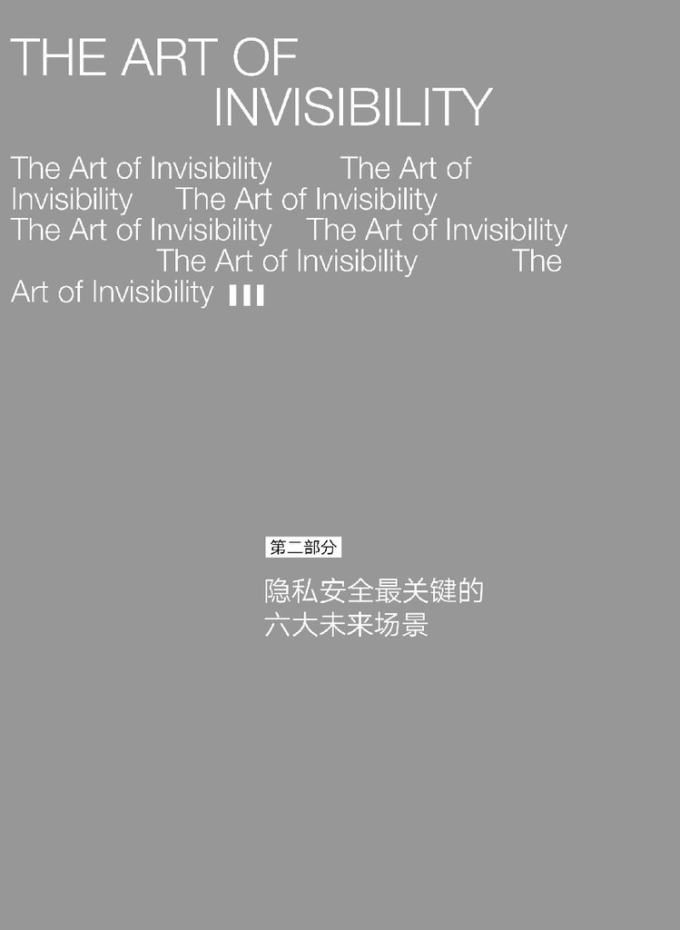

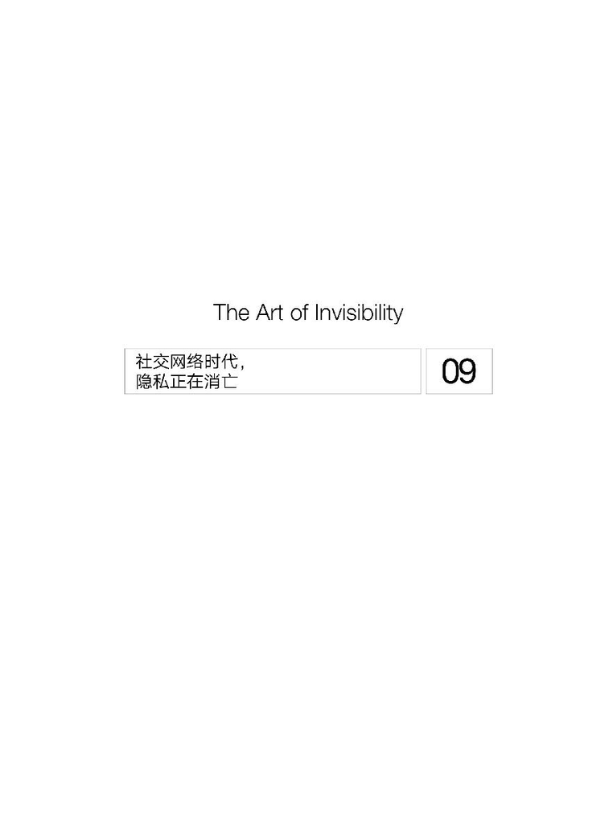

在前反病毒软件创造者约翰·迈克菲（John McAfee）在伯利兹逃避当局追捕期间，他创立了一个博客。听我一言：如果你想避开侦查，完全消失，那就不要开什么博客。其中的一个原因是，你肯定会犯错误。

迈克菲是个聪明人。早些年他在硅谷进行了反病毒方面的开创性研究，获得了一笔钱。然后他卖掉了公司，卖掉了他在美国的所有资产，在2008年到2012年的4年时间里都生活在伯利兹一处远离海岸的私人房产中。在那段时间快要结束时，伯利兹政府对他进行了不间断的监控，夺走了他的财产，还指控他组织了一支私人军队并参与贩毒。

迈克菲否认自己做过这些事。他声称自己在对抗这个岛上的毒枭。比如，他说他向一个小打小闹的大麻贩子提供了一台平板电视机，条件是这个毒贩要停止贩毒。而且人们都知道，迈克菲会截住那些他怀疑载着毒贩的车辆。<sup>1</sup>

迈克菲确实有一个药物实验室，但并不一定是用于制造娱乐性毒品。他声称自己正在创造一种新一代的“有益的”药物。因此，他越来越怀疑他家外面那些汽车里的白人男子都是葛兰素史克（GlaxoSmithKline）等制药公司派出的间谍。他还声称当地警方的袭击是由这些制药公司策划的。

有几个配枪的男人和11只狗在保卫迈克菲的财产。他南边相邻两栋房子的邻居格雷格·福尔（Greg Faull）经常向当局投诉，说这些狗在深夜吠叫。之后，在2012年11月的一个夜晚，迈克菲的一些狗被毒死了。那一周的晚些时候，福尔遭人枪杀，死在自己的家中，脸朝下，趴在一摊血里。

伯利兹当局在调查中自然认为迈克菲是犯罪嫌疑人。迈克菲在自己的博客中说，当他听到管家说警方想找他问话时，就跑出去躲了起来。他变成了逃犯。但最终让执法部门找到他的并不是他的博客，而是一张照片。这张照片甚至都不是他自己的。

安全圈内以“Simple Nomad”之名为人所知的马克·洛夫莱斯（Mark Loveless）是一位安全研究者。他注意到，*Vice*杂志在2012年12月初在Twitter上发布了一张迈克菲的照片。在这张照片上，*Vice*的编辑与迈克菲一起站在一个热带地区——也许是伯利兹，也许是其他地方。

洛夫莱斯知道，数字照片会捕获大量有关照片拍摄的时间、地点和方式的信息，他想看看这张照片可能包含哪些数字信息。数字照片是以所谓的可交换图像文件（exchangeable image file，简称EXIF）数据形式存储的。这是照片元数据，其中包含了各种寻常的细节，比如图像的色彩饱和度，这些细节可以让屏幕或打印机准确地重现照片。如果相机具备这种功能，其中还会包含照片拍摄位置的准确经纬度。

显然，迈克菲与这位*Vice*杂志编辑的合照是用iPhone 4S的相机拍摄的。一些手机出厂的时候就已经自动启用了定位。洛夫莱斯很幸运：这张在网上发布的照片中包含了约翰·迈克菲的准确地理位置，由此可以发现，他实际上就在伯利兹的邻国危地马拉。

在后续一篇博客中，迈克菲说他伪造了这些数据，但这看起来不太可能。之后，他又说原本就打算公布自己的位置——很可能是他偷懒才没有这么做。

长话短说，危地马拉警方拘留了迈克菲，并且不让他离开该国。然后迈克菲生了病，住进了医院，最后才被允许返回美国。

格雷格·福尔的谋杀案仍然悬而未决。迈克菲现在住在田纳西州，他在2015年还决定竞选美国总统，主张美国政府应采取对网络更加友好的政策。他现在发的博客基本不如以往那么多了。